# DeepDive_Cancellation

Majd Ben Khalifa, David Pardo

September 24, 2018

## Preface

### Structure

The report is roughly devided into two parts: The first part provides information about cancellations on the level of partners, agents, verticals & vertical combinations, cities and months. It helps identifying abnormal cancellation behavior of individual subjects. The second part approximates the importance of the different cancellation drivers through a logistic regression and a decision tree model.

The report can be rerun at any time to reproduce this html output with an updated dataset.

### Dataset

The underlying dataset of this analysis contains all valid opportunities that were closed after 01.01.2017 and have been either cancelled or completed. At the creation of this document the dataset consists of 5900 opportunities.

## Descriptive Analysis

In this part the dataset is being filtered and aggregated in different ways according to the subject. The resulting browsable table serves for identifying subjects with high cancellation rates or other remarkable behavior.

The information shown for each subject include:

- n_jobs = number of opportunities
- c_rate_prebook_num = prebook cancellation rate by number of opportunities
- c_rate_prebook_nmv = prebook cancellation rate by nmv
- c_rate_postbook_num = prebook cancellation rate by number of opportunities
- c_rate_postbook_nmv = postbook cancellation rate by nmv
- c_rate_total_num = overall cancellation rate by number of opportunities
- c_rate_total_nmv = overall cancellation rate by nmv
- cr_no_partner_found_num = percent of cancelled opps where cancellation reason is “no partner found” by number of opportunities
- cr_partner_problem_num = percent of cancelled opps where cancellation reason has been a problem with the partner by number of opportunities
- med_invoiced_margin_nmv = median margin by booked nmv
- med_invoiced_margin = median margin by invoice net amount
- med_invoiced_nmv = median opportunity size by nmv
- med_invoiced_nmv = median opportunity size by net invoiced
- med_close_to_cancel = median days from last close to cancellation
- d14_cancels = percent of cancelled opps with cancellation after < 14 days from last close.
- med_book_to_cancel = median days from booking to cancellation

The table is then followed by summary statistics, stating the quantiles, median, min/max and mean for comparability of the individual values in the table.

### Cancellations by partners

All partners (except black sheep, dropout, disabled) with at least 5 opportunities and 1 cancellation.

Can be used to identify partners with high cancellation rates, as well as partners who might be stealing jobs (short timeframe between booking date and cancellation date as reflected by med_book_to_cancel in combination with a high cancellation rate).

|  | partner_link | partner_status | n_jobs | c_rate_total_num | c_rate_total_nmv | cr_no_partner_found_num | cr_partner_problem_num | med_invoiced_margin_nmv | med_invoiced_margin | med_invoiced_nmv | med_invoiced_net_amount | med_close_to_cancel | d14_cancels | med_book_to_cancel |
| --- | --- | --- | --- | --- | --- | --- | --- | --- | --- | --- | --- | --- | --- | --- |
| 1 | https://de.homebell.com/partner/admin/users/100 | plus_partner | 10 | 0.5 | 0.38 | 0.2 | 0 | 0.25 | 0.25 | 2947.38 | 2926.37 | 209 | 0.2 | 205 |
| 2 | https://de.homebell.com/partner/admin/users/1005 | plus_partner | 27 | 0.19 | 0.09 | 0 | 0 | 0.2 | 0.2 | 1349.21 | 1194.78 | 3 | 0.6 | 3 |
| 3 | https://de.homebell.com/partner/admin/users/1008 | plus_partner | 10 | 0.1 | 0.04 | 0 | 1 | 0.32 | 0.32 | 1005.81 | 1005.81 | 21 | 0 | 20 |
| 4 | https://de.homebell.com/partner/admin/users/111 | partner | 23 | 0.35 | 0.39 | 0.12 | 0.25 | 0.3 | 0.3 | 815.17 | 741.52 | 40.5 | 0.38 | 40.5 |
| 5 | https://de.homebell.com/partner/admin/users/1121 | partner | 7 | 0.29 | 0.17 | 0 | 0 | 0.2 | 0.2 | 901.52 | 901.52 | 3 | 1 | 2.5 |
| 6 | https://de.homebell.com/partner/admin/users/114 | plus_partner | 14 | 0.21 | 0.1 | 0 | 0 | 0.29 | 0.29 | 765.74 | 765.74 | 9 | 1 | 6 |
| 7 | https://de.homebell.com/partner/admin/users/1156 | plus_partner | 7 | 0.29 | 0.23 | 0 | 0 | 0.15 | 0.15 | 678.67 | 678.67 | 40.5 | 0.5 | 35.5 |
| 8 | https://de.homebell.com/partner/admin/users/1160 | partner | 9 | 0.22 | 0.28 | 0.5 | 0 | 0.2 | 0.2 | 596.84 | 596.84 | 70 | 0 | 57 |
| 9 | https://de.homebell.com/partner/admin/users/1172 | plus_partner | 8 | 0.25 | 0.4 | 0 | 0 | 0.12 | 0.12 | 1562.53 | 1562.53 | 21.5 | 0.5 | 19 |
| 10 | https://de.homebell.com/partner/admin/users/1203 | partner | 6 | 0.17 | 0.14 | 0 | 0 | 0.13 | 0.13 | 1772.19 | 1772.19 | 96 | 0 | 68 |

[output cut: 81 more lines]

Summary Statistics:

```
##      n_jobs       c_rate_total_num c_rate_total_nmv
##  Min.   :  6.00   Min.   :0.0500   Min.   :0.0100
##  1st Qu.:  8.00   1st Qu.:0.1400   1st Qu.:0.1150
##  Median : 14.00   Median :0.2100   Median :0.2400
##  Mean   : 21.14   Mean   :0.2438   Mean   :0.2715
##  3rd Qu.: 22.00   3rd Qu.:0.3150   3rd Qu.:0.3700
##  Max.   :115.00   Max.   :0.7000   Max.   :0.8300
##
##  cr_no_partner_found_num cr_partner_problem_num med_invoiced_margin_nmv
##  Min.   :0.00000         Min.   :0.000          Min.   :0.0500
##  1st Qu.:0.00000         1st Qu.:0.000          1st Qu.:0.2000
##  Median :0.00000         Median :0.000          Median :0.2350
##  Mean   :0.06253         Mean   :0.156          Mean   :0.2303
##  3rd Qu.:0.00000         3rd Qu.:0.235          3rd Qu.:0.2800
##  Max.   :1.00000         Max.   :1.000          Max.   :0.3700
##                                                 NA's   :1
##  med_invoiced_margin med_invoiced_nmv med_invoiced_net_amount
##  Min.   :0.0500      Min.   : 425.5   Min.   : 421.6
##  1st Qu.:0.2000      1st Qu.: 893.7   1st Qu.: 893.7
##  Median :0.2350      Median :1109.9   Median :1082.3
##  Mean   :0.2303      Mean   :1199.7   Mean   :1177.9
##  3rd Qu.:0.2800      3rd Qu.:1433.8   3rd Qu.:1433.8
##  Max.   :0.3700      Max.   :2947.4   Max.   :2926.4
##  NA's   :1
##  med_close_to_cancel  d14_cancels     med_book_to_cancel
##  Min.   :  3.00      Min.   :0.0000   Min.   :  1.00
##  1st Qu.: 13.50      1st Qu.:0.0000   1st Qu.:  9.00
##  Median : 26.00      Median :0.3300   Median : 22.50
##  Mean   : 43.61      Mean   :0.3424   Mean   : 38.19
##  3rd Qu.: 58.75      3rd Qu.:0.5000   3rd Qu.: 46.50
##  Max.   :323.00      Max.   :1.0000   Max.   :319.00
##
```

### Cancellations by agents

All active agents with at least 10 opportunities and 1 cancellation.

Can be used to identify agents with high cancellation rates, as well as agents who might be pitching with the cancellation possibility (high percentage of cancellations within 14 days as reflected by d14_cancels combined with a high overall cancellation rate).

|  | first_sales_agent | n_jobs | c_rate_prebook_num | c_rate_prebook_nmv | c_rate_postbook_num | c_rate_postbook_nmv | c_rate_total_num | c_rate_total_nmv | cr_no_partner_found_num | cr_partner_problem_num | med_invoiced_margin_nmv | med_invoiced_margin | med_invoiced_nmv | med_invoiced_net_amount | med_close_to_cancel | d14_cancels |
| --- | --- | --- | --- | --- | --- | --- | --- | --- | --- | --- | --- | --- | --- | --- | --- | --- |
| 1 | Benjamin Relling | 60 | 0.32 | 0.33 | 0.22 | 0.27 | 0.53 | 0.61 | 0.34 | 0 | 0.28 | 0.28 | 1059.64 | 1059.64 | 12 | 0.56 |
| 2 | Christian Beier | 106 | 0.35 | 0.28 | 0.23 | 0.35 | 0.58 | 0.64 | 0.25 | 0.03 | 0.21 | 0.21 | 1002.9 | 945.66 | 17 | 0.46 |
| 3 | Christian Berger | 29 | 0.38 | 0.45 | 0.24 | 0.2 | 0.62 | 0.64 | 0.44 | 0 | 0.3 | 0.3 | 1075.18 | 972.27 | 18 | 0.44 |
| 4 | Claus Philip Lehmann | 23 | 0.35 | 0.47 | 0.09 | 0.18 | 0.43 | 0.65 | 0.4 | 0 | 0.3 | 0.3 | 1060.56 | 1060.56 | 17.5 | 0.4 |
| 5 | David de Gier | 43 | 0.28 | 0.17 | 0.12 | 0.15 | 0.4 | 0.32 | 0.24 | 0.24 | 0.2 | 0.2 | 1697.94 | 1680.78 | 8 | 0.76 |
| 6 | Eline Oostra | 34 | 0.38 | 0.43 | 0.21 | 0.19 | 0.59 | 0.63 | 0.15 | 0 | 0.17 | 0.17 | 1856.45 | 1856.45 | 6 | 0.65 |
| 7 | Emil Devrim | 11 | 0.27 | 0.07 | 0.36 | 0.56 | 0.64 | 0.63 | 0.29 | 0 | 0.24 | 0.24 | 2219.22 | 2219.22 | 10 | 0.57 |
| 8 | Frank Lichtenberg | 141 | 0.23 | 0.15 | 0.21 | 0.25 | 0.43 | 0.4 | 0.18 | 0.03 | 0.21 | 0.21 | 1023.68 | 967.6 | 12 | 0.57 |
| 9 | Hein Wouters | 124 | 0.17 | 0.1 | 0.15 | 0.12 | 0.31 | 0.22 | 0.23 | 0.13 | 0.21 | 0.21 | 1620.4 | 1620.4 | 14 | 0.51 |
| 10 | Johannes Schnabel | 368 | 0.27 | 0.24 | 0.18 | 0.24 | 0.45 | 0.47 | 0.28 | 0.1 | 0.25 | 0.25 | 932.91 | 886.37 | 15 | 0.51 |

[output cut: 15 more lines]

Summary Statistics:

```
##      n_jobs      c_rate_prebook_num c_rate_prebook_nmv c_rate_postbook_num
##  Min.   : 11.0   Min.   :0.0600     Min.   :0.0200     Min.   :0.0900
##  1st Qu.: 34.0   1st Qu.:0.1800     1st Qu.:0.1500     1st Qu.:0.1600
##  Median : 69.0   Median :0.2500     Median :0.1900     Median :0.2000
##  Mean   : 99.2   Mean   :0.2452     Mean   :0.2208     Mean   :0.1964
##  3rd Qu.:141.0   3rd Qu.:0.3200     3rd Qu.:0.2700     3rd Qu.:0.2200
##  Max.   :368.0   Max.   :0.4700     Max.   :0.4900     Max.   :0.3600
##  c_rate_postbook_nmv c_rate_total_num c_rate_total_nmv
##  Min.   :0.0700      Min.   :0.2000   Min.   :0.1500
##  1st Qu.:0.1500      1st Qu.:0.3200   1st Qu.:0.3200
##  Median :0.2100      Median :0.4300   Median :0.4500
##  Mean   :0.2352      Mean   :0.4404   Mean   :0.4572
##  3rd Qu.:0.2900      3rd Qu.:0.5300   3rd Qu.:0.6300
##  Max.   :0.5600      Max.   :0.8100   Max.   :0.8100
##  cr_no_partner_found_num cr_partner_problem_num med_invoiced_margin_nmv
##  Min.   :0.0000          Min.   :0.0000         Min.   :0.1600
##  1st Qu.:0.0900          1st Qu.:0.0100         1st Qu.:0.2100
##  Median :0.2400          Median :0.0600         Median :0.2500
##  Mean   :0.2252          Mean   :0.0872         Mean   :0.2424
##  3rd Qu.:0.3000          3rd Qu.:0.1300         3rd Qu.:0.2800
##  Max.   :0.4800          Max.   :0.2700         Max.   :0.3000
##  med_invoiced_margin med_invoiced_nmv med_invoiced_net_amount
##  Min.   :0.1600      Min.   : 852.2   Min.   : 852.2
##  1st Qu.:0.2100      1st Qu.: 997.0   1st Qu.: 945.7
##  Median :0.2500      Median :1069.6   Median :1059.6
##  Mean   :0.2424      Mean   :1314.6   Mean   :1296.3
##  3rd Qu.:0.2800      3rd Qu.:1630.5   3rd Qu.:1620.4
##  Max.   :0.3000      Max.   :2219.2   Max.   :2219.2
##  med_close_to_cancel  d14_cancels
##  Min.   : 5.00       Min.   :0.1200
##  1st Qu.:10.00       1st Qu.:0.4400
##  Median :14.50       Median :0.5100
##  Mean   :14.66       Mean   :0.5108
##  3rd Qu.:17.50       3rd Qu.:0.6000
##  Max.   :31.00       Max.   :0.7600
```

### Cancellations by month & country

Cancellations and other metrics by wish-start month split by country to illustrate seasonal effects. Only opportunities with a wish-start-time during the last 365 days

#### Germany

##### Painting

|  | month_ws | n_jobs | c_rate_prebook_num | c_rate_prebook_nmv | c_rate_postbook_num | c_rate_postbook_nmv | c_rate_total_num | c_rate_total_nmv | cr_no_partner_found_num | cr_partner_problem_num | med_invoiced_margin_nmv | med_invoiced_margin | med_invoiced_nmv | med_invoiced_net_amount | med_close_to_cancel | d14_cancels | med_close_to_book | mean_close_to_book |
| --- | --- | --- | --- | --- | --- | --- | --- | --- | --- | --- | --- | --- | --- | --- | --- | --- | --- | --- |
| 1 | 01 | 72 | 0.1 | 0.04 | 0.19 | 0.29 | 0.29 | 0.33 | 0.1 | 0.19 | 0.25 | 0.25 | 1363.83 | 1314.35 | 26 | 0.38 | 1 | 2.453125 |
| 2 | 02 | 67 | 0.12 | 0.08 | 0.22 | 0.23 | 0.34 | 0.31 | 0.04 | 0 | 0.2 | 0.2 | 1072.87 | 1072.87 | 11.5 | 0.61 | 1 | 2.10344827586207 |
| 3 | 03 | 108 | 0.16 | 0.13 | 0.24 | 0.41 | 0.4 | 0.54 | 0.02 | 0.02 | 0.2 | 0.2 | 919.12 | 919.12 | 7 | 0.72 | 1 | 5.14942528735632 |
| 4 | 04 | 139 | 0.14 | 0.12 | 0.25 | 0.32 | 0.4 | 0.44 | 0.07 | 0.05 | 0.29 | 0.29 | 754.49 | 739.4 | 9 | 0.69 | 1 | 3.4453781512605 |
| 5 | 05 | 175 | 0.28 | 0.19 | 0.19 | 0.21 | 0.47 | 0.39 | 0.35 | 0 | 0.25 | 0.25 | 854.23 | 842.15 | 15 | 0.49 | 1 | 4.552 |
| 6 | 06 | 152 | 0.29 | 0.21 | 0.2 | 0.31 | 0.49 | 0.52 | 0.35 | 0.03 | 0.23 | 0.23 | 1164.82 | 1115.92 | 19.5 | 0.35 | 1 | 3.81481481481481 |
| 7 | 07 | 183 | 0.23 | 0.21 | 0.23 | 0.25 | 0.47 | 0.46 | 0.4 | 0.08 | 0.27 | 0.27 | 1102.1 | 1102.35 | 17 | 0.44 | 1 | 5.26428571428571 |
| 8 | 08 | 210 | 0.21 | 0.18 | 0.19 | 0.2 | 0.4 | 0.38 | 0.17 | 0.07 | 0.24 | 0.24 | 1064.23 | 1053.25 | 15 | 0.51 | 2 | 5.3641975308642 |
| 9 | 09 | 161 | 0.14 | 0.15 | 0.17 | 0.18 | 0.32 | 0.33 | 0.22 | 0.18 | 0.25 | 0.25 | 1072.09 | 1066.55 | 18.5 | 0.45 | 1 | 4.93430656934307 |
| 10 | 10 | 133 | 0.13 | 0.09 | 0.18 | 0.18 | 0.31 | 0.27 | 0.07 | 0.12 | 0.28 | 0.28 | 974.38 | 959.46 | 22 | 0.41 | 2 | 5.40909090909091 |

[output cut: 2 more lines]

```
##      n_jobs       c_rate_prebook_num c_rate_prebook_nmv
##  Min.   : 52.00   Min.   :0.1000     Min.   :0.0400
##  1st Qu.: 89.25   1st Qu.:0.1300     1st Qu.:0.0875
##  Median :136.00   Median :0.1500     Median :0.1400
##  Mean   :128.92   Mean   :0.1783     Mean   :0.1342
##  3rd Qu.:164.50   3rd Qu.:0.2150     3rd Qu.:0.1825
##  Max.   :210.00   Max.   :0.2900     Max.   :0.2100
##  c_rate_postbook_num c_rate_postbook_nmv c_rate_total_num c_rate_total_nmv
##  Min.   :0.1700      Min.   :0.1400      Min.   :0.2900   Min.   :0.2600
##  1st Qu.:0.1875      1st Qu.:0.1950      1st Qu.:0.3350   1st Qu.:0.3050
##  Median :0.1950      Median :0.2200      Median :0.4000   Median :0.3550
##  Mean   :0.2092      Mean   :0.2433      Mean   :0.3900   Mean   :0.3767
##  3rd Qu.:0.2325      3rd Qu.:0.2950      3rd Qu.:0.4175   3rd Qu.:0.4450
##  Max.   :0.2700      Max.   :0.4100      Max.   :0.4900   Max.   :0.5400
##  cr_no_partner_found_num cr_partner_problem_num med_invoiced_margin_nmv
##  Min.   :0.0200          Min.   :0.00000        Min.   :0.2000
##  1st Qu.:0.0625          1st Qu.:0.02750        1st Qu.:0.2375
##  Median :0.1000          Median :0.07500        Median :0.2500
##  Mean   :0.1600          Mean   :0.07667        Mean   :0.2542
##  3rd Qu.:0.2525          3rd Qu.:0.10500        3rd Qu.:0.2825
##  Max.   :0.4000          Max.   :0.19000        Max.   :0.3000
##  med_invoiced_margin med_invoiced_nmv med_invoiced_net_amount
##  Min.   :0.2000      Min.   : 754.5   Min.   : 739.4
##  1st Qu.:0.2375      1st Qu.: 960.6   1st Qu.: 949.4
##  Median :0.2500      Median :1072.5   Median :1069.7
##  Mean   :0.2542      Mean   :1082.7   Mean   :1069.1
##  3rd Qu.:0.2825      3rd Qu.:1171.1   3rd Qu.:1132.8
##  Max.   :0.3000      Max.   :1460.2   Max.   :1460.2
##  med_close_to_cancel  d14_cancels     med_close_to_book mean_close_to_book
##  Min.   : 7.00       Min.   :0.3300   Min.   :1.000     Min.   :2.103
##  1st Qu.:10.88       1st Qu.:0.4025   1st Qu.:1.000     1st Qu.:3.709
##  Median :16.00       Median :0.4700   Median :1.000     Median :4.462
##  Mean   :15.88       Mean   :0.5050   Mean   :1.333     Mean   :4.222
##  3rd Qu.:20.12       3rd Qu.:0.6275   3rd Qu.:1.250     3rd Qu.:5.178
##  Max.   :26.00       Max.   :0.7200   Max.   :3.000     Max.   :5.409
```

##### Scaffolding

|  | month_ws | n_jobs | c_rate_prebook_num | c_rate_prebook_nmv | c_rate_postbook_num | c_rate_postbook_nmv | c_rate_total_num | c_rate_total_nmv | cr_no_partner_found_num | cr_partner_problem_num | med_invoiced_margin_nmv | med_invoiced_margin | med_invoiced_nmv | med_invoiced_net_amount | med_close_to_cancel | d14_cancels | med_close_to_book | mean_close_to_book |
| --- | --- | --- | --- | --- | --- | --- | --- | --- | --- | --- | --- | --- | --- | --- | --- | --- | --- | --- |
| 1 | 03 | 6 | 0 | 0 | 0.33 | 0.38 | 0.33 | 0.38 | 0 | 0 | 0.28 | 0.28 | 4721.29 | 4721.29 | 99.5 | 0 | 0 | 1.66666666666667 |
| 2 | 04 | 18 | 0.28 | 0.3 | 0.22 | 0.23 | 0.5 | 0.53 | 0 | 0.11 | 0.22 | 0.22 | 2498.55 | 2498.55 | 14 | 0.67 | 2 | 10.2307692307692 |
| 3 | 05 | 13 | 0.38 | 0.16 | 0.08 | 0.14 | 0.46 | 0.3 | 0.33 | 0 | 0.25 | 0.25 | 4542.89 | 4542.89 | 11.5 | 0.67 | 1 | 9.25 |
| 4 | 06 | 14 | 0.21 | 0.12 | 0.14 | 0.16 | 0.36 | 0.28 | 0.6 | 0 | 0.12 | 0.12 | 3252.57 | 3252.57 | 24 | 0.2 | 1 | 10.9090909090909 |
| 5 | 07 | 16 | 0.19 | 0.23 | 0.12 | 0.11 | 0.31 | 0.35 | 0.6 | 0.2 | 0.21 | 0.21 | 5934.03 | 5884.83 | 8 | 0.8 | 4 | 14.0833333333333 |
| 6 | 08 | 18 | 0.28 | 0.23 | 0.28 | 0.38 | 0.56 | 0.61 | 0.1 | 0.2 | 0.2 | 0.2 | 1993.02 | 1993.02 | 21 | 0.6 | 5 | 5.63636363636364 |
| 7 | 09 | 14 | 0.14 | 0.06 | 0.29 | 0.35 | 0.43 | 0.41 | 0 | 0.33 | 0.15 | 0.15 | 3131.87 | 3012.16 | 62.5 | 0 | 5 | 16.1666666666667 |
| 8 | 10 | 13 | 0.46 | 0.56 | 0.15 | 0.14 | 0.62 | 0.7 | 0 | 0.12 | 0.25 | 0.25 | 2565.62 | 2552.18 | 7 | 0.62 | 6.5 | 9.16666666666667 |

```
##      n_jobs     c_rate_prebook_num c_rate_prebook_nmv c_rate_postbook_num
##  Min.   : 6.0   Min.   :0.0000     Min.   :0.0000     Min.   :0.0800
##  1st Qu.:13.0   1st Qu.:0.1775     1st Qu.:0.1050     1st Qu.:0.1350
##  Median :14.0   Median :0.2450     Median :0.1950     Median :0.1850
##  Mean   :14.0   Mean   :0.2425     Mean   :0.2075     Mean   :0.2013
##  3rd Qu.:16.5   3rd Qu.:0.3050     3rd Qu.:0.2475     3rd Qu.:0.2825
##  Max.   :18.0   Max.   :0.4600     Max.   :0.5600     Max.   :0.3300
##  c_rate_postbook_nmv c_rate_total_num c_rate_total_nmv
##  Min.   :0.1100      Min.   :0.3100   Min.   :0.2800
##  1st Qu.:0.1400      1st Qu.:0.3525   1st Qu.:0.3375
##  Median :0.1950      Median :0.4450   Median :0.3950
##  Mean   :0.2362      Mean   :0.4462   Mean   :0.4450
##  3rd Qu.:0.3575      3rd Qu.:0.5150   3rd Qu.:0.5500
##  Max.   :0.3800      Max.   :0.6200   Max.   :0.7000
##  cr_no_partner_found_num cr_partner_problem_num med_invoiced_margin_nmv
##  Min.   :0.0000          Min.   :0.000          Min.   :0.1200
##  1st Qu.:0.0000          1st Qu.:0.000          1st Qu.:0.1875
##  Median :0.0500          Median :0.115          Median :0.2150
##  Mean   :0.2037          Mean   :0.120          Mean   :0.2100
##  3rd Qu.:0.3975          3rd Qu.:0.200          3rd Qu.:0.2500
##  Max.   :0.6000          Max.   :0.330          Max.   :0.2800
##  med_invoiced_margin med_invoiced_nmv med_invoiced_net_amount
##  Min.   :0.1200      Min.   :1993     Min.   :1993
##  1st Qu.:0.1875      1st Qu.:2549     1st Qu.:2539
##  Median :0.2150      Median :3192     Median :3132
##  Mean   :0.2100      Mean   :3580     Mean   :3557
##  3rd Qu.:0.2500      3rd Qu.:4587     3rd Qu.:4587
##  Max.   :0.2800      Max.   :5934     Max.   :5885
##  med_close_to_cancel  d14_cancels    med_close_to_book mean_close_to_book
##  Min.   : 7.00       Min.   :0.000   Min.   :0.000     Min.   : 1.667
##  1st Qu.:10.62       1st Qu.:0.150   1st Qu.:1.000     1st Qu.: 8.284
##  Median :17.50       Median :0.610   Median :3.000     Median : 9.740
##  Mean   :30.94       Mean   :0.445   Mean   :3.062     Mean   : 9.639
##  3rd Qu.:33.62       3rd Qu.:0.670   3rd Qu.:5.000     3rd Qu.:11.703
##  Max.   :99.50       Max.   :0.800   Max.   :6.500     Max.   :16.167
```

##### Custom

|  | month_ws | n_jobs | c_rate_prebook_num | c_rate_prebook_nmv | c_rate_postbook_num | c_rate_postbook_nmv | c_rate_total_num | c_rate_total_nmv | cr_no_partner_found_num | cr_partner_problem_num | med_invoiced_margin_nmv | med_invoiced_margin | med_invoiced_nmv | med_invoiced_net_amount | med_close_to_cancel | d14_cancels | med_close_to_book | mean_close_to_book |
| --- | --- | --- | --- | --- | --- | --- | --- | --- | --- | --- | --- | --- | --- | --- | --- | --- | --- | --- |
| 1 | 01 | 10 | 0 | 0 | 0.1 | 0.24 | 0.1 | 0.24 | 0 | 0 | 0.19 | 0.19 | 1503.52 | 1303.74 | 32 | 0 | 4 | 7.1 |
| 2 | 02 | 10 | 0.1 | 0.21 | 0 | 0 | 0.1 | 0.21 | 1 | 0 | 0.22 | 0.22 | 2310.39 | 2310.39 | 26 | 0 | 1 | 1.88888888888889 |
| 3 | 03 | 20 | 0.2 | 0.04 | 0.1 | 0.57 | 0.3 | 0.62 | 0 | 0 | 0.18 | 0.18 | 1609.82 | 1479.26 | 6.5 | 0.67 | 2 | 3.375 |
| 4 | 04 | 21 | 0.1 | 0.09 | 0.19 | 0.2 | 0.29 | 0.29 | 0.17 | 0.33 | 0.27 | 0.27 | 1107.42 | 1085.27 | 44 | 0.33 | 3 | 7.10526315789474 |
| 5 | 05 | 20 | 0.15 | 0.15 | 0.15 | 0.09 | 0.3 | 0.24 | 0.33 | 0 | 0.21 | 0.21 | 3125.68 | 2981.76 | 23 | 0.17 | 4 | 7.58823529411765 |
| 6 | 06 | 25 | 0.32 | 0.27 | 0.2 | 0.4 | 0.52 | 0.67 | 0.54 | 0 | 0.17 | 0.17 | 1558.59 | 1558.59 | 22 | 0.31 | 1 | 3.05882352941176 |
| 7 | 07 | 32 | 0.34 | 0.25 | 0.19 | 0.24 | 0.53 | 0.49 | 0.35 | 0.06 | 0.21 | 0.21 | 2077.1 | 2077.1 | 25 | 0.29 | 3 | 16.3809523809524 |
| 8 | 08 | 56 | 0.25 | 0.2 | 0.16 | 0.33 | 0.41 | 0.53 | 0.17 | 0.17 | 0.17 | 0.17 | 1832.39 | 1832.39 | 21 | 0.48 | 4 | 6.38461538461539 |
| 9 | 09 | 50 | 0.2 | 0.17 | 0.24 | 0.29 | 0.44 | 0.46 | 0.32 | 0.18 | 0.19 | 0.19 | 2516.59 | 2380.43 | 21 | 0.36 | 1 | 5.25641025641026 |
| 10 | 10 | 22 | 0.05 | 0.02 | 0.18 | 0.09 | 0.23 | 0.11 | 0 | 0.8 | 0.17 | 0.17 | 2013.91 | 2000.47 | 38 | 0.2 | 2.5 | 7.05 |

[output cut: 2 more lines]

```
##      n_jobs      c_rate_prebook_num c_rate_prebook_nmv c_rate_postbook_num
##  Min.   :10.00   Min.   :0.0000     Min.   :0.0000     Min.   :0.0000
##  1st Qu.:18.75   1st Qu.:0.0925     1st Qu.:0.0350     1st Qu.:0.1375
##  Median :21.00   Median :0.1700     Median :0.1600     Median :0.1850
##  Mean   :25.17   Mean   :0.1642     Mean   :0.1325     Mean   :0.1625
##  3rd Qu.:26.75   3rd Qu.:0.2125     3rd Qu.:0.2025     3rd Qu.:0.2000
##  Max.   :56.00   Max.   :0.3400     Max.   :0.2700     Max.   :0.2400
##  c_rate_postbook_nmv c_rate_total_num c_rate_total_nmv
##  Min.   :0.0000      Min.   :0.1000   Min.   :0.1100
##  1st Qu.:0.1650      1st Qu.:0.2600   1st Qu.:0.2325
##  Median :0.2200      Median :0.3000   Median :0.3400
##  Mean   :0.2367      Mean   :0.3267   Mean   :0.3700
##  3rd Qu.:0.3000      3rd Qu.:0.4325   3rd Qu.:0.5000
##  Max.   :0.5700      Max.   :0.5300   Max.   :0.6700
##  cr_no_partner_found_num cr_partner_problem_num med_invoiced_margin_nmv
##  Min.   :0.0000          Min.   :0.0000         Min.   :0.1700
##  1st Qu.:0.0000          1st Qu.:0.0000         1st Qu.:0.1775
##  Median :0.1700          Median :0.0300         Median :0.1950
##  Mean   :0.2492          Mean   :0.1467         Mean   :0.2025
##  3rd Qu.:0.3350          3rd Qu.:0.1900         3rd Qu.:0.2125
##  Max.   :1.0000          Max.   :0.8000         Max.   :0.2700
##  med_invoiced_margin med_invoiced_nmv med_invoiced_net_amount
##  Min.   :0.1700      Min.   :1107     Min.   :1085
##  1st Qu.:0.1775      1st Qu.:1597     1st Qu.:1539
##  Median :0.1950      Median :2046     Median :2039
##  Mean   :0.2025      Mean   :2129     Mean   :2067
##  3rd Qu.:0.2125      3rd Qu.:2624     3rd Qu.:2503
##  Max.   :0.2700      Max.   :3126     Max.   :2982
##  med_close_to_cancel  d14_cancels     med_close_to_book mean_close_to_book
##  Min.   : 6.50       Min.   :0.0000   Min.   :1.000     Min.   : 1.889
##  1st Qu.:18.88       1st Qu.:0.1925   1st Qu.:1.000     1st Qu.: 3.344
##  Median :22.50       Median :0.3200   Median :2.500     Median : 5.821
##  Mean   :23.54       Mean   :0.3317   Mean   :2.417     Mean   : 6.001
##  3rd Qu.:27.50       3rd Qu.:0.4850   3rd Qu.:3.250     3rd Qu.: 7.101
##  Max.   :44.00       Max.   :0.6700   Max.   :4.000     Max.   :16.381
```

##### Laquering

|  | month_ws | n_jobs | c_rate_prebook_num | c_rate_prebook_nmv | c_rate_postbook_num | c_rate_postbook_nmv | c_rate_total_num | c_rate_total_nmv | cr_no_partner_found_num | cr_partner_problem_num | med_invoiced_margin_nmv | med_invoiced_margin | med_invoiced_nmv | med_invoiced_net_amount | med_close_to_cancel | d14_cancels | med_close_to_book | mean_close_to_book |
| --- | --- | --- | --- | --- | --- | --- | --- | --- | --- | --- | --- | --- | --- | --- | --- | --- | --- | --- |
| 1 | 01 | 12 | 0.08 | 0.06 | 0.17 | 0.16 | 0.25 | 0.22 | 0 | 0 | 0.07 | 0.07 | 1225.17 | 1183.15 | 20.5 | 0.67 | 1 | 5.4 |
| 2 | 02 | 11 | 0.09 | 0.04 | 0 | 0 | 0.09 | 0.04 | 0 | 0 | 0.2 | 0.2 | 2257.38 | 2184.93 | 2 | 1 | 2 | 5.1 |
| 3 | 03 | 13 | 0.15 | 0.06 | 0.15 | 0.04 | 0.31 | 0.1 | 0 | 0.25 | 0.24 | 0.24 | 1317.14 | 1299.64 | 11 | 1 | 0.5 | 4.6 |
| 4 | 04 | 33 | 0.27 | 0.26 | 0.27 | 0.45 | 0.55 | 0.7 | 0.06 | 0.22 | 0.19 | 0.19 | 666.05 | 652.73 | 20 | 0.39 | 1 | 8.41666666666667 |
| 5 | 05 | 21 | 0.14 | 0.08 | 0.14 | 0.14 | 0.29 | 0.22 | 0.33 | 0 | 0.21 | 0.21 | 1157.08 | 1157.08 | 14.5 | 0.5 | 1 | 4.22222222222222 |
| 6 | 06 | 25 | 0.16 | 0.15 | 0.28 | 0.22 | 0.44 | 0.37 | 0.18 | 0.09 | 0.23 | 0.23 | 1206.78 | 1193.97 | 18 | 0.18 | 1 | 4.09523809523809 |
| 7 | 07 | 32 | 0.25 | 0.18 | 0.09 | 0.05 | 0.34 | 0.23 | 0.55 | 0 | 0.25 | 0.25 | 1449.41 | 1449.41 | 22 | 0.27 | 3 | 9.875 |
| 8 | 08 | 30 | 0.13 | 0.1 | 0.27 | 0.36 | 0.4 | 0.46 | 0.17 | 0.17 | 0.27 | 0.27 | 1637.1 | 1488.24 | 27 | 0.5 | 1 | 4.95833333333333 |
| 9 | 09 | 31 | 0.16 | 0.1 | 0.19 | 0.3 | 0.35 | 0.4 | 0 | 0.36 | 0.24 | 0.24 | 1429.59 | 1429.59 | 21 | 0.36 | 3 | 5.54166666666667 |
| 10 | 10 | 25 | 0.08 | 0.05 | 0.24 | 0.28 | 0.32 | 0.33 | 0 | 0.38 | 0.29 | 0.29 | 1841.61 | 1841.61 | 26 | 0.38 | 3 | 5.45454545454545 |

[output cut: 2 more lines]

```
##      n_jobs      c_rate_prebook_num c_rate_prebook_nmv c_rate_postbook_num
##  Min.   : 6.00   Min.   :0.0000     Min.   :0.0000     Min.   :0.0000
##  1st Qu.:12.75   1st Qu.:0.0875     1st Qu.:0.0575     1st Qu.:0.1275
##  Median :23.00   Median :0.1450     Median :0.0900     Median :0.1700
##  Mean   :21.25   Mean   :0.1417     Mean   :0.1158     Mean   :0.1692
##  3rd Qu.:30.25   3rd Qu.:0.1675     3rd Qu.:0.1575     3rd Qu.:0.2475
##  Max.   :33.00   Max.   :0.2700     Max.   :0.3100     Max.   :0.2800
##  c_rate_postbook_nmv c_rate_total_num c_rate_total_nmv
##  Min.   :0.0000      Min.   :0.0900   Min.   :0.0400
##  1st Qu.:0.0875      1st Qu.:0.2500   1st Qu.:0.2100
##  Median :0.1700      Median :0.3150   Median :0.2800
##  Mean   :0.1900      Mean   :0.3133   Mean   :0.3050
##  3rd Qu.:0.2850      3rd Qu.:0.3625   3rd Qu.:0.4025
##  Max.   :0.4500      Max.   :0.5500   Max.   :0.7000
##  cr_no_partner_found_num cr_partner_problem_num med_invoiced_margin_nmv
##  Min.   :0.0000          Min.   :0.0000         Min.   :0.0700
##  1st Qu.:0.0000          1st Qu.:0.0000         1st Qu.:0.2075
##  Median :0.0000          Median :0.0450         Median :0.2400
##  Mean   :0.1075          Mean   :0.1225         Mean   :0.2350
##  3rd Qu.:0.1725          3rd Qu.:0.2275         3rd Qu.:0.2750
##  Max.   :0.5500          Max.   :0.3800         Max.   :0.3300
##  med_invoiced_margin med_invoiced_nmv med_invoiced_net_amount
##  Min.   :0.0700      Min.   : 666     Min.   : 652.7
##  1st Qu.:0.2075      1st Qu.:1221     1st Qu.:1191.3
##  Median :0.2400      Median :1440     Median :1439.5
##  Mean   :0.2350      Mean   :1442     Mean   :1416.0
##  3rd Qu.:0.2750      3rd Qu.:1638     3rd Qu.:1526.8
##  Max.   :0.3300      Max.   :2257     Max.   :2184.9
##  med_close_to_cancel  d14_cancels     med_close_to_book mean_close_to_book
##  Min.   : 2.00       Min.   :0.0000   Min.   :0.500     Min.   :2.909
##  1st Qu.:17.12       1st Qu.:0.3375   1st Qu.:1.000     1st Qu.:4.506
##  Median :20.25       Median :0.4450   Median :1.500     Median :5.250
##  Mean   :21.75       Mean   :0.5000   Mean   :1.833     Mean   :5.728
##  3rd Qu.:23.00       3rd Qu.:0.6900   3rd Qu.:3.000     3rd Qu.:6.198
##  Max.   :59.00       Max.   :1.0000   Max.   :3.500     Max.   :9.875
```

##### Paint Outside Items

|  | month_ws | n_jobs | c_rate_prebook_num | c_rate_prebook_nmv | c_rate_postbook_num | c_rate_postbook_nmv | c_rate_total_num | c_rate_total_nmv | cr_no_partner_found_num | cr_partner_problem_num | med_invoiced_margin_nmv | med_invoiced_margin | med_invoiced_nmv | med_invoiced_net_amount | med_close_to_cancel | d14_cancels | med_close_to_book | mean_close_to_book |
| --- | --- | --- | --- | --- | --- | --- | --- | --- | --- | --- | --- | --- | --- | --- | --- | --- | --- | --- |

```
##      n_jobs    c_rate_prebook_num c_rate_prebook_nmv c_rate_postbook_num
##  Min.   : NA   Min.   : NA        Min.   : NA        Min.   : NA
##  1st Qu.: NA   1st Qu.: NA        1st Qu.: NA        1st Qu.: NA
##  Median : NA   Median : NA        Median : NA        Median : NA
##  Mean   :NaN   Mean   :NaN        Mean   :NaN        Mean   :NaN
##  3rd Qu.: NA   3rd Qu.: NA        3rd Qu.: NA        3rd Qu.: NA
##  Max.   : NA   Max.   : NA        Max.   : NA        Max.   : NA
##  c_rate_postbook_nmv c_rate_total_num c_rate_total_nmv
##  Min.   : NA         Min.   : NA      Min.   : NA
##  1st Qu.: NA         1st Qu.: NA      1st Qu.: NA
##  Median : NA         Median : NA      Median : NA
##  Mean   :NaN         Mean   :NaN      Mean   :NaN
##  3rd Qu.: NA         3rd Qu.: NA      3rd Qu.: NA
##  Max.   : NA         Max.   : NA      Max.   : NA
##  cr_no_partner_found_num cr_partner_problem_num med_invoiced_margin_nmv
##  Min.   : NA             Min.   : NA            Min.   : NA
##  1st Qu.: NA             1st Qu.: NA            1st Qu.: NA
##  Median : NA             Median : NA            Median : NA
##  Mean   :NaN             Mean   :NaN            Mean   :NaN
##  3rd Qu.: NA             3rd Qu.: NA            3rd Qu.: NA
##  Max.   : NA             Max.   : NA            Max.   : NA
##  med_invoiced_margin med_invoiced_nmv med_invoiced_net_amount
##  Min.   : NA         Min.   : NA      Min.   : NA
##  1st Qu.: NA         1st Qu.: NA      1st Qu.: NA
##  Median : NA         Median : NA      Median : NA
##  Mean   :NaN         Mean   :NaN      Mean   :NaN
##  3rd Qu.: NA         3rd Qu.: NA      3rd Qu.: NA
##  Max.   : NA         Max.   : NA      Max.   : NA
##  med_close_to_cancel  d14_cancels  med_close_to_book mean_close_to_book
##  Min.   : NA         Min.   : NA   Min.   : NA       Min.   : NA
##  1st Qu.: NA         1st Qu.: NA   1st Qu.: NA       1st Qu.: NA
##  Median : NA         Median : NA   Median : NA       Median : NA
##  Mean   :NaN         Mean   :NaN   Mean   :NaN       Mean   :NaN
##  3rd Qu.: NA         3rd Qu.: NA   3rd Qu.: NA       3rd Qu.: NA
##  Max.   : NA         Max.   : NA   Max.   : NA       Max.   : NA
```

##### Wallpapering

|  | month_ws | n_jobs | c_rate_prebook_num | c_rate_prebook_nmv | c_rate_postbook_num | c_rate_postbook_nmv | c_rate_total_num | c_rate_total_nmv | cr_no_partner_found_num | cr_partner_problem_num | med_invoiced_margin_nmv | med_invoiced_margin | med_invoiced_nmv | med_invoiced_net_amount | med_close_to_cancel | d14_cancels | med_close_to_book | mean_close_to_book |
| --- | --- | --- | --- | --- | --- | --- | --- | --- | --- | --- | --- | --- | --- | --- | --- | --- | --- | --- |
| 1 | 01 | 32 | 0.12 | 0.05 | 0.16 | 0.23 | 0.28 | 0.28 | 0.33 | 0.22 | 0.15 | 0.15 | 1260.41 | 1189.03 | 27 | 0.22 | 3 | 6.14285714285714 |
| 2 | 02 | 19 | 0.16 | 0.08 | 0.21 | 0.47 | 0.37 | 0.55 | 0.14 | 0 | 0.15 | 0.15 | 1072.87 | 1072.87 | 23.5 | 0.57 | 1 | 2.46666666666667 |
| 3 | 03 | 37 | 0.38 | 0.19 | 0.19 | 0.56 | 0.57 | 0.75 | 0.05 | 0 | 0.13 | 0.13 | 1007.88 | 1007.88 | 8 | 0.76 | 1 | 10.3181818181818 |
| 4 | 04 | 53 | 0.3 | 0.2 | 0.21 | 0.34 | 0.51 | 0.54 | 0.15 | 0.11 | 0.17 | 0.17 | 720.32 | 710.72 | 14 | 0.52 | 1 | 7.32432432432432 |
| 5 | 05 | 56 | 0.39 | 0.27 | 0.04 | 0.04 | 0.43 | 0.31 | 0.5 | 0.04 | 0.21 | 0.21 | 1089.27 | 1078.41 | 17 | 0.38 | 1 | 5.05882352941176 |
| 6 | 06 | 46 | 0.37 | 0.28 | 0.22 | 0.29 | 0.59 | 0.57 | 0.37 | 0.07 | 0.21 | 0.21 | 1576.15 | 1576.15 | 17 | 0.37 | 1 | 6.55172413793103 |
| 7 | 07 | 57 | 0.35 | 0.2 | 0.23 | 0.41 | 0.58 | 0.62 | 0.55 | 0.06 | 0.24 | 0.24 | 1281.96 | 1410.13 | 20 | 0.39 | 1 | 5.62162162162162 |
| 8 | 08 | 50 | 0.4 | 0.33 | 0.16 | 0.19 | 0.56 | 0.52 | 0.25 | 0.07 | 0.16 | 0.16 | 1008.4 | 1008.4 | 12 | 0.61 | 5 | 6.24137931034483 |
| 9 | 09 | 46 | 0.24 | 0.15 | 0.13 | 0.22 | 0.37 | 0.37 | 0.29 | 0.24 | 0.24 | 0.24 | 1195.02 | 1195.02 | 19.5 | 0.35 | 2.5 | 8.91176470588235 |
| 10 | 10 | 49 | 0.18 | 0.15 | 0.27 | 0.19 | 0.45 | 0.34 | 0.09 | 0.27 | 0.25 | 0.25 | 1160.43 | 1093.69 | 25 | 0.32 | 3.5 | 9.52631578947368 |

[output cut: 2 more lines]

```
##      n_jobs      c_rate_prebook_num c_rate_prebook_nmv c_rate_postbook_num
##  Min.   :17.00   Min.   :0.1200     Min.   :0.0300     Min.   :0.0400
##  1st Qu.:31.00   1st Qu.:0.1750     1st Qu.:0.0950     1st Qu.:0.1525
##  Median :46.00   Median :0.2700     Median :0.1700     Median :0.1850
##  Mean   :40.83   Mean   :0.2658     Mean   :0.1692     Mean   :0.1758
##  3rd Qu.:50.75   3rd Qu.:0.3725     3rd Qu.:0.2175     3rd Qu.:0.2125
##  Max.   :57.00   Max.   :0.4000     Max.   :0.3300     Max.   :0.2700
##  c_rate_postbook_nmv c_rate_total_num c_rate_total_nmv
##  Min.   :0.0400      Min.   :0.2800   Min.   :0.260
##  1st Qu.:0.1900      1st Qu.:0.3500   1st Qu.:0.305
##  Median :0.2500      Median :0.4400   Median :0.445
##  Mean   :0.2808      Mean   :0.4408   Mean   :0.450
##  3rd Qu.:0.3575      3rd Qu.:0.5625   3rd Qu.:0.555
##  Max.   :0.5600      Max.   :0.5900   Max.   :0.750
##  cr_no_partner_found_num cr_partner_problem_num med_invoiced_margin_nmv
##  Min.   :0.0500          Min.   :0.0000         Min.   :0.1300
##  1st Qu.:0.1350          1st Qu.:0.0550         1st Qu.:0.1575
##  Median :0.2250          Median :0.0900         Median :0.2100
##  Mean   :0.2533          Mean   :0.1167         Mean   :0.2008
##  3rd Qu.:0.3400          3rd Qu.:0.2050         3rd Qu.:0.2400
##  Max.   :0.5500          Max.   :0.2700         Max.   :0.2800
##  med_invoiced_margin med_invoiced_nmv med_invoiced_net_amount
##  Min.   :0.1300      Min.   : 720.3   Min.   : 710.7
##  1st Qu.:0.1575      1st Qu.:1056.8   1st Qu.:1056.8
##  Median :0.2100      Median :1177.7   Median :1141.4
##  Mean   :0.2008      Mean   :1219.8   Mean   :1216.2
##  3rd Qu.:0.2400      3rd Qu.:1269.4   3rd Qu.:1292.0
##  Max.   :0.2800      Max.   :1999.5   Max.   :1999.5
##  med_close_to_cancel  d14_cancels     med_close_to_book mean_close_to_book
##  Min.   : 5.00       Min.   :0.2000   Min.   :1.000     Min.   : 1.733
##  1st Qu.:13.50       1st Qu.:0.3425   1st Qu.:1.000     1st Qu.: 4.806
##  Median :18.25       Median :0.3850   Median :1.000     Median : 6.192
##  Mean   :17.67       Mean   :0.4642   Mean   :1.917     Mean   : 6.162
##  3rd Qu.:23.62       3rd Qu.:0.5800   3rd Qu.:2.625     3rd Qu.: 7.721
##  Max.   :27.00       Max.   :0.8800   Max.   :5.000     Max.   :10.318
```

##### Exterior Painting

|  | month_ws | n_jobs | c_rate_prebook_num | c_rate_prebook_nmv | c_rate_postbook_num | c_rate_postbook_nmv | c_rate_total_num | c_rate_total_nmv | cr_no_partner_found_num | cr_partner_problem_num | med_invoiced_margin_nmv | med_invoiced_margin | med_invoiced_nmv | med_invoiced_net_amount | med_close_to_cancel | d14_cancels | med_close_to_book | mean_close_to_book |
| --- | --- | --- | --- | --- | --- | --- | --- | --- | --- | --- | --- | --- | --- | --- | --- | --- | --- | --- |
| 1 | 03 | 8 | 0 | 0 | 0.38 | 0.51 | 0.38 | 0.51 | 0 | 0 | 0.28 | 0.28 | 4602.73 | 4602.73 | 160 | 0 | 0 | 20.75 |
| 2 | 04 | 20 | 0.25 | 0.31 | 0.2 | 0.22 | 0.45 | 0.53 | 0 | 0.11 | 0.22 | 0.22 | 2063.3 | 2049.08 | 14 | 0.56 | 2 | 9.33333333333333 |
| 3 | 05 | 17 | 0.35 | 0.14 | 0.12 | 0.25 | 0.47 | 0.39 | 0.25 | 0 | 0.25 | 0.25 | 4371.15 | 4371.15 | 11.5 | 0.62 | 1 | 6.81818181818182 |
| 4 | 06 | 16 | 0.31 | 0.26 | 0.12 | 0.17 | 0.44 | 0.43 | 0.57 | 0 | 0.09 | 0.09 | 2607.65 | 2607.65 | 21 | 0.29 | 1 | 9.81818181818182 |
| 5 | 07 | 18 | 0.39 | 0.28 | 0.06 | 0.05 | 0.44 | 0.34 | 0.62 | 0.12 | 0.13 | 0.13 | 5180.97 | 5131.77 | 9 | 0.62 | 1.5 | 13.9 |
| 6 | 08 | 20 | 0.25 | 0.21 | 0.25 | 0.29 | 0.5 | 0.49 | 0.1 | 0.2 | 0.15 | 0.15 | 1959.04 | 1959.04 | 21 | 0.6 | 5 | 5.84615384615385 |
| 7 | 09 | 19 | 0.16 | 0.05 | 0.21 | 0.29 | 0.37 | 0.35 | 0 | 0.29 | 0.18 | 0.18 | 2123.32 | 2098.73 | 56 | 0.14 | 5 | 12.4375 |
| 8 | 10 | 13 | 0.38 | 0.53 | 0.15 | 0.13 | 0.54 | 0.66 | 0 | 0.14 | 0.25 | 0.25 | 1844.98 | 1802.96 | 32 | 0.57 | 1 | 4 |

```
##      n_jobs      c_rate_prebook_num c_rate_prebook_nmv c_rate_postbook_num
##  Min.   : 8.00   Min.   :0.0000     Min.   :0.0000     Min.   :0.0600
##  1st Qu.:15.25   1st Qu.:0.2275     1st Qu.:0.1175     1st Qu.:0.1200
##  Median :17.50   Median :0.2800     Median :0.2350     Median :0.1750
##  Mean   :16.38   Mean   :0.2612     Mean   :0.2225     Mean   :0.1862
##  3rd Qu.:19.25   3rd Qu.:0.3575     3rd Qu.:0.2875     3rd Qu.:0.2200
##  Max.   :20.00   Max.   :0.3900     Max.   :0.5300     Max.   :0.3800
##  c_rate_postbook_nmv c_rate_total_num c_rate_total_nmv
##  Min.   :0.0500      Min.   :0.3700   Min.   :0.3400
##  1st Qu.:0.1600      1st Qu.:0.4250   1st Qu.:0.3800
##  Median :0.2350      Median :0.4450   Median :0.4600
##  Mean   :0.2387      Mean   :0.4487   Mean   :0.4625
##  3rd Qu.:0.2900      3rd Qu.:0.4775   3rd Qu.:0.5150
##  Max.   :0.5100      Max.   :0.5400   Max.   :0.6600
##  cr_no_partner_found_num cr_partner_problem_num med_invoiced_margin_nmv
##  Min.   :0.0000          Min.   :0.0000         Min.   :0.0900
##  1st Qu.:0.0000          1st Qu.:0.0000         1st Qu.:0.1450
##  Median :0.0500          Median :0.1150         Median :0.2000
##  Mean   :0.1925          Mean   :0.1075         Mean   :0.1938
##  3rd Qu.:0.3300          3rd Qu.:0.1550         3rd Qu.:0.2500
##  Max.   :0.6200          Max.   :0.2900         Max.   :0.2800
##  med_invoiced_margin med_invoiced_nmv med_invoiced_net_amount
##  Min.   :0.0900      Min.   :1845     Min.   :1803
##  1st Qu.:0.1450      1st Qu.:2037     1st Qu.:2027
##  Median :0.2000      Median :2365     Median :2353
##  Mean   :0.1938      Mean   :3094     Mean   :3078
##  3rd Qu.:0.2500      3rd Qu.:4429     3rd Qu.:4429
##  Max.   :0.2800      Max.   :5181     Max.   :5132
##  med_close_to_cancel  d14_cancels     med_close_to_book mean_close_to_book
##  Min.   :  9.00      Min.   :0.0000   Min.   :0.000     Min.   : 4.000
##  1st Qu.: 13.38      1st Qu.:0.2525   1st Qu.:1.000     1st Qu.: 6.575
##  Median : 21.00      Median :0.5650   Median :1.250     Median : 9.576
##  Mean   : 40.56      Mean   :0.4250   Mean   :2.062     Mean   :10.363
##  3rd Qu.: 38.00      3rd Qu.:0.6050   3rd Qu.:2.750     3rd Qu.:12.803
##  Max.   :160.00      Max.   :0.6200   Max.   :5.000     Max.   :20.750
```

##### Exterior Plastering

|  | month_ws | n_jobs | c_rate_prebook_num | c_rate_prebook_nmv | c_rate_postbook_num | c_rate_postbook_nmv | c_rate_total_num | c_rate_total_nmv | cr_no_partner_found_num | cr_partner_problem_num | med_invoiced_margin_nmv | med_invoiced_margin | med_invoiced_nmv | med_invoiced_net_amount | med_close_to_cancel | d14_cancels | med_close_to_book | mean_close_to_book |
| --- | --- | --- | --- | --- | --- | --- | --- | --- | --- | --- | --- | --- | --- | --- | --- | --- | --- | --- |
| 1 | 06 | 6 | 0.67 | 0.39 | 0 | 0 | 0.67 | 0.39 | 1 | 0 | 0.18 | 0.18 | 5982.56 | 5982.56 | 21 | 0.5 | 0.5 | 0.5 |
| 2 | 07 | 6 | 0.83 | 0.77 | 0 | 0 | 0.83 | 0.77 | 0.4 | 0 |  |  |  |  | 15.5 | 0.4 |  |  |

```
##      n_jobs  c_rate_prebook_num c_rate_prebook_nmv c_rate_postbook_num
##  Min.   :6   Min.   :0.67       Min.   :0.390      Min.   :0
##  1st Qu.:6   1st Qu.:0.71       1st Qu.:0.485      1st Qu.:0
##  Median :6   Median :0.75       Median :0.580      Median :0
##  Mean   :6   Mean   :0.75       Mean   :0.580      Mean   :0
##  3rd Qu.:6   3rd Qu.:0.79       3rd Qu.:0.675      3rd Qu.:0
##  Max.   :6   Max.   :0.83       Max.   :0.770      Max.   :0
##
##  c_rate_postbook_nmv c_rate_total_num c_rate_total_nmv
##  Min.   :0           Min.   :0.67     Min.   :0.390
##  1st Qu.:0           1st Qu.:0.71     1st Qu.:0.485
##  Median :0           Median :0.75     Median :0.580
##  Mean   :0           Mean   :0.75     Mean   :0.580
##  3rd Qu.:0           3rd Qu.:0.79     3rd Qu.:0.675
##  Max.   :0           Max.   :0.83     Max.   :0.770
##
##  cr_no_partner_found_num cr_partner_problem_num med_invoiced_margin_nmv
##  Min.   :0.40            Min.   :0              Min.   :0.18
##  1st Qu.:0.55            1st Qu.:0              1st Qu.:0.18
##  Median :0.70            Median :0              Median :0.18
##  Mean   :0.70            Mean   :0              Mean   :0.18
##  3rd Qu.:0.85            3rd Qu.:0              3rd Qu.:0.18
##  Max.   :1.00            Max.   :0              Max.   :0.18
##                                                 NA's   :1
##  med_invoiced_margin med_invoiced_nmv med_invoiced_net_amount
##  Min.   :0.18        Min.   :5983     Min.   :5983
##  1st Qu.:0.18        1st Qu.:5983     1st Qu.:5983
##  Median :0.18        Median :5983     Median :5983
##  Mean   :0.18        Mean   :5983     Mean   :5983
##  3rd Qu.:0.18        3rd Qu.:5983     3rd Qu.:5983
##  Max.   :0.18        Max.   :5983     Max.   :5983
##  NA's   :1           NA's   :1        NA's   :1
##  med_close_to_cancel  d14_cancels    med_close_to_book mean_close_to_book
##  Min.   :15.50       Min.   :0.400   Min.   :0.5       Min.   :0.5
##  1st Qu.:16.88       1st Qu.:0.425   1st Qu.:0.5       1st Qu.:0.5
##  Median :18.25       Median :0.450   Median :0.5       Median :0.5
##  Mean   :18.25       Mean   :0.450   Mean   :0.5       Mean   :0.5
##  3rd Qu.:19.62       3rd Qu.:0.475   3rd Qu.:0.5       3rd Qu.:0.5
##  Max.   :21.00       Max.   :0.500   Max.   :0.5       Max.   :0.5
##                                      NA's   :1         NA's   :1
```

##### Laminate

|  | month_ws | n_jobs | c_rate_prebook_num | c_rate_prebook_nmv | c_rate_postbook_num | c_rate_postbook_nmv | c_rate_total_num | c_rate_total_nmv | cr_no_partner_found_num | cr_partner_problem_num | med_invoiced_margin_nmv | med_invoiced_margin | med_invoiced_nmv | med_invoiced_net_amount | med_close_to_cancel | d14_cancels | med_close_to_book | mean_close_to_book |
| --- | --- | --- | --- | --- | --- | --- | --- | --- | --- | --- | --- | --- | --- | --- | --- | --- | --- | --- |
| 1 | 01 | 16 | 0.12 | 0.04 | 0.12 | 0.31 | 0.25 | 0.35 | 0.25 | 0 | 0.21 | 0.21 | 1147.5 | 1080.87 | 19 | 0.5 | 2.5 | 5.64285714285714 |
| 2 | 02 | 12 | 0.17 | 0.08 | 0 | 0 | 0.17 | 0.08 | 0 | 0 | 0.17 | 0.17 | 1211.62 | 1199.31 | 4 | 1 | 0.5 | 1.2 |
| 3 | 03 | 16 | 0.06 | 0.03 | 0.38 | 0.39 | 0.44 | 0.42 | 0 | 0 | 0.15 | 0.15 | 1174.32 | 1150.83 | 10 | 0.57 | 1 | 1.4 |
| 4 | 04 | 16 | 0.19 | 0.08 | 0.12 | 0.09 | 0.31 | 0.18 | 0 | 0 | 0.24 | 0.24 | 1279.43 | 1114.37 | 4 | 1 | 3 | 6.91666666666667 |
| 5 | 05 | 28 | 0.25 | 0.18 | 0.11 | 0.15 | 0.36 | 0.33 | 0.3 | 0 | 0.16 | 0.16 | 1494.12 | 1494.12 | 13.5 | 0.5 | 2 | 5.80952380952381 |
| 6 | 06 | 14 | 0.14 | 0.09 | 0.21 | 0.43 | 0.36 | 0.52 | 0.4 | 0 | 0.14 | 0.14 | 1798.3 | 1798.3 | 11 | 0.8 | 4 | 8.58333333333333 |
| 7 | 07 | 35 | 0.29 | 0.25 | 0.17 | 0.16 | 0.46 | 0.41 | 0.38 | 0 | 0.25 | 0.25 | 1144.15 | 1137.68 | 16 | 0.44 | 1 | 3.92 |
| 8 | 08 | 32 | 0.16 | 0.12 | 0.09 | 0.05 | 0.25 | 0.17 | 0.38 | 0.12 | 0.18 | 0.18 | 1145.66 | 1145.66 | 27.5 | 0.25 | 4 | 6.11111111111111 |
| 9 | 09 | 22 | 0.14 | 0.07 | 0.09 | 0.2 | 0.23 | 0.27 | 0.2 | 0 | 0.18 | 0.18 | 1275.57 | 1220.15 | 1 | 1 | 2 | 4 |
| 10 | 10 | 33 | 0.09 | 0.14 | 0.09 | 0.13 | 0.18 | 0.26 | 0 | 0 | 0.28 | 0.28 | 1091.88 | 1091.88 | 10.5 | 0.67 | 3 | 9.96666666666667 |

[output cut: 2 more lines]

```
##      n_jobs      c_rate_prebook_num c_rate_prebook_nmv c_rate_postbook_num
##  Min.   :11.00   Min.   :0.0500     Min.   :0.03000    Min.   :0.0000
##  1st Qu.:15.50   1st Qu.:0.1125     1st Qu.:0.06250    1st Qu.:0.0900
##  Median :18.00   Median :0.1500     Median :0.08000    Median :0.1150
##  Mean   :21.25   Mean   :0.1533     Mean   :0.09917    Mean   :0.1383
##  3rd Qu.:29.00   3rd Qu.:0.1825     3rd Qu.:0.12500    3rd Qu.:0.1725
##  Max.   :35.00   Max.   :0.2900     Max.   :0.25000    Max.   :0.3800
##  c_rate_postbook_nmv c_rate_total_num c_rate_total_nmv
##  Min.   :0.000       Min.   :0.1500   Min.   :0.0700
##  1st Qu.:0.080       1st Qu.:0.2175   1st Qu.:0.1775
##  Median :0.155       Median :0.2800   Median :0.2800
##  Mean   :0.180       Mean   :0.2933   Mean   :0.2792
##  3rd Qu.:0.235       3rd Qu.:0.3600   3rd Qu.:0.3650
##  Max.   :0.430       Max.   :0.4600   Max.   :0.5200
##  cr_no_partner_found_num cr_partner_problem_num med_invoiced_margin_nmv
##  Min.   :0.000           Min.   :0.0000         Min.   :0.1400
##  1st Qu.:0.000           1st Qu.:0.0000         1st Qu.:0.1675
##  Median :0.225           Median :0.0000         Median :0.1950
##  Mean   :0.180           Mean   :0.0375         Mean   :0.2125
##  3rd Qu.:0.320           3rd Qu.:0.0000         3rd Qu.:0.2575
##  Max.   :0.400           Max.   :0.3300         Max.   :0.3000
##  med_invoiced_margin med_invoiced_nmv med_invoiced_net_amount
##  Min.   :0.1400      Min.   : 992.4   Min.   : 961.3
##  1st Qu.:0.1675      1st Qu.:1145.3   1st Qu.:1108.7
##  Median :0.1950      Median :1193.0   Median :1148.2
##  Mean   :0.2125      Mean   :1321.2   Mean   :1287.7
##  3rd Qu.:0.2575      3rd Qu.:1333.1   3rd Qu.:1288.6
##  Max.   :0.3000      Max.   :2099.4   Max.   :2057.4
##  med_close_to_cancel  d14_cancels     med_close_to_book mean_close_to_book
##  Min.   : 1.00       Min.   :0.0000   Min.   :0.500     Min.   :1.200
##  1st Qu.: 8.50       1st Qu.:0.4850   1st Qu.:1.000     1st Qu.:3.290
##  Median :11.50       Median :0.6200   Median :2.000     Median :4.900
##  Mean   :12.29       Mean   :0.6442   Mean   :2.083     Mean   :4.911
##  3rd Qu.:16.75       3rd Qu.:1.0000   3rd Qu.:3.000     3rd Qu.:6.312
##  Max.   :27.50       Max.   :1.0000   Max.   :4.000     Max.   :9.967
```

##### Parquet

|  | month_ws | n_jobs | c_rate_prebook_num | c_rate_prebook_nmv | c_rate_postbook_num | c_rate_postbook_nmv | c_rate_total_num | c_rate_total_nmv | cr_no_partner_found_num | cr_partner_problem_num | med_invoiced_margin_nmv | med_invoiced_margin | med_invoiced_nmv | med_invoiced_net_amount | med_close_to_cancel | d14_cancels | med_close_to_book | mean_close_to_book |
| --- | --- | --- | --- | --- | --- | --- | --- | --- | --- | --- | --- | --- | --- | --- | --- | --- | --- | --- |
| 1 | 01 | 16 | 0.19 | 0.2 | 0.31 | 0.35 | 0.5 | 0.55 | 0.25 | 0 | 0.2 | 0.2 | 1915.34 | 1915.34 | 21.5 | 0.5 | 1 | 1.92307692307692 |
| 2 | 02 | 15 | 0.07 | 0.07 | 0.07 | 0.07 | 0.13 | 0.15 | 0 | 0 | 0.15 | 0.15 | 1259.07 | 1233.89 | 4.5 | 1 | 1 | 3.35714285714286 |
| 3 | 03 | 16 | 0.31 | 0.13 | 0.31 | 0.36 | 0.62 | 0.49 | 0.1 | 0 | 0.23 | 0.23 | 2121.68 | 1172.25 | 16.5 | 0.5 | 5 | 8.45454545454546 |
| 4 | 04 | 13 | 0.31 | 0.1 | 0.15 | 0.33 | 0.46 | 0.43 | 0.17 | 0 | 0.25 | 0.25 | 1605.36 | 1427.65 | 13 | 0.5 | 1 | 1.44444444444444 |
| 5 | 05 | 18 | 0.28 | 0.13 | 0.11 | 0.21 | 0.39 | 0.35 | 0.43 | 0 | 0.24 | 0.24 | 958.27 | 958.27 | 12 | 0.71 | 1 | 3.23076923076923 |
| 6 | 06 | 30 | 0.33 | 0.23 | 0.23 | 0.39 | 0.57 | 0.62 | 0.35 | 0.12 | 0.29 | 0.29 | 1572.43 | 1540.98 | 16 | 0.47 | 1 | 6.35 |
| 7 | 07 | 22 | 0.23 | 0.24 | 0.23 | 0.33 | 0.45 | 0.57 | 0.4 | 0.2 | 0.29 | 0.29 | 1270.5 | 1270.5 | 36 | 0.4 | 1 | 4.1875 |
| 8 | 08 | 23 | 0.35 | 0.18 | 0.13 | 0.31 | 0.48 | 0.49 | 0.27 | 0 | 0.21 | 0.21 | 1209.24 | 1116.52 | 16 | 0.27 | 5 | 5.93333333333333 |
| 9 | 09 | 20 | 0.2 | 0.1 | 0.4 | 0.24 | 0.6 | 0.34 | 0.25 | 0.33 | 0.13 | 0.13 | 1923.9 | 1923.9 | 38 | 0.17 | 2 | 4.625 |
| 10 | 10 | 18 | 0.22 | 0.12 | 0.11 | 0.28 | 0.33 | 0.39 | 0 | 0.17 | 0.25 | 0.25 | 1474.82 | 1429.88 | 22.5 | 0.33 | 3 | 10.6428571428571 |

[output cut: 2 more lines]

```
##      n_jobs      c_rate_prebook_num c_rate_prebook_nmv c_rate_postbook_num
##  Min.   :13.00   Min.   :0.0700     Min.   :0.0700     Min.   :0.070
##  1st Qu.:15.75   1st Qu.:0.1850     1st Qu.:0.1150     1st Qu.:0.110
##  Median :18.00   Median :0.2250     Median :0.1450     Median :0.185
##  Mean   :18.67   Mean   :0.2325     Mean   :0.1742     Mean   :0.195
##  3rd Qu.:20.50   3rd Qu.:0.3100     3rd Qu.:0.2075     3rd Qu.:0.250
##  Max.   :30.00   Max.   :0.3500     Max.   :0.4300     Max.   :0.400
##  c_rate_postbook_nmv c_rate_total_num c_rate_total_nmv
##  Min.   :0.0700      Min.   :0.1300   Min.   :0.1500
##  1st Qu.:0.1975      1st Qu.:0.3750   1st Qu.:0.3475
##  Median :0.2950      Median :0.4550   Median :0.4600
##  Mean   :0.2650      Mean   :0.4267   Mean   :0.4400
##  3rd Qu.:0.3350      3rd Qu.:0.5175   3rd Qu.:0.5550
##  Max.   :0.3900      Max.   :0.6200   Max.   :0.6200
##  cr_no_partner_found_num cr_partner_problem_num med_invoiced_margin_nmv
##  Min.   :0.0000          Min.   :0.00000        Min.   :0.1300
##  1st Qu.:0.0750          1st Qu.:0.00000        1st Qu.:0.2075
##  Median :0.2100          Median :0.00000        Median :0.2450
##  Mean   :0.1967          Mean   :0.06833        Mean   :0.2358
##  3rd Qu.:0.2900          3rd Qu.:0.13250        3rd Qu.:0.2900
##  Max.   :0.4300          Max.   :0.33000        Max.   :0.3000
##  med_invoiced_margin med_invoiced_nmv med_invoiced_net_amount
##  Min.   :0.1300      Min.   : 958.3   Min.   : 958.3
##  1st Qu.:0.2075      1st Qu.:1165.0   1st Qu.:1095.5
##  Median :0.2450      Median :1372.7   Median :1252.2
##  Mean   :0.2358      Mean   :1442.3   Mean   :1332.2
##  3rd Qu.:0.2900      3rd Qu.:1682.9   3rd Qu.:1457.7
##  Max.   :0.3000      Max.   :2121.7   Max.   :1923.9
##  med_close_to_cancel  d14_cancels     med_close_to_book mean_close_to_book
##  Min.   : 4.50       Min.   :0.1700   Min.   :1.000     Min.   : 1.444
##  1st Qu.:12.75       1st Qu.:0.3300   1st Qu.:1.000     1st Qu.: 3.326
##  Median :16.25       Median :0.4850   Median :1.500     Median : 5.279
##  Mean   :18.92       Mean   :0.4908   Mean   :2.333     Mean   : 5.234
##  3rd Qu.:22.12       3rd Qu.:0.5525   3rd Qu.:3.500     3rd Qu.: 6.408
##  Max.   :38.00       Max.   :1.0000   Max.   :5.000     Max.   :10.643
```

##### Plastering

|  | month_ws | n_jobs | c_rate_prebook_num | c_rate_prebook_nmv | c_rate_postbook_num | c_rate_postbook_nmv | c_rate_total_num | c_rate_total_nmv | cr_no_partner_found_num | cr_partner_problem_num | med_invoiced_margin_nmv | med_invoiced_margin | med_invoiced_nmv | med_invoiced_net_amount | med_close_to_cancel | d14_cancels | med_close_to_book | mean_close_to_book |
| --- | --- | --- | --- | --- | --- | --- | --- | --- | --- | --- | --- | --- | --- | --- | --- | --- | --- | --- |
| 1 | 07 | 7 | 0.14 | 0.06 | 0.14 | 0.07 | 0.29 | 0.12 | 1 | 0 | 0.3 | 0.3 | 1836.17 | 1836.17 | 41.5 | 0 | 1.5 | 5 |
| 2 | 08 | 8 | 0.5 | 0.22 | 0.38 | 0.72 | 0.88 | 0.94 | 0.29 | 0 | 0.21 | 0.21 | 1764.71 | 1764.71 | 26 | 0.43 | 2 | 2.5 |

```
##      n_jobs     c_rate_prebook_num c_rate_prebook_nmv c_rate_postbook_num
##  Min.   :7.00   Min.   :0.14       Min.   :0.06       Min.   :0.14
##  1st Qu.:7.25   1st Qu.:0.23       1st Qu.:0.10       1st Qu.:0.20
##  Median :7.50   Median :0.32       Median :0.14       Median :0.26
##  Mean   :7.50   Mean   :0.32       Mean   :0.14       Mean   :0.26
##  3rd Qu.:7.75   3rd Qu.:0.41       3rd Qu.:0.18       3rd Qu.:0.32
##  Max.   :8.00   Max.   :0.50       Max.   :0.22       Max.   :0.38
##  c_rate_postbook_nmv c_rate_total_num c_rate_total_nmv
##  Min.   :0.0700      Min.   :0.2900   Min.   :0.120
##  1st Qu.:0.2325      1st Qu.:0.4375   1st Qu.:0.325
##  Median :0.3950      Median :0.5850   Median :0.530
##  Mean   :0.3950      Mean   :0.5850   Mean   :0.530
##  3rd Qu.:0.5575      3rd Qu.:0.7325   3rd Qu.:0.735
##  Max.   :0.7200      Max.   :0.8800   Max.   :0.940
##  cr_no_partner_found_num cr_partner_problem_num med_invoiced_margin_nmv
##  Min.   :0.2900          Min.   :0              Min.   :0.2100
##  1st Qu.:0.4675          1st Qu.:0              1st Qu.:0.2325
##  Median :0.6450          Median :0              Median :0.2550
##  Mean   :0.6450          Mean   :0              Mean   :0.2550
##  3rd Qu.:0.8225          3rd Qu.:0              3rd Qu.:0.2775
##  Max.   :1.0000          Max.   :0              Max.   :0.3000
##  med_invoiced_margin med_invoiced_nmv med_invoiced_net_amount
##  Min.   :0.2100      Min.   :1765     Min.   :1765
##  1st Qu.:0.2325      1st Qu.:1783     1st Qu.:1783
##  Median :0.2550      Median :1800     Median :1800
##  Mean   :0.2550      Mean   :1800     Mean   :1800
##  3rd Qu.:0.2775      3rd Qu.:1818     3rd Qu.:1818
##  Max.   :0.3000      Max.   :1836     Max.   :1836
##  med_close_to_cancel  d14_cancels     med_close_to_book mean_close_to_book
##  Min.   :26.00       Min.   :0.0000   Min.   :1.500     Min.   :2.500
##  1st Qu.:29.88       1st Qu.:0.1075   1st Qu.:1.625     1st Qu.:3.125
##  Median :33.75       Median :0.2150   Median :1.750     Median :3.750
##  Mean   :33.75       Mean   :0.2150   Mean   :1.750     Mean   :3.750
##  3rd Qu.:37.62       3rd Qu.:0.3225   3rd Qu.:1.875     3rd Qu.:4.375
##  Max.   :41.50       Max.   :0.4300   Max.   :2.000     Max.   :5.000
```

##### PVC

|  | month_ws | n_jobs | c_rate_prebook_num | c_rate_prebook_nmv | c_rate_postbook_num | c_rate_postbook_nmv | c_rate_total_num | c_rate_total_nmv | cr_no_partner_found_num | cr_partner_problem_num | med_invoiced_margin_nmv | med_invoiced_margin | med_invoiced_nmv | med_invoiced_net_amount | med_close_to_cancel | d14_cancels | med_close_to_book | mean_close_to_book |
| --- | --- | --- | --- | --- | --- | --- | --- | --- | --- | --- | --- | --- | --- | --- | --- | --- | --- | --- |
| 1 | 03 | 8 | 0.38 | 0.19 | 0 | 0 | 0.38 | 0.19 | 0.33 | 0 | 0.14 | 0.14 | 1334.85 | 1334.85 | 6 | 0.67 | 7 | 12.6 |
| 2 | 05 | 6 | 0.33 | 0.15 | 0.5 | 0.66 | 0.83 | 0.81 | 0.2 | 0 | 0.36 | 0.36 | 1192.98 | 1192.98 | 15 | 0.4 | 9.5 | 9 |
| 3 | 07 | 6 | 0.17 | 0.11 | 0.33 | 0.29 | 0.5 | 0.39 | 0.33 | 0 | 0 | 0 | 535.28 | 679.1 | 20.5 | 0.67 | 1.5 | 2.25 |
| 4 | 08 | 12 | 0.17 | 0.07 | 0.17 | 0.14 | 0.33 | 0.22 | 0.25 | 0.25 | 0.19 | 0.19 | 553.02 | 553.02 | 16 | 0.75 | 3 | 4.14285714285714 |
| 5 | 09 | 6 | 0.33 | 0.38 | 0 | 0 | 0.33 | 0.38 | 0.5 | 0 | 0.34 | 0.34 | 865.92 | 865.92 | 17 | 0.5 | 1 | 0.75 |

```
##      n_jobs     c_rate_prebook_num c_rate_prebook_nmv c_rate_postbook_num
##  Min.   : 6.0   Min.   :0.170      Min.   :0.07       Min.   :0.00
##  1st Qu.: 6.0   1st Qu.:0.170      1st Qu.:0.11       1st Qu.:0.00
##  Median : 6.0   Median :0.330      Median :0.15       Median :0.17
##  Mean   : 7.6   Mean   :0.276      Mean   :0.18       Mean   :0.20
##  3rd Qu.: 8.0   3rd Qu.:0.330      3rd Qu.:0.19       3rd Qu.:0.33
##  Max.   :12.0   Max.   :0.380      Max.   :0.38       Max.   :0.50
##  c_rate_postbook_nmv c_rate_total_num c_rate_total_nmv
##  Min.   :0.000       Min.   :0.330    Min.   :0.190
##  1st Qu.:0.000       1st Qu.:0.330    1st Qu.:0.220
##  Median :0.140       Median :0.380    Median :0.380
##  Mean   :0.218       Mean   :0.474    Mean   :0.398
##  3rd Qu.:0.290       3rd Qu.:0.500    3rd Qu.:0.390
##  Max.   :0.660       Max.   :0.830    Max.   :0.810
##  cr_no_partner_found_num cr_partner_problem_num med_invoiced_margin_nmv
##  Min.   :0.200           Min.   :0.00           Min.   :0.000
##  1st Qu.:0.250           1st Qu.:0.00           1st Qu.:0.140
##  Median :0.330           Median :0.00           Median :0.190
##  Mean   :0.322           Mean   :0.05           Mean   :0.206
##  3rd Qu.:0.330           3rd Qu.:0.00           3rd Qu.:0.340
##  Max.   :0.500           Max.   :0.25           Max.   :0.360
##  med_invoiced_margin med_invoiced_nmv med_invoiced_net_amount
##  Min.   :0.000       Min.   : 535.3   Min.   : 553.0
##  1st Qu.:0.140       1st Qu.: 553.0   1st Qu.: 679.1
##  Median :0.190       Median : 865.9   Median : 865.9
##  Mean   :0.206       Mean   : 896.4   Mean   : 925.2
##  3rd Qu.:0.340       3rd Qu.:1193.0   3rd Qu.:1193.0
##  Max.   :0.360       Max.   :1334.8   Max.   :1334.8
##  med_close_to_cancel  d14_cancels    med_close_to_book mean_close_to_book
##  Min.   : 6.0        Min.   :0.400   Min.   :1.0       Min.   : 0.750
##  1st Qu.:15.0        1st Qu.:0.500   1st Qu.:1.5       1st Qu.: 2.250
##  Median :16.0        Median :0.670   Median :3.0       Median : 4.143
##  Mean   :14.9        Mean   :0.598   Mean   :4.4       Mean   : 5.749
##  3rd Qu.:17.0        3rd Qu.:0.670   3rd Qu.:7.0       3rd Qu.: 9.000
##  Max.   :20.5        Max.   :0.750   Max.   :9.5       Max.   :12.600
```

##### Carpet

|  | month_ws | n_jobs | c_rate_prebook_num | c_rate_prebook_nmv | c_rate_postbook_num | c_rate_postbook_nmv | c_rate_total_num | c_rate_total_nmv | cr_no_partner_found_num | cr_partner_problem_num | med_invoiced_margin_nmv | med_invoiced_margin | med_invoiced_nmv | med_invoiced_net_amount | med_close_to_cancel | d14_cancels | med_close_to_book | mean_close_to_book |
| --- | --- | --- | --- | --- | --- | --- | --- | --- | --- | --- | --- | --- | --- | --- | --- | --- | --- | --- |
| 1 | 03 | 7 | 0.43 | 0.23 | 0 | 0 | 0.43 | 0.23 | 0 | 0 | 0.14 | 0.14 | 1753.35 | 1753.35 | 12 | 0.67 | 1 | 2 |
| 2 | 04 | 6 | 0.17 | 0.11 | 0 | 0 | 0.17 | 0.11 | 0 | 0 | 0.15 | 0.15 | 617.51 | 553.87 | 29 | 0 | 0 | 11 |
| 3 | 05 | 7 | 0.57 | 0.15 | 0.14 | 0.6 | 0.71 | 0.75 | 0.6 | 0 | -0.72 | -0.72 | 1365.57 | 1256.66 | 27 | 0 | 1 | 1.66666666666667 |
| 4 | 06 | 6 | 0.33 | 0.3 | 0.5 | 0.35 | 0.83 | 0.65 | 0.4 | 0.2 | 0.04 | 0.04 | 2861.61 | 2861.61 | 15 | 0.4 | 0.5 | 0.5 |
| 5 | 07 | 9 | 0.33 | 0.22 | 0 | 0 | 0.33 | 0.22 | 1 | 0 | 0 | 0 | 972.68 | 960.41 | 18 | 0.67 | 0 | 17.2 |
| 6 | 08 | 10 | 0.1 | 0.01 | 0.2 | 0.42 | 0.3 | 0.43 | 0 | 0.33 | 0.11 | 0.11 | 766.5 | 766.5 | 4 | 1 | 2 | 4.375 |
| 7 | 09 | 7 | 0 | 0 | 0.29 | 0.33 | 0.29 | 0.33 | 0 | 0.5 | 0.23 | 0.23 | 1261.35 | 1261.35 | 42.5 | 0.5 | 2 | 13 |
| 8 | 12 | 8 | 0.12 | 0.02 | 0.12 | 0.41 | 0.25 | 0.44 | 0 | 0 | 0.32 | 0.32 | 1467.62 | 752.79 | 25 | 0.5 | 3 | 3.66666666666667 |

```
##      n_jobs      c_rate_prebook_num c_rate_prebook_nmv c_rate_postbook_num
##  Min.   : 6.00   Min.   :0.0000     Min.   :0.0000     Min.   :0.0000
##  1st Qu.: 6.75   1st Qu.:0.1150     1st Qu.:0.0175     1st Qu.:0.0000
##  Median : 7.00   Median :0.2500     Median :0.1300     Median :0.1300
##  Mean   : 7.50   Mean   :0.2562     Mean   :0.1300     Mean   :0.1562
##  3rd Qu.: 8.25   3rd Qu.:0.3550     3rd Qu.:0.2225     3rd Qu.:0.2225
##  Max.   :10.00   Max.   :0.5700     Max.   :0.3000     Max.   :0.5000
##  c_rate_postbook_nmv c_rate_total_num c_rate_total_nmv
##  Min.   :0.0000      Min.   :0.1700   Min.   :0.1100
##  1st Qu.:0.0000      1st Qu.:0.2800   1st Qu.:0.2275
##  Median :0.3400      Median :0.3150   Median :0.3800
##  Mean   :0.2637      Mean   :0.4138   Mean   :0.3950
##  3rd Qu.:0.4125      3rd Qu.:0.5000   3rd Qu.:0.4925
##  Max.   :0.6000      Max.   :0.8300   Max.   :0.7500
##  cr_no_partner_found_num cr_partner_problem_num med_invoiced_margin_nmv
##  Min.   :0.00            Min.   :0.0000         Min.   :-0.72000
##  1st Qu.:0.00            1st Qu.:0.0000         1st Qu.: 0.03000
##  Median :0.00            Median :0.0000         Median : 0.12500
##  Mean   :0.25            Mean   :0.1288         Mean   : 0.03375
##  3rd Qu.:0.45            3rd Qu.:0.2325         3rd Qu.: 0.17000
##  Max.   :1.00            Max.   :0.5000         Max.   : 0.32000
##  med_invoiced_margin med_invoiced_nmv med_invoiced_net_amount
##  Min.   :-0.72000    Min.   : 617.5   Min.   : 553.9
##  1st Qu.: 0.03000    1st Qu.: 921.1   1st Qu.: 763.1
##  Median : 0.12500    Median :1313.5   Median :1108.5
##  Mean   : 0.03375    Mean   :1383.3   Mean   :1270.8
##  3rd Qu.: 0.17000    3rd Qu.:1539.1   3rd Qu.:1384.3
##  Max.   : 0.32000    Max.   :2861.6   Max.   :2861.6
##  med_close_to_cancel  d14_cancels     med_close_to_book mean_close_to_book
##  Min.   : 4.00       Min.   :0.0000   Min.   :0.000     Min.   : 0.500
##  1st Qu.:14.25       1st Qu.:0.3000   1st Qu.:0.375     1st Qu.: 1.917
##  Median :21.50       Median :0.5000   Median :1.000     Median : 4.021
##  Mean   :21.56       Mean   :0.4675   Mean   :1.188     Mean   : 6.676
##  3rd Qu.:27.50       3rd Qu.:0.6700   3rd Qu.:2.000     3rd Qu.:11.500
##  Max.   :42.50       Max.   :1.0000   Max.   :3.000     Max.   :17.200
```

##### Constructional Plastering

|  | month_ws | n_jobs | c_rate_prebook_num | c_rate_prebook_nmv | c_rate_postbook_num | c_rate_postbook_nmv | c_rate_total_num | c_rate_total_nmv | cr_no_partner_found_num | cr_partner_problem_num | med_invoiced_margin_nmv | med_invoiced_margin | med_invoiced_nmv | med_invoiced_net_amount | med_close_to_cancel | d14_cancels | med_close_to_book | mean_close_to_book |
| --- | --- | --- | --- | --- | --- | --- | --- | --- | --- | --- | --- | --- | --- | --- | --- | --- | --- | --- |
| 1 | 02 | 7 | 0.29 | 0.13 | 0.29 | 0.75 | 0.57 | 0.88 | 0.25 | 0 | 0.12 | 0.12 | 1452.2 | 1200.1 | 24 | 0.25 | 1 | 6 |
| 2 | 03 | 7 | 0.29 | 0.23 | 0 | 0 | 0.29 | 0.23 | 0.5 | 0 | 0.2 | 0.2 | 1060.08 | 902.51 | 0 | 1.5 | 4.5 | 5.75 |
| 3 | 04 | 6 | 0.17 | 0.17 | 0.33 | 0.46 | 0.5 | 0.63 | 0 | 0 | 0.28 | 0.28 | 1051 | 891 | 28 | 0 | 6 | 9.6 |
| 4 | 05 | 10 | 0.5 | 0.49 | 0.3 | 0.4 | 0.8 | 0.89 | 0.38 | 0 | 0.29 | 0.29 | 820.08 | 803.67 | 17.5 | 0.12 | 3 | 5.2 |
| 5 | 06 | 23 | 0.61 | 0.6 | 0.17 | 0.24 | 0.78 | 0.84 | 0.67 | 0 | 0.08 | 0.08 | 1153.65 | 1099.02 | 20.5 | 0.33 | 1 | 7.66666666666667 |
| 6 | 07 | 12 | 0.17 | 0.11 | 0.25 | 0.24 | 0.42 | 0.35 | 0.2 | 0.4 | 0.2 | 0.2 | 1473.93 | 1444.45 | 21 | 0.2 | 4.5 | 7.8 |
| 7 | 08 | 18 | 0.5 | 0.3 | 0.11 | 0.04 | 0.61 | 0.34 | 0.27 | 0.09 | 0.08 | 0.08 | 2940.8 | 2865.17 | 13 | 0.55 | 6 | 8.11111111111111 |
| 8 | 09 | 7 | 0.29 | 0.15 | 0.14 | 0.2 | 0.43 | 0.35 | 0 | 0 | 0.16 | 0.16 | 1520.47 | 1448.8 | 35 | 0.33 | 3 | 3.4 |
| 9 | 11 | 11 | 0.27 | 0.32 | 0.09 | 0.39 | 0.36 | 0.72 | 0 | 0 | 0.3 | 0.3 | 1763.15 | 1763.15 | 30 | 0.25 | 6 | 10.5 |

```
##      n_jobs      c_rate_prebook_num c_rate_prebook_nmv c_rate_postbook_num
##  Min.   : 6.00   Min.   :0.1700     Min.   :0.1100     Min.   :0.0000
##  1st Qu.: 7.00   1st Qu.:0.2700     1st Qu.:0.1500     1st Qu.:0.1100
##  Median :10.00   Median :0.2900     Median :0.2300     Median :0.1700
##  Mean   :11.22   Mean   :0.3433     Mean   :0.2778     Mean   :0.1867
##  3rd Qu.:12.00   3rd Qu.:0.5000     3rd Qu.:0.3200     3rd Qu.:0.2900
##  Max.   :23.00   Max.   :0.6100     Max.   :0.6000     Max.   :0.3300
##  c_rate_postbook_nmv c_rate_total_num c_rate_total_nmv
##  Min.   :0.0000      Min.   :0.2900   Min.   :0.2300
##  1st Qu.:0.2000      1st Qu.:0.4200   1st Qu.:0.3500
##  Median :0.2400      Median :0.5000   Median :0.6300
##  Mean   :0.3022      Mean   :0.5289   Mean   :0.5811
##  3rd Qu.:0.4000      3rd Qu.:0.6100   3rd Qu.:0.8400
##  Max.   :0.7500      Max.   :0.8000   Max.   :0.8900
##  cr_no_partner_found_num cr_partner_problem_num med_invoiced_margin_nmv
##  Min.   :0.0000          Min.   :0.00000        Min.   :0.08
##  1st Qu.:0.0000          1st Qu.:0.00000        1st Qu.:0.12
##  Median :0.2500          Median :0.00000        Median :0.20
##  Mean   :0.2522          Mean   :0.05444        Mean   :0.19
##  3rd Qu.:0.3800          3rd Qu.:0.00000        3rd Qu.:0.28
##  Max.   :0.6700          Max.   :0.40000        Max.   :0.30
##  med_invoiced_margin med_invoiced_nmv med_invoiced_net_amount
##  Min.   :0.08        Min.   : 820.1   Min.   : 803.7
##  1st Qu.:0.12        1st Qu.:1060.1   1st Qu.: 902.5
##  Median :0.20        Median :1452.2   Median :1200.1
##  Mean   :0.19        Mean   :1470.6   Mean   :1379.8
##  3rd Qu.:0.28        3rd Qu.:1520.5   3rd Qu.:1448.8
##  Max.   :0.30        Max.   :2940.8   Max.   :2865.2
##  med_close_to_cancel  d14_cancels     med_close_to_book mean_close_to_book
##  Min.   : 0.0        Min.   :0.0000   Min.   :1.000     Min.   : 3.400
##  1st Qu.:17.5        1st Qu.:0.2000   1st Qu.:3.000     1st Qu.: 5.750
##  Median :21.0        Median :0.2500   Median :4.500     Median : 7.667
##  Mean   :21.0        Mean   :0.3922   Mean   :3.889     Mean   : 7.114
##  3rd Qu.:28.0        3rd Qu.:0.3300   3rd Qu.:6.000     3rd Qu.: 8.111
##  Max.   :35.0        Max.   :1.5000   Max.   :6.000     Max.   :10.500
```

##### Floor Tiling

|  | month_ws | n_jobs | c_rate_prebook_num | c_rate_prebook_nmv | c_rate_postbook_num | c_rate_postbook_nmv | c_rate_total_num | c_rate_total_nmv | cr_no_partner_found_num | cr_partner_problem_num | med_invoiced_margin_nmv | med_invoiced_margin | med_invoiced_nmv | med_invoiced_net_amount | med_close_to_cancel | d14_cancels | med_close_to_book | mean_close_to_book |
| --- | --- | --- | --- | --- | --- | --- | --- | --- | --- | --- | --- | --- | --- | --- | --- | --- | --- | --- |
| 1 | 07 | 13 | 0.46 | 0.46 | 0.15 | 0.32 | 0.62 | 0.78 | 0.38 | 0 | 0.26 | 0.26 | 1242.32 | 1242.32 | 21.5 | 0.25 | 1 | 4.42857142857143 |
| 2 | 08 | 20 | 0.35 | 0.29 | 0.1 | 0.12 | 0.45 | 0.41 | 0.11 | 0.11 | 0.21 | 0.21 | 1622.56 | 1551.71 | 15 | 0.44 | 5 | 10.3846153846154 |
| 3 | 09 | 19 | 0.53 | 0.43 | 0.16 | 0.22 | 0.68 | 0.65 | 0.15 | 0.08 | 0.16 | 0.16 | 3156.94 | 3156.94 | 9 | 0.62 | 4 | 14 |
| 4 | 10 | 13 | 0.15 | 0.03 | 0.38 | 0.55 | 0.54 | 0.58 | 0.14 | 0.14 | 0.21 | 0.21 | 3462.78 | 3435.86 | 19 | 0.57 | 2 | 4.77777777777778 |
| 5 | 11 | 11 | 0.27 | 0.24 | 0.27 | 0.38 | 0.55 | 0.62 | 0.17 | 0.17 | 0.16 | 0.16 | 1093.53 | 1093.53 | 60.5 | 0.33 | 1 | 5.25 |

```
##      n_jobs     c_rate_prebook_num c_rate_prebook_nmv c_rate_postbook_num
##  Min.   :11.0   Min.   :0.150      Min.   :0.03       Min.   :0.100
##  1st Qu.:13.0   1st Qu.:0.270      1st Qu.:0.24       1st Qu.:0.150
##  Median :13.0   Median :0.350      Median :0.29       Median :0.160
##  Mean   :15.2   Mean   :0.352      Mean   :0.29       Mean   :0.212
##  3rd Qu.:19.0   3rd Qu.:0.460      3rd Qu.:0.43       3rd Qu.:0.270
##  Max.   :20.0   Max.   :0.530      Max.   :0.46       Max.   :0.380
##  c_rate_postbook_nmv c_rate_total_num c_rate_total_nmv
##  Min.   :0.120       Min.   :0.450    Min.   :0.410
##  1st Qu.:0.220       1st Qu.:0.540    1st Qu.:0.580
##  Median :0.320       Median :0.550    Median :0.620
##  Mean   :0.318       Mean   :0.568    Mean   :0.608
##  3rd Qu.:0.380       3rd Qu.:0.620    3rd Qu.:0.650
##  Max.   :0.550       Max.   :0.680    Max.   :0.780
##  cr_no_partner_found_num cr_partner_problem_num med_invoiced_margin_nmv
##  Min.   :0.11            Min.   :0.00           Min.   :0.16
##  1st Qu.:0.14            1st Qu.:0.08           1st Qu.:0.16
##  Median :0.15            Median :0.11           Median :0.21
##  Mean   :0.19            Mean   :0.10           Mean   :0.20
##  3rd Qu.:0.17            3rd Qu.:0.14           3rd Qu.:0.21
##  Max.   :0.38            Max.   :0.17           Max.   :0.26
##  med_invoiced_margin med_invoiced_nmv med_invoiced_net_amount
##  Min.   :0.16        Min.   :1094     Min.   :1094
##  1st Qu.:0.16        1st Qu.:1242     1st Qu.:1242
##  Median :0.21        Median :1623     Median :1552
##  Mean   :0.20        Mean   :2116     Mean   :2096
##  3rd Qu.:0.21        3rd Qu.:3157     3rd Qu.:3157
##  Max.   :0.26        Max.   :3463     Max.   :3436
##  med_close_to_cancel  d14_cancels    med_close_to_book mean_close_to_book
##  Min.   : 9.0        Min.   :0.250   Min.   :1.0       Min.   : 4.429
##  1st Qu.:15.0        1st Qu.:0.330   1st Qu.:1.0       1st Qu.: 4.778
##  Median :19.0        Median :0.440   Median :2.0       Median : 5.250
##  Mean   :25.0        Mean   :0.442   Mean   :2.6       Mean   : 7.768
##  3rd Qu.:21.5        3rd Qu.:0.570   3rd Qu.:4.0       3rd Qu.:10.385
##  Max.   :60.5        Max.   :0.620   Max.   :5.0       Max.   :14.000
```

##### Vinyl

|  | month_ws | n_jobs | c_rate_prebook_num | c_rate_prebook_nmv | c_rate_postbook_num | c_rate_postbook_nmv | c_rate_total_num | c_rate_total_nmv | cr_no_partner_found_num | cr_partner_problem_num | med_invoiced_margin_nmv | med_invoiced_margin | med_invoiced_nmv | med_invoiced_net_amount | med_close_to_cancel | d14_cancels | med_close_to_book | mean_close_to_book |
| --- | --- | --- | --- | --- | --- | --- | --- | --- | --- | --- | --- | --- | --- | --- | --- | --- | --- | --- |
| 1 | 01 | 9 | 0.11 | 0.03 | 0.33 | 0.36 | 0.44 | 0.39 | 0.25 | 0.25 | 0.25 | 0.25 | 824.82 | 824.82 | 23.5 | 0.25 | 7.5 | 8.75 |
| 2 | 03 | 11 | 0.18 | 0.17 | 0.09 | 0.03 | 0.27 | 0.2 | 0 | 0 | 0.11 | 0.11 | 1545.89 | 1153.76 | 27 | 0.33 | 4 | 10 |
| 3 | 04 | 7 | 0.29 | 0.17 | 0.29 | 0.29 | 0.57 | 0.46 | 0.25 | 0 | 0.17 | 0.17 | 4093.92 | 2868.89 | 8 | 0.75 | 1 | 2.2 |
| 4 | 05 | 15 | 0.33 | 0.21 | 0.13 | 0.1 | 0.47 | 0.31 | 0.71 | 0 | 0.1 | 0.1 | 3675.65 | 3197.94 | 21 | 0.29 | 1 | 2.2 |
| 5 | 06 | 9 | 0.33 | 0.18 | 0.11 | 0.06 | 0.44 | 0.24 | 0.25 | 0 | 0.3 | 0.3 | 1311.34 | 1229.74 | 23 | 0.25 | 0 | 2.66666666666667 |
| 6 | 07 | 23 | 0.35 | 0.24 | 0.13 | 0.23 | 0.48 | 0.47 | 0.55 | 0.09 | 0.09 | 0.09 | 2478.93 | 2391.14 | 12 | 0.64 | 1 | 8.2 |
| 7 | 08 | 23 | 0.04 | 0.04 | 0.09 | 0.05 | 0.13 | 0.09 | 0 | 0.67 | 0.14 | 0.14 | 781.14 | 772.86 | 25 | 0.33 | 2.5 | 4.18181818181818 |
| 8 | 09 | 9 | 0.33 | 0.18 | 0.22 | 0.2 | 0.56 | 0.38 | 0.2 | 0.2 | 0.19 | 0.19 | 1364.53 | 1337.24 | 21 | 0.2 | 4 | 5.5 |
| 9 | 10 | 11 | 0.18 | 0.12 | 0.18 | 0.18 | 0.36 | 0.31 | 0.25 | 0.25 | 0.16 | 0.16 | 1007.28 | 979.49 | 21 | 0.25 | 1 | 7.44444444444444 |
| 10 | 11 | 14 | 0 | 0 | 0.14 | 0.12 | 0.14 | 0.12 | 0 | 0.5 | 0.28 | 0.28 | 2584.12 | 2584.12 | 181.5 | 0 | 5.5 | 10.2857142857143 |

```
##      n_jobs      c_rate_prebook_num c_rate_prebook_nmv c_rate_postbook_num
##  Min.   : 7.00   Min.   :0.0000     Min.   :0.000      Min.   :0.090
##  1st Qu.: 9.00   1st Qu.:0.1275     1st Qu.:0.060      1st Qu.:0.115
##  Median :11.00   Median :0.2350     Median :0.170      Median :0.135
##  Mean   :13.10   Mean   :0.2140     Mean   :0.134      Mean   :0.171
##  3rd Qu.:14.75   3rd Qu.:0.3300     3rd Qu.:0.180      3rd Qu.:0.210
##  Max.   :23.00   Max.   :0.3500     Max.   :0.240      Max.   :0.330
##  c_rate_postbook_nmv c_rate_total_num c_rate_total_nmv
##  Min.   :0.0300      Min.   :0.1300   Min.   :0.0900
##  1st Qu.:0.0700      1st Qu.:0.2925   1st Qu.:0.2100
##  Median :0.1500      Median :0.4400   Median :0.3100
##  Mean   :0.1620      Mean   :0.3860   Mean   :0.2970
##  3rd Qu.:0.2225      3rd Qu.:0.4775   3rd Qu.:0.3875
##  Max.   :0.3600      Max.   :0.5700   Max.   :0.4700
##  cr_no_partner_found_num cr_partner_problem_num med_invoiced_margin_nmv
##  Min.   :0.000           Min.   :0.000          Min.   :0.0900
##  1st Qu.:0.050           1st Qu.:0.000          1st Qu.:0.1175
##  Median :0.250           Median :0.145          Median :0.1650
##  Mean   :0.246           Mean   :0.196          Mean   :0.1790
##  3rd Qu.:0.250           3rd Qu.:0.250          3rd Qu.:0.2350
##  Max.   :0.710           Max.   :0.670          Max.   :0.3000
##  med_invoiced_margin med_invoiced_nmv med_invoiced_net_amount
##  Min.   :0.0900      Min.   : 781.1   Min.   : 772.9
##  1st Qu.:0.1175      1st Qu.:1083.3   1st Qu.:1023.1
##  Median :0.1650      Median :1455.2   Median :1283.5
##  Mean   :0.1790      Mean   :1966.8   Mean   :1734.0
##  3rd Qu.:0.2350      3rd Qu.:2557.8   3rd Qu.:2535.9
##  Max.   :0.3000      Max.   :4093.9   Max.   :3197.9
##  med_close_to_cancel  d14_cancels    med_close_to_book mean_close_to_book
##  Min.   :  8.00      Min.   :0.000   Min.   :0.00      Min.   : 2.200
##  1st Qu.: 21.00      1st Qu.:0.250   1st Qu.:1.00      1st Qu.: 3.045
##  Median : 22.00      Median :0.270   Median :1.75      Median : 6.472
##  Mean   : 36.30      Mean   :0.329   Mean   :2.75      Mean   : 6.143
##  3rd Qu.: 24.62      3rd Qu.:0.330   3rd Qu.:4.00      3rd Qu.: 8.613
##  Max.   :181.50      Max.   :0.750   Max.   :7.50      Max.   :10.286
```

##### Wall Tiling

|  | month_ws | n_jobs | c_rate_prebook_num | c_rate_prebook_nmv | c_rate_postbook_num | c_rate_postbook_nmv | c_rate_total_num | c_rate_total_nmv | cr_no_partner_found_num | cr_partner_problem_num | med_invoiced_margin_nmv | med_invoiced_margin | med_invoiced_nmv | med_invoiced_net_amount | med_close_to_cancel | d14_cancels | med_close_to_book | mean_close_to_book |
| --- | --- | --- | --- | --- | --- | --- | --- | --- | --- | --- | --- | --- | --- | --- | --- | --- | --- | --- |
| 1 | 07 | 8 | 0.38 | 0.44 | 0.25 | 0.38 | 0.62 | 0.82 | 0.2 | 0 | 0.17 | 0.17 | 1705.34 | 1705.34 | 25 | 0.2 | 2 | 6.2 |
| 2 | 08 | 16 | 0.44 | 0.36 | 0.06 | 0.13 | 0.5 | 0.49 | 0.12 | 0 | 0.15 | 0.15 | 1347.46 | 1312.04 | 13.5 | 0.5 | 16 | 14.3333333333333 |
| 3 | 09 | 10 | 0.4 | 0.36 | 0.2 | 0.18 | 0.6 | 0.54 | 0.33 | 0.17 | 0.13 | 0.13 | 3156.94 | 3156.94 | 22 | 0.5 | 5 | 15 |

```
##      n_jobs      c_rate_prebook_num c_rate_prebook_nmv c_rate_postbook_num
##  Min.   : 8.00   Min.   :0.3800     Min.   :0.3600     Min.   :0.060
##  1st Qu.: 9.00   1st Qu.:0.3900     1st Qu.:0.3600     1st Qu.:0.130
##  Median :10.00   Median :0.4000     Median :0.3600     Median :0.200
##  Mean   :11.33   Mean   :0.4067     Mean   :0.3867     Mean   :0.170
##  3rd Qu.:13.00   3rd Qu.:0.4200     3rd Qu.:0.4000     3rd Qu.:0.225
##  Max.   :16.00   Max.   :0.4400     Max.   :0.4400     Max.   :0.250
##  c_rate_postbook_nmv c_rate_total_num c_rate_total_nmv
##  Min.   :0.130       Min.   :0.5000   Min.   :0.4900
##  1st Qu.:0.155       1st Qu.:0.5500   1st Qu.:0.5150
##  Median :0.180       Median :0.6000   Median :0.5400
##  Mean   :0.230       Mean   :0.5733   Mean   :0.6167
##  3rd Qu.:0.280       3rd Qu.:0.6100   3rd Qu.:0.6800
##  Max.   :0.380       Max.   :0.6200   Max.   :0.8200
##  cr_no_partner_found_num cr_partner_problem_num med_invoiced_margin_nmv
##  Min.   :0.1200          Min.   :0.00000        Min.   :0.13
##  1st Qu.:0.1600          1st Qu.:0.00000        1st Qu.:0.14
##  Median :0.2000          Median :0.00000        Median :0.15
##  Mean   :0.2167          Mean   :0.05667        Mean   :0.15
##  3rd Qu.:0.2650          3rd Qu.:0.08500        3rd Qu.:0.16
##  Max.   :0.3300          Max.   :0.17000        Max.   :0.17
##  med_invoiced_margin med_invoiced_nmv med_invoiced_net_amount
##  Min.   :0.13        Min.   :1347     Min.   :1312
##  1st Qu.:0.14        1st Qu.:1526     1st Qu.:1509
##  Median :0.15        Median :1705     Median :1705
##  Mean   :0.15        Mean   :2070     Mean   :2058
##  3rd Qu.:0.16        3rd Qu.:2431     3rd Qu.:2431
##  Max.   :0.17        Max.   :3157     Max.   :3157
##  med_close_to_cancel  d14_cancels   med_close_to_book mean_close_to_book
##  Min.   :13.50       Min.   :0.20   Min.   : 2.000    Min.   : 6.20
##  1st Qu.:17.75       1st Qu.:0.35   1st Qu.: 3.500    1st Qu.:10.27
##  Median :22.00       Median :0.50   Median : 5.000    Median :14.33
##  Mean   :20.17       Mean   :0.40   Mean   : 7.667    Mean   :11.84
##  3rd Qu.:23.50       3rd Qu.:0.50   3rd Qu.:10.500    3rd Qu.:14.67
##  Max.   :25.00       Max.   :0.50   Max.   :16.000    Max.   :15.00
```

##### Dry Walling

|  | month_ws | n_jobs | c_rate_prebook_num | c_rate_prebook_nmv | c_rate_postbook_num | c_rate_postbook_nmv | c_rate_total_num | c_rate_total_nmv | cr_no_partner_found_num | cr_partner_problem_num | med_invoiced_margin_nmv | med_invoiced_margin | med_invoiced_nmv | med_invoiced_net_amount | med_close_to_cancel | d14_cancels | med_close_to_book | mean_close_to_book |
| --- | --- | --- | --- | --- | --- | --- | --- | --- | --- | --- | --- | --- | --- | --- | --- | --- | --- | --- |
| 1 | 02 | 8 | 0.12 | 0.01 | 0.12 | 0.38 | 0.25 | 0.4 | 0.5 | 0 | 0.15 | 0.15 | 1770.29 | 1633.14 | 25.5 | 0.5 | 1 | 2.57142857142857 |
| 2 | 06 | 14 | 0.29 | 0.27 | 0.29 | 0.47 | 0.57 | 0.74 | 0.5 | 0 | 0.18 | 0.18 | 1629.41 | 1629.41 | 19 | 0.38 | 3 | 3.6 |
| 3 | 07 | 10 | 0.5 | 0.5 | 0.3 | 0.44 | 0.8 | 0.94 | 0.38 | 0.12 | 0.18 | 0.18 | 1090.8 | 1090.8 | 26 | 0.25 | 2 | 13.6 |
| 4 | 11 | 7 | 0.29 | 0.74 | 0.29 | 0.1 | 0.57 | 0.84 | 0.25 | 0 | 0.06 | 0.06 | 680.7 | 670.55 | 11 | 1 | 5 | 6.5 |

```
##      n_jobs      c_rate_prebook_num c_rate_prebook_nmv c_rate_postbook_num
##  Min.   : 7.00   Min.   :0.1200     Min.   :0.010      Min.   :0.1200
##  1st Qu.: 7.75   1st Qu.:0.2475     1st Qu.:0.205      1st Qu.:0.2475
##  Median : 9.00   Median :0.2900     Median :0.385      Median :0.2900
##  Mean   : 9.75   Mean   :0.3000     Mean   :0.380      Mean   :0.2500
##  3rd Qu.:11.00   3rd Qu.:0.3425     3rd Qu.:0.560      3rd Qu.:0.2925
##  Max.   :14.00   Max.   :0.5000     Max.   :0.740      Max.   :0.3000
##  c_rate_postbook_nmv c_rate_total_num c_rate_total_nmv
##  Min.   :0.1000      Min.   :0.2500   Min.   :0.400
##  1st Qu.:0.3100      1st Qu.:0.4900   1st Qu.:0.655
##  Median :0.4100      Median :0.5700   Median :0.790
##  Mean   :0.3475      Mean   :0.5475   Mean   :0.730
##  3rd Qu.:0.4475      3rd Qu.:0.6275   3rd Qu.:0.865
##  Max.   :0.4700      Max.   :0.8000   Max.   :0.940
##  cr_no_partner_found_num cr_partner_problem_num med_invoiced_margin_nmv
##  Min.   :0.2500          Min.   :0.00           Min.   :0.0600
##  1st Qu.:0.3475          1st Qu.:0.00           1st Qu.:0.1275
##  Median :0.4400          Median :0.00           Median :0.1650
##  Mean   :0.4075          Mean   :0.03           Mean   :0.1425
##  3rd Qu.:0.5000          3rd Qu.:0.03           3rd Qu.:0.1800
##  Max.   :0.5000          Max.   :0.12           Max.   :0.1800
##  med_invoiced_margin med_invoiced_nmv med_invoiced_net_amount
##  Min.   :0.0600      Min.   : 680.7   Min.   : 670.5
##  1st Qu.:0.1275      1st Qu.: 988.3   1st Qu.: 985.7
##  Median :0.1650      Median :1360.1   Median :1360.1
##  Mean   :0.1425      Mean   :1292.8   Mean   :1256.0
##  3rd Qu.:0.1800      3rd Qu.:1664.6   3rd Qu.:1630.3
##  Max.   :0.1800      Max.   :1770.3   Max.   :1633.1
##  med_close_to_cancel  d14_cancels     med_close_to_book mean_close_to_book
##  Min.   :11.00       Min.   :0.2500   Min.   :1.00      Min.   : 2.571
##  1st Qu.:17.00       1st Qu.:0.3475   1st Qu.:1.75      1st Qu.: 3.343
##  Median :22.25       Median :0.4400   Median :2.50      Median : 5.050
##  Mean   :20.38       Mean   :0.5325   Mean   :2.75      Mean   : 6.568
##  3rd Qu.:25.62       3rd Qu.:0.6250   3rd Qu.:3.50      3rd Qu.: 8.275
##  Max.   :26.00       Max.   :1.0000   Max.   :5.00      Max.   :13.600
```

#### Netherlands

##### Painting

|  | month_ws | n_jobs | c_rate_prebook_num | c_rate_prebook_nmv | c_rate_postbook_num | c_rate_postbook_nmv | c_rate_total_num | c_rate_total_nmv | cr_no_partner_found_num | cr_partner_problem_num | med_invoiced_margin_nmv | med_invoiced_margin | med_invoiced_nmv | med_invoiced_net_amount | med_close_to_cancel | d14_cancels | med_close_to_book | mean_close_to_book |
| --- | --- | --- | --- | --- | --- | --- | --- | --- | --- | --- | --- | --- | --- | --- | --- | --- | --- | --- |
| 1 | 01 | 39 | 0.1 | 0.14 | 0.08 | 0.05 | 0.18 | 0.2 | 0 | 0 | 0.23 | 0.23 | 971.28 | 933.54 | 10 | 0.57 | 0 | 1.22857142857143 |
| 2 | 02 | 40 | 0.12 | 0.08 | 0.08 | 0.02 | 0.2 | 0.1 | 0 | 0 | 0.23 | 0.23 | 1276.55 | 1115.51 | 1 | 1.25 | 1 | 1.78787878787879 |
| 3 | 03 | 31 | 0.06 | 0.05 | 0.19 | 0.17 | 0.26 | 0.23 | 0.25 | 0.12 | 0.19 | 0.19 | 1697.21 | 1525.58 | 25 | 0.5 | 1 | 3 |
| 4 | 04 | 31 | 0.1 | 0.05 | 0.06 | 0.06 | 0.16 | 0.11 | 0.2 | 0 | 0.21 | 0.21 | 2107.05 | 2064.91 | 8.5 | 1 | 1 | 2.85185185185185 |
| 5 | 05 | 26 | 0.19 | 0.19 | 0.12 | 0.1 | 0.31 | 0.3 | 0.25 | 0 | 0.22 | 0.22 | 1886.01 | 1886.01 | 8 | 0.62 | 1 | 1.61904761904762 |
| 6 | 06 | 30 | 0.2 | 0.13 | 0.03 | 0.04 | 0.23 | 0.16 | 0 | 0 | 0.14 | 0.14 | 2481.16 | 2481.16 | 0 | 1.29 | 1 | 3.54545454545455 |
| 7 | 07 | 31 | 0.23 | 0.29 | 0.1 | 0.08 | 0.32 | 0.37 | 0.3 | 0.1 | 0.19 | 0.19 | 1798.82 | 1798.82 | 6 | 0.9 | 1 | 6.68181818181818 |
| 8 | 08 | 47 | 0.06 | 0.02 | 0.15 | 0.12 | 0.21 | 0.14 | 0 | 0.2 | 0.27 | 0.27 | 1727.44 | 1455.64 | 64 | 0.4 | 1 | 4.34883720930233 |
| 9 | 09 | 44 | 0.05 | 0.03 | 0.2 | 0.19 | 0.25 | 0.21 | 0.09 | 0.18 | 0.21 | 0.21 | 1508.46 | 1373 | 15 | 0.45 | 1 | 5.64285714285714 |
| 10 | 10 | 27 | 0.15 | 0.14 | 0.11 | 0.09 | 0.26 | 0.23 | 0 | 0.29 | 0.23 | 0.23 | 2311.4 | 2199.02 | 35 | 0.43 | 1 | 3.8695652173913 |

[output cut: 2 more lines]

```
##      n_jobs      c_rate_prebook_num c_rate_prebook_nmv c_rate_postbook_num
##  Min.   :26.00   Min.   :0.0500     Min.   :0.0200     Min.   :0.0300
##  1st Qu.:28.50   1st Qu.:0.0750     1st Qu.:0.0500     1st Qu.:0.0750
##  Median :31.00   Median :0.1100     Median :0.1050     Median :0.1050
##  Mean   :33.42   Mean   :0.1233     Mean   :0.1108     Mean   :0.1058
##  3rd Qu.:39.25   3rd Qu.:0.1600     3rd Qu.:0.1400     3rd Qu.:0.1275
##  Max.   :47.00   Max.   :0.2300     Max.   :0.2900     Max.   :0.2000
##  c_rate_postbook_nmv c_rate_total_num c_rate_total_nmv
##  Min.   :0.02000     Min.   :0.1600   Min.   :0.1000
##  1st Qu.:0.05750     1st Qu.:0.1875   1st Qu.:0.1475
##  Median :0.08000     Median :0.2200   Median :0.2050
##  Mean   :0.08917     Mean   :0.2283   Mean   :0.2008
##  3rd Qu.:0.10500     3rd Qu.:0.2600   3rd Qu.:0.2300
##  Max.   :0.19000     Max.   :0.3200   Max.   :0.3700
##  cr_no_partner_found_num cr_partner_problem_num med_invoiced_margin_nmv
##  Min.   :0.0000          Min.   :0.00000        Min.   :0.1400
##  1st Qu.:0.0000          1st Qu.:0.00000        1st Qu.:0.2050
##  Median :0.0450          Median :0.00000        Median :0.2200
##  Mean   :0.1075          Mean   :0.07417        Mean   :0.2133
##  3rd Qu.:0.2125          3rd Qu.:0.13500        3rd Qu.:0.2300
##  Max.   :0.3000          Max.   :0.29000        Max.   :0.2700
##  med_invoiced_margin med_invoiced_nmv med_invoiced_net_amount
##  Min.   :0.1400      Min.   : 971.3   Min.   : 933.5
##  1st Qu.:0.2050      1st Qu.:1454.4   1st Qu.:1352.8
##  Median :0.2200      Median :1712.3   Median :1501.9
##  Mean   :0.2133      Mean   :1721.2   Mean   :1633.6
##  3rd Qu.:0.2300      3rd Qu.:1941.3   3rd Qu.:1930.7
##  Max.   :0.2700      Max.   :2481.2   Max.   :2481.2
##  med_close_to_cancel  d14_cancels     med_close_to_book mean_close_to_book
##  Min.   : 0.00       Min.   :0.4000   Min.   :0.0000    Min.   :1.083
##  1st Qu.: 7.50       1st Qu.:0.4450   1st Qu.:1.0000    1st Qu.:1.746
##  Median :10.00       Median :0.5850   Median :1.0000    Median :3.273
##  Mean   :16.58       Mean   :0.7008   Mean   :0.8333    Mean   :3.298
##  3rd Qu.:18.62       3rd Qu.:0.9250   3rd Qu.:1.0000    3rd Qu.:4.025
##  Max.   :64.00       Max.   :1.2900   Max.   :1.0000    Max.   :6.682
```

##### Scaffolding

|  | month_ws | n_jobs | c_rate_prebook_num | c_rate_prebook_nmv | c_rate_postbook_num | c_rate_postbook_nmv | c_rate_total_num | c_rate_total_nmv | cr_no_partner_found_num | cr_partner_problem_num | med_invoiced_margin_nmv | med_invoiced_margin | med_invoiced_nmv | med_invoiced_net_amount | med_close_to_cancel | d14_cancels | med_close_to_book | mean_close_to_book |
| --- | --- | --- | --- | --- | --- | --- | --- | --- | --- | --- | --- | --- | --- | --- | --- | --- | --- | --- |
| 1 | 02 | 13 | 0.08 | 0.08 | 0.54 | 0.44 | 0.62 | 0.52 | 0.12 | 0.5 | 0.22 | 0.22 | 2074.61 | 2074.61 | 97 | 0.25 | 9 | 12.6363636363636 |
| 2 | 03 | 19 | 0.05 | 0.03 | 0.16 | 0.12 | 0.21 | 0.15 | 0.25 | 0.25 | 0.19 | 0.19 | 1716.36 | 1716.36 | 32 | 0.25 | 2 | 9.29411764705882 |
| 3 | 04 | 25 | 0.12 | 0.08 | 0.16 | 0.22 | 0.28 | 0.3 | 0.29 | 0.29 | 0.14 | 0.14 | 1555.19 | 1555.19 | 61.5 | 0.14 | 1 | 6.28571428571429 |
| 4 | 05 | 19 | 0.16 | 0.21 | 0.26 | 0.2 | 0.42 | 0.41 | 0.12 | 0.5 | 0.11 | 0.11 | 2205.25 | 2205.25 | 46 | 0.12 | 10 | 14.5333333333333 |
| 5 | 06 | 17 | 0.24 | 0.16 | 0.24 | 0.16 | 0.47 | 0.31 | 0.38 | 0.38 | 0.16 | 0.16 | 2202.5 | 2202.5 | 31.5 | 0.12 | 3 | 3.15384615384615 |
| 6 | 07 | 13 | 0.31 | 0.28 | 0.15 | 0.12 | 0.46 | 0.4 | 0 | 0.17 | 0.16 | 0.16 | 1426.18 | 1426.18 | 11 | 0.67 | 1 | 2.25 |
| 7 | 08 | 26 | 0.15 | 0.15 | 0.23 | 0.17 | 0.38 | 0.32 | 0.2 | 0.1 | 0.25 | 0.25 | 1791.12 | 1791.12 | 39.5 | 0.2 | 4 | 8.72727272727273 |
| 8 | 09 | 18 | 0.11 | 0.08 | 0.28 | 0.22 | 0.39 | 0.3 | 0 | 0.29 | 0.23 | 0.23 | 2960.6 | 2960.6 | 68 | 0.29 | 3.5 | 7.625 |
| 9 | 10 | 14 | 0.36 | 0.3 | 0.21 | 0.26 | 0.57 | 0.57 | 0 | 0.12 | 0.11 | 0.11 | 1798.53 | 1798.53 | 26 | 0.25 | 7 | 10.6666666666667 |
| 10 | 11 | 14 | 0.21 | 0.11 | 0.29 | 0.36 | 0.5 | 0.47 | 0 | 0 | 0.13 | 0.13 | 2451.94 | 2393.72 | 51 | 0.14 | 4 | 5.36363636363636 |

```
##      n_jobs     c_rate_prebook_num c_rate_prebook_nmv c_rate_postbook_num
##  Min.   :13.0   Min.   :0.0500     Min.   :0.0300     Min.   :0.1500
##  1st Qu.:14.0   1st Qu.:0.1125     1st Qu.:0.0800     1st Qu.:0.1725
##  Median :17.5   Median :0.1550     Median :0.1300     Median :0.2350
##  Mean   :17.8   Mean   :0.1790     Mean   :0.1480     Mean   :0.2520
##  3rd Qu.:19.0   3rd Qu.:0.2325     3rd Qu.:0.1975     3rd Qu.:0.2750
##  Max.   :26.0   Max.   :0.3600     Max.   :0.3000     Max.   :0.5400
##  c_rate_postbook_nmv c_rate_total_num c_rate_total_nmv
##  Min.   :0.1200      Min.   :0.2100   Min.   :0.1500
##  1st Qu.:0.1625      1st Qu.:0.3825   1st Qu.:0.3025
##  Median :0.2100      Median :0.4400   Median :0.3600
##  Mean   :0.2270      Mean   :0.4300   Mean   :0.3750
##  3rd Qu.:0.2500      3rd Qu.:0.4925   3rd Qu.:0.4550
##  Max.   :0.4400      Max.   :0.6200   Max.   :0.5700
##  cr_no_partner_found_num cr_partner_problem_num med_invoiced_margin_nmv
##  Min.   :0.0000          Min.   :0.0000         Min.   :0.1100
##  1st Qu.:0.0000          1st Qu.:0.1325         1st Qu.:0.1325
##  Median :0.1200          Median :0.2700         Median :0.1600
##  Mean   :0.1360          Mean   :0.2600         Mean   :0.1700
##  3rd Qu.:0.2375          3rd Qu.:0.3575         3rd Qu.:0.2125
##  Max.   :0.3800          Max.   :0.5000         Max.   :0.2500
##  med_invoiced_margin med_invoiced_nmv med_invoiced_net_amount
##  Min.   :0.1100      Min.   :1426     Min.   :1426
##  1st Qu.:0.1325      1st Qu.:1735     1st Qu.:1735
##  Median :0.1600      Median :1937     Median :1937
##  Mean   :0.1700      Mean   :2018     Mean   :2012
##  3rd Qu.:0.2125      3rd Qu.:2205     3rd Qu.:2205
##  Max.   :0.2500      Max.   :2961     Max.   :2961
##  med_close_to_cancel  d14_cancels    med_close_to_book mean_close_to_book
##  Min.   :11.00       Min.   :0.120   Min.   : 1.00     Min.   : 2.250
##  1st Qu.:31.62       1st Qu.:0.140   1st Qu.: 2.25     1st Qu.: 5.594
##  Median :42.75       Median :0.225   Median : 3.75     Median : 8.176
##  Mean   :46.35       Mean   :0.243   Mean   : 4.45     Mean   : 8.054
##  3rd Qu.:58.88       3rd Qu.:0.250   3rd Qu.: 6.25     3rd Qu.:10.324
##  Max.   :97.00       Max.   :0.670   Max.   :10.00     Max.   :14.533
```

##### Custom

|  | month_ws | n_jobs | c_rate_prebook_num | c_rate_prebook_nmv | c_rate_postbook_num | c_rate_postbook_nmv | c_rate_total_num | c_rate_total_nmv | cr_no_partner_found_num | cr_partner_problem_num | med_invoiced_margin_nmv | med_invoiced_margin | med_invoiced_nmv | med_invoiced_net_amount | med_close_to_cancel | d14_cancels | med_close_to_book | mean_close_to_book |
| --- | --- | --- | --- | --- | --- | --- | --- | --- | --- | --- | --- | --- | --- | --- | --- | --- | --- | --- |
| 1 | 01 | 12 | 0.08 | 0.05 | 0.25 | 0.11 | 0.33 | 0.16 | 0 | 0.25 | 0.19 | 0.19 | 2169.24 | 1764.36 | 63.5 | 0.5 | 1 | 4.72727272727273 |
| 2 | 02 | 15 | 0.07 | 0.19 | 0.4 | 0.33 | 0.47 | 0.52 | 0.29 | 0.29 | 0.21 | 0.21 | 2034.64 | 2025.2 | 184 | 0.29 | 2.5 | 5.92857142857143 |
| 3 | 03 | 23 | 0 | 0 | 0.26 | 0.24 | 0.26 | 0.24 | 0 | 0.33 | 0.22 | 0.22 | 2510.29 | 2196.23 | 8 | 0.67 | 1 | 4.81818181818182 |
| 4 | 04 | 27 | 0.11 | 0.06 | 0.15 | 0.14 | 0.26 | 0.2 | 0.14 | 0.14 | 0.16 | 0.16 | 2125.59 | 2083.07 | 51 | 0.43 | 0 | 1.75 |
| 5 | 05 | 21 | 0 | 0 | 0.33 | 0.37 | 0.33 | 0.37 | 0 | 0.57 | 0.14 | 0.14 | 1805.62 | 1805.62 | 60 | 0.14 | 1 | 4.71428571428571 |
| 6 | 06 | 16 | 0 | 0 | 0.06 | 0.02 | 0.06 | 0.02 | 0 | 0 | 0.2 | 0.2 | 2596.28 | 2596.28 | 23 | 0 | 1.5 | 5.1875 |
| 7 | 07 | 14 | 0.29 | 0.24 | 0.14 | 0.12 | 0.43 | 0.36 | 0 | 0 | 0.15 | 0.15 | 5138.74 | 5138.74 | 10 | 0.83 | 0 | 5.33333333333333 |
| 8 | 08 | 24 | 0.12 | 0.04 | 0.21 | 0.27 | 0.33 | 0.31 | 0.12 | 0 | 0.21 | 0.21 | 1741.24 | 1615.16 | 43.5 | 0.25 | 4 | 6.23809523809524 |
| 9 | 09 | 32 | 0.09 | 0.05 | 0.28 | 0.2 | 0.38 | 0.26 | 0.08 | 0.17 | 0.18 | 0.18 | 2381.61 | 2381.61 | 51 | 0.33 | 1 | 2.62068965517241 |
| 10 | 10 | 19 | 0.16 | 0.19 | 0.11 | 0.17 | 0.26 | 0.36 | 0 | 0.2 | 0.14 | 0.14 | 2076.52 | 2005.76 | 5 | 0.6 | 2 | 5.375 |

[output cut: 2 more lines]

```
##      n_jobs      c_rate_prebook_num c_rate_prebook_nmv c_rate_postbook_num
##  Min.   :12.00   Min.   :0.00000    Min.   :0.00000    Min.   :0.0600
##  1st Qu.:15.00   1st Qu.:0.05250    1st Qu.:0.03000    1st Qu.:0.1475
##  Median :20.00   Median :0.10000    Median :0.05500    Median :0.2050
##  Mean   :20.08   Mean   :0.09833    Mean   :0.07917    Mean   :0.2133
##  3rd Qu.:23.25   3rd Qu.:0.13000    3rd Qu.:0.10000    3rd Qu.:0.2650
##  Max.   :32.00   Max.   :0.29000    Max.   :0.24000    Max.   :0.4000
##  c_rate_postbook_nmv c_rate_total_num c_rate_total_nmv
##  Min.   :0.0200      Min.   :0.0600   Min.   :0.0200
##  1st Qu.:0.1175      1st Qu.:0.2600   1st Qu.:0.1900
##  Median :0.1850      Median :0.3300   Median :0.2850
##  Mean   :0.2000      Mean   :0.3117   Mean   :0.2800
##  3rd Qu.:0.2850      3rd Qu.:0.3425   3rd Qu.:0.3625
##  Max.   :0.3700      Max.   :0.4700   Max.   :0.5200
##  cr_no_partner_found_num cr_partner_problem_num med_invoiced_margin_nmv
##  Min.   :0.00000         Min.   :0.0000         Min.   :0.1400
##  1st Qu.:0.00000         1st Qu.:0.0000         1st Qu.:0.1575
##  Median :0.00000         Median :0.1850         Median :0.1850
##  Mean   :0.06417         Mean   :0.1792         Mean   :0.1817
##  3rd Qu.:0.12500         3rd Qu.:0.2600         3rd Qu.:0.2100
##  Max.   :0.29000         Max.   :0.5700         Max.   :0.2200
##  med_invoiced_margin med_invoiced_nmv med_invoiced_net_amount
##  Min.   :0.1400      Min.   :1406     Min.   :1391
##  1st Qu.:0.1575      1st Qu.:1977     1st Qu.:1795
##  Median :0.1850      Median :2101     Median :2025
##  Mean   :0.1817      Mean   :2338     Mean   :2252
##  3rd Qu.:0.2100      3rd Qu.:2414     3rd Qu.:2243
##  Max.   :0.2200      Max.   :5139     Max.   :5139
##  med_close_to_cancel  d14_cancels     med_close_to_book mean_close_to_book
##  Min.   :  5.00      Min.   :0.0000   Min.   :0.000     Min.   :1.538
##  1st Qu.:  9.50      1st Qu.:0.2800   1st Qu.:0.750     1st Qu.:3.616
##  Median : 33.25      Median :0.4300   Median :1.000     Median :4.773
##  Mean   : 43.67      Mean   :0.4225   Mean   :1.250     Mean   :4.348
##  3rd Qu.: 53.25      3rd Qu.:0.6000   3rd Qu.:1.625     3rd Qu.:5.344
##  Max.   :184.00      Max.   :0.8300   Max.   :4.000     Max.   :6.238
```

##### Laquering

|  | month_ws | n_jobs | c_rate_prebook_num | c_rate_prebook_nmv | c_rate_postbook_num | c_rate_postbook_nmv | c_rate_total_num | c_rate_total_nmv | cr_no_partner_found_num | cr_partner_problem_num | med_invoiced_margin_nmv | med_invoiced_margin | med_invoiced_nmv | med_invoiced_net_amount | med_close_to_cancel | d14_cancels | med_close_to_book | mean_close_to_book |
| --- | --- | --- | --- | --- | --- | --- | --- | --- | --- | --- | --- | --- | --- | --- | --- | --- | --- | --- |
| 1 | 01 | 13 | 0.15 | 0.27 | 0.15 | 0.05 | 0.31 | 0.31 | 0 | 0 | 0.26 | 0.26 | 2048.09 | 1953.75 | 5 | 0.75 | 1 | 9.36363636363636 |
| 2 | 02 | 33 | 0.12 | 0.17 | 0.33 | 0.25 | 0.45 | 0.42 | 0.13 | 0.27 | 0.24 | 0.24 | 1562.65 | 1440.25 | 34.5 | 0.47 | 2 | 6.82142857142857 |
| 3 | 03 | 50 | 0.02 | 0.01 | 0.24 | 0.16 | 0.26 | 0.18 | 0.23 | 0.38 | 0.19 | 0.19 | 1697.21 | 1697.21 | 86 | 0.23 | 1 | 6.6530612244898 |
| 4 | 04 | 51 | 0.14 | 0.08 | 0.1 | 0.07 | 0.24 | 0.15 | 0.17 | 0.42 | 0.17 | 0.17 | 1659.35 | 1635.77 | 42 | 0.42 | 1 | 5.51162790697674 |
| 5 | 05 | 41 | 0.12 | 0.11 | 0.2 | 0.21 | 0.32 | 0.31 | 0.23 | 0.46 | 0.14 | 0.14 | 2343.75 | 2343.75 | 45 | 0.31 | 2 | 7.65714285714286 |
| 6 | 06 | 39 | 0.13 | 0.1 | 0.21 | 0.17 | 0.33 | 0.26 | 0.15 | 0.38 | 0.19 | 0.19 | 2015.59 | 2015.59 | 27.5 | 0.46 | 3 | 4.27272727272727 |
| 7 | 07 | 31 | 0.35 | 0.37 | 0.1 | 0.04 | 0.45 | 0.41 | 0.14 | 0.07 | 0.21 | 0.21 | 1698.74 | 1698.74 | 10 | 0.71 | 1 | 5.70588235294118 |
| 8 | 08 | 69 | 0.07 | 0.06 | 0.28 | 0.18 | 0.35 | 0.24 | 0.12 | 0.25 | 0.3 | 0.3 | 1496.8 | 1466.44 | 63 | 0.17 | 4 | 8.87301587301587 |
| 9 | 09 | 57 | 0.04 | 0.03 | 0.25 | 0.21 | 0.28 | 0.24 | 0.06 | 0.19 | 0.24 | 0.24 | 1698.53 | 1691.95 | 80 | 0.25 | 4 | 7.45454545454545 |
| 10 | 10 | 35 | 0.17 | 0.19 | 0.14 | 0.08 | 0.31 | 0.27 | 0 | 0 | 0.19 | 0.19 | 1856.77 | 1856.77 | 27.5 | 0.36 | 3 | 9.14285714285714 |

[output cut: 2 more lines]

```
##      n_jobs      c_rate_prebook_num c_rate_prebook_nmv c_rate_postbook_num
##  Min.   :13.00   Min.   :0.0000     Min.   :0.0000     Min.   :0.1000
##  1st Qu.:30.25   1st Qu.:0.0625     1st Qu.:0.0525     1st Qu.:0.1475
##  Median :37.00   Median :0.1200     Median :0.1050     Median :0.2050
##  Mean   :38.50   Mean   :0.1183     Mean   :0.1258     Mean   :0.2042
##  3rd Qu.:50.25   3rd Qu.:0.1425     3rd Qu.:0.1750     3rd Qu.:0.2500
##  Max.   :69.00   Max.   :0.3500     Max.   :0.3700     Max.   :0.3300
##  c_rate_postbook_nmv c_rate_total_num c_rate_total_nmv
##  Min.   :0.0400      Min.   :0.2000   Min.   :0.1500
##  1st Qu.:0.0775      1st Qu.:0.2750   1st Qu.:0.2250
##  Median :0.1700      Median :0.3150   Median :0.2650
##  Mean   :0.1592      Mean   :0.3217   Mean   :0.2833
##  3rd Qu.:0.2100      3rd Qu.:0.3525   3rd Qu.:0.3350
##  Max.   :0.3200      Max.   :0.4500   Max.   :0.4400
##  cr_no_partner_found_num cr_partner_problem_num med_invoiced_margin_nmv
##  Min.   :0.0000          Min.   :0.0000         Min.   :0.1400
##  1st Qu.:0.0450          1st Qu.:0.0525         1st Qu.:0.1900
##  Median :0.1350          Median :0.2200         Median :0.2000
##  Mean   :0.1192          Mean   :0.2100         Mean   :0.2125
##  3rd Qu.:0.1775          3rd Qu.:0.3800         3rd Qu.:0.2400
##  Max.   :0.2300          Max.   :0.4600         Max.   :0.3000
##  med_invoiced_margin med_invoiced_nmv med_invoiced_net_amount
##  Min.   :0.1400      Min.   :1497     Min.   :1440
##  1st Qu.:0.1900      1st Qu.:1616     1st Qu.:1589
##  Median :0.2000      Median :1698     Median :1695
##  Mean   :0.2125      Mean   :1770     Mean   :1743
##  3rd Qu.:0.2400      3rd Qu.:1896     3rd Qu.:1881
##  Max.   :0.3000      Max.   :2344     Max.   :2344
##  med_close_to_cancel  d14_cancels     med_close_to_book mean_close_to_book
##  Min.   : 5.00       Min.   :0.1700   Min.   :0.000     Min.   :1.200
##  1st Qu.:23.12       1st Qu.:0.2450   1st Qu.:1.000     1st Qu.:5.504
##  Median :32.75       Median :0.3900   Median :2.000     Median :6.737
##  Mean   :38.21       Mean   :0.4167   Mean   :2.167     Mean   :6.511
##  3rd Qu.:49.50       3rd Qu.:0.5200   3rd Qu.:3.250     3rd Qu.:7.961
##  Max.   :86.00       Max.   :0.7500   Max.   :4.000     Max.   :9.364
```

##### Paint Outside Items

|  | month_ws | n_jobs | c_rate_prebook_num | c_rate_prebook_nmv | c_rate_postbook_num | c_rate_postbook_nmv | c_rate_total_num | c_rate_total_nmv | cr_no_partner_found_num | cr_partner_problem_num | med_invoiced_margin_nmv | med_invoiced_margin | med_invoiced_nmv | med_invoiced_net_amount | med_close_to_cancel | d14_cancels | med_close_to_book | mean_close_to_book |
| --- | --- | --- | --- | --- | --- | --- | --- | --- | --- | --- | --- | --- | --- | --- | --- | --- | --- | --- |
| 1 | 02 | 13 | 0.08 | 0.07 | 0.46 | 0.36 | 0.54 | 0.43 | 0.14 | 0.43 | 0.24 | 0.24 | 2503.93 | 2503.93 | 69.5 | 0.29 | 4 | 7.90909090909091 |
| 2 | 03 | 23 | 0.04 | 0.02 | 0.3 | 0.21 | 0.35 | 0.23 | 0.12 | 0.38 | 0.18 | 0.18 | 1835.81 | 1835.81 | 86 | 0.12 | 2 | 9.09523809523809 |
| 3 | 04 | 28 | 0.14 | 0.09 | 0.07 | 0.04 | 0.21 | 0.13 | 0.33 | 0.33 | 0.15 | 0.15 | 1844.33 | 1844.33 | 42 | 0.33 | 2 | 7.34782608695652 |
| 4 | 05 | 20 | 0.05 | 0.02 | 0.35 | 0.33 | 0.4 | 0.36 | 0.12 | 0.75 | 0.15 | 0.15 | 2381.18 | 2381.18 | 61 | 0.25 | 6 | 11.9411764705882 |
| 5 | 06 | 16 | 0.12 | 0.08 | 0.25 | 0.14 | 0.38 | 0.22 | 0.33 | 0.5 | 0.15 | 0.15 | 2859.71 | 2859.71 | 35.5 | 0 | 3 | 2.85714285714286 |
| 6 | 07 | 12 | 0.5 | 0.32 | 0.08 | 0.03 | 0.58 | 0.35 | 0.14 | 0.14 | 0.12 | 0.12 | 1698.74 | 1698.74 | 15 | 0.43 | 2.5 | 9.33333333333333 |
| 7 | 08 | 31 | 0.1 | 0.07 | 0.32 | 0.19 | 0.42 | 0.27 | 0.15 | 0.15 | 0.3 | 0.3 | 2298.07 | 2273.81 | 38 | 0.15 | 4 | 6.21428571428571 |
| 8 | 09 | 27 | 0.07 | 0.07 | 0.22 | 0.25 | 0.3 | 0.32 | 0.12 | 0.12 | 0.19 | 0.19 | 1524.56 | 1483.68 | 36 | 0.5 | 4 | 5.16666666666667 |
| 9 | 10 | 20 | 0.2 | 0.21 | 0.25 | 0.23 | 0.45 | 0.44 | 0.11 | 0.22 | 0.13 | 0.13 | 1820.8 | 1820.8 | 58.5 | 0.22 | 4 | 9.2 |
| 10 | 11 | 14 | 0.14 | 0.08 | 0.21 | 0.23 | 0.36 | 0.31 | 0 | 0 | 0.15 | 0.15 | 1946.42 | 1946.42 | 35 | 0.4 | 1.5 | 2.16666666666667 |

```
##      n_jobs     c_rate_prebook_num c_rate_prebook_nmv c_rate_postbook_num
##  Min.   :12.0   Min.   :0.0400     Min.   :0.0200     Min.   :0.0700
##  1st Qu.:14.5   1st Qu.:0.0725     1st Qu.:0.0700     1st Qu.:0.2125
##  Median :20.0   Median :0.1100     Median :0.0750     Median :0.2500
##  Mean   :20.4   Mean   :0.1440     Mean   :0.1030     Mean   :0.2510
##  3rd Qu.:26.0   3rd Qu.:0.1400     3rd Qu.:0.0875     3rd Qu.:0.3150
##  Max.   :31.0   Max.   :0.5000     Max.   :0.3200     Max.   :0.4600
##  c_rate_postbook_nmv c_rate_total_num c_rate_total_nmv
##  Min.   :0.0300      Min.   :0.2100   Min.   :0.1300
##  1st Qu.:0.1525      1st Qu.:0.3525   1st Qu.:0.2400
##  Median :0.2200      Median :0.3900   Median :0.3150
##  Mean   :0.2010      Mean   :0.3990   Mean   :0.3060
##  3rd Qu.:0.2450      3rd Qu.:0.4425   3rd Qu.:0.3575
##  Max.   :0.3600      Max.   :0.5800   Max.   :0.4400
##  cr_no_partner_found_num cr_partner_problem_num med_invoiced_margin_nmv
##  Min.   :0.0000          Min.   :0.0000         Min.   :0.1200
##  1st Qu.:0.1200          1st Qu.:0.1425         1st Qu.:0.1500
##  Median :0.1300          Median :0.2750         Median :0.1500
##  Mean   :0.1560          Mean   :0.3020         Mean   :0.1760
##  3rd Qu.:0.1475          3rd Qu.:0.4175         3rd Qu.:0.1875
##  Max.   :0.3300          Max.   :0.7500         Max.   :0.3000
##  med_invoiced_margin med_invoiced_nmv med_invoiced_net_amount
##  Min.   :0.1200      Min.   :1525     Min.   :1484
##  1st Qu.:0.1500      1st Qu.:1825     1st Qu.:1825
##  Median :0.1500      Median :1895     Median :1895
##  Mean   :0.1760      Mean   :2071     Mean   :2065
##  3rd Qu.:0.1875      3rd Qu.:2360     3rd Qu.:2354
##  Max.   :0.3000      Max.   :2860     Max.   :2860
##  med_close_to_cancel  d14_cancels     med_close_to_book mean_close_to_book
##  Min.   :15.00       Min.   :0.0000   Min.   :1.500     Min.   : 2.167
##  1st Qu.:35.62       1st Qu.:0.1675   1st Qu.:2.125     1st Qu.: 5.429
##  Median :40.00       Median :0.2700   Median :3.500     Median : 7.628
##  Mean   :47.65       Mean   :0.2690   Mean   :3.300     Mean   : 7.123
##  3rd Qu.:60.38       3rd Qu.:0.3825   3rd Qu.:4.000     3rd Qu.: 9.174
##  Max.   :86.00       Max.   :0.5000   Max.   :6.000     Max.   :11.941
```

##### Wallpapering

|  | month_ws | n_jobs | c_rate_prebook_num | c_rate_prebook_nmv | c_rate_postbook_num | c_rate_postbook_nmv | c_rate_total_num | c_rate_total_nmv | cr_no_partner_found_num | cr_partner_problem_num | med_invoiced_margin_nmv | med_invoiced_margin | med_invoiced_nmv | med_invoiced_net_amount | med_close_to_cancel | d14_cancels | med_close_to_book | mean_close_to_book |
| --- | --- | --- | --- | --- | --- | --- | --- | --- | --- | --- | --- | --- | --- | --- | --- | --- | --- | --- |
| 1 | 02 | 7 | 0.29 | 0.53 | 0 | 0 | 0.29 | 0.53 | 0 | 0 | 0.15 | 0.15 | 709.32 | 662.15 | 2 | 1 | 1 | 1.4 |
| 2 | 08 | 6 | 0.5 | 0.25 | 0.17 | 0.27 | 0.67 | 0.52 | 0 | 0 | 0.23 | 0.23 | 2848.81 | 2848.81 | 12.5 | 0.5 | 3 | 5 |
| 3 | 10 | 6 | 0.67 | 0.39 | 0 | 0 | 0.67 | 0.39 | 0 | 0 | 0.09 | 0.09 | 3430.76 | 3430.76 | 18.5 | 0.5 | 1 | 1 |
| 4 | 11 | 6 | 0.5 | 0.4 | 0 | 0 | 0.5 | 0.4 | 0 | 0 | 0.11 | 0.11 | 2152.51 | 2058.16 | 1.5 | 1 | 3 | 3 |

```
##      n_jobs     c_rate_prebook_num c_rate_prebook_nmv c_rate_postbook_num
##  Min.   :6.00   Min.   :0.2900     Min.   :0.2500     Min.   :0.0000
##  1st Qu.:6.00   1st Qu.:0.4475     1st Qu.:0.3550     1st Qu.:0.0000
##  Median :6.00   Median :0.5000     Median :0.3950     Median :0.0000
##  Mean   :6.25   Mean   :0.4900     Mean   :0.3925     Mean   :0.0425
##  3rd Qu.:6.25   3rd Qu.:0.5425     3rd Qu.:0.4325     3rd Qu.:0.0425
##  Max.   :7.00   Max.   :0.6700     Max.   :0.5300     Max.   :0.1700
##  c_rate_postbook_nmv c_rate_total_num c_rate_total_nmv
##  Min.   :0.0000      Min.   :0.2900   Min.   :0.3900
##  1st Qu.:0.0000      1st Qu.:0.4475   1st Qu.:0.3975
##  Median :0.0000      Median :0.5850   Median :0.4600
##  Mean   :0.0675      Mean   :0.5325   Mean   :0.4600
##  3rd Qu.:0.0675      3rd Qu.:0.6700   3rd Qu.:0.5225
##  Max.   :0.2700      Max.   :0.6700   Max.   :0.5300
##  cr_no_partner_found_num cr_partner_problem_num med_invoiced_margin_nmv
##  Min.   :0               Min.   :0              Min.   :0.090
##  1st Qu.:0               1st Qu.:0              1st Qu.:0.105
##  Median :0               Median :0              Median :0.130
##  Mean   :0               Mean   :0              Mean   :0.145
##  3rd Qu.:0               3rd Qu.:0              3rd Qu.:0.170
##  Max.   :0               Max.   :0              Max.   :0.230
##  med_invoiced_margin med_invoiced_nmv med_invoiced_net_amount
##  Min.   :0.090       Min.   : 709.3   Min.   : 662.1
##  1st Qu.:0.105       1st Qu.:1791.7   1st Qu.:1709.2
##  Median :0.130       Median :2500.7   Median :2453.5
##  Mean   :0.145       Mean   :2285.3   Mean   :2250.0
##  3rd Qu.:0.170       3rd Qu.:2994.3   3rd Qu.:2994.3
##  Max.   :0.230       Max.   :3430.8   Max.   :3430.8
##  med_close_to_cancel  d14_cancels   med_close_to_book mean_close_to_book
##  Min.   : 1.500      Min.   :0.50   Min.   :1         Min.   :1.0
##  1st Qu.: 1.875      1st Qu.:0.50   1st Qu.:1         1st Qu.:1.3
##  Median : 7.250      Median :0.75   Median :2         Median :2.2
##  Mean   : 8.625      Mean   :0.75   Mean   :2         Mean   :2.6
##  3rd Qu.:14.000      3rd Qu.:1.00   3rd Qu.:3         3rd Qu.:3.5
##  Max.   :18.500      Max.   :1.00   Max.   :3         Max.   :5.0
```

##### Exterior Painting

|  | month_ws | n_jobs | c_rate_prebook_num | c_rate_prebook_nmv | c_rate_postbook_num | c_rate_postbook_nmv | c_rate_total_num | c_rate_total_nmv | cr_no_partner_found_num | cr_partner_problem_num | med_invoiced_margin_nmv | med_invoiced_margin | med_invoiced_nmv | med_invoiced_net_amount | med_close_to_cancel | d14_cancels | med_close_to_book | mean_close_to_book |
| --- | --- | --- | --- | --- | --- | --- | --- | --- | --- | --- | --- | --- | --- | --- | --- | --- | --- | --- |

```
##      n_jobs    c_rate_prebook_num c_rate_prebook_nmv c_rate_postbook_num
##  Min.   : NA   Min.   : NA        Min.   : NA        Min.   : NA
##  1st Qu.: NA   1st Qu.: NA        1st Qu.: NA        1st Qu.: NA
##  Median : NA   Median : NA        Median : NA        Median : NA
##  Mean   :NaN   Mean   :NaN        Mean   :NaN        Mean   :NaN
##  3rd Qu.: NA   3rd Qu.: NA        3rd Qu.: NA        3rd Qu.: NA
##  Max.   : NA   Max.   : NA        Max.   : NA        Max.   : NA
##  c_rate_postbook_nmv c_rate_total_num c_rate_total_nmv
##  Min.   : NA         Min.   : NA      Min.   : NA
##  1st Qu.: NA         1st Qu.: NA      1st Qu.: NA
##  Median : NA         Median : NA      Median : NA
##  Mean   :NaN         Mean   :NaN      Mean   :NaN
##  3rd Qu.: NA         3rd Qu.: NA      3rd Qu.: NA
##  Max.   : NA         Max.   : NA      Max.   : NA
##  cr_no_partner_found_num cr_partner_problem_num med_invoiced_margin_nmv
##  Min.   : NA             Min.   : NA            Min.   : NA
##  1st Qu.: NA             1st Qu.: NA            1st Qu.: NA
##  Median : NA             Median : NA            Median : NA
##  Mean   :NaN             Mean   :NaN            Mean   :NaN
##  3rd Qu.: NA             3rd Qu.: NA            3rd Qu.: NA
##  Max.   : NA             Max.   : NA            Max.   : NA
##  med_invoiced_margin med_invoiced_nmv med_invoiced_net_amount
##  Min.   : NA         Min.   : NA      Min.   : NA
##  1st Qu.: NA         1st Qu.: NA      1st Qu.: NA
##  Median : NA         Median : NA      Median : NA
##  Mean   :NaN         Mean   :NaN      Mean   :NaN
##  3rd Qu.: NA         3rd Qu.: NA      3rd Qu.: NA
##  Max.   : NA         Max.   : NA      Max.   : NA
##  med_close_to_cancel  d14_cancels  med_close_to_book mean_close_to_book
##  Min.   : NA         Min.   : NA   Min.   : NA       Min.   : NA
##  1st Qu.: NA         1st Qu.: NA   1st Qu.: NA       1st Qu.: NA
##  Median : NA         Median : NA   Median : NA       Median : NA
##  Mean   :NaN         Mean   :NaN   Mean   :NaN       Mean   :NaN
##  3rd Qu.: NA         3rd Qu.: NA   3rd Qu.: NA       3rd Qu.: NA
##  Max.   : NA         Max.   : NA   Max.   : NA       Max.   : NA
```

##### Exterior Plastering

|  | month_ws | n_jobs | c_rate_prebook_num | c_rate_prebook_nmv | c_rate_postbook_num | c_rate_postbook_nmv | c_rate_total_num | c_rate_total_nmv | cr_no_partner_found_num | cr_partner_problem_num | med_invoiced_margin_nmv | med_invoiced_margin | med_invoiced_nmv | med_invoiced_net_amount | med_close_to_cancel | d14_cancels | med_close_to_book | mean_close_to_book |
| --- | --- | --- | --- | --- | --- | --- | --- | --- | --- | --- | --- | --- | --- | --- | --- | --- | --- | --- |

```
##      n_jobs    c_rate_prebook_num c_rate_prebook_nmv c_rate_postbook_num
##  Min.   : NA   Min.   : NA        Min.   : NA        Min.   : NA
##  1st Qu.: NA   1st Qu.: NA        1st Qu.: NA        1st Qu.: NA
##  Median : NA   Median : NA        Median : NA        Median : NA
##  Mean   :NaN   Mean   :NaN        Mean   :NaN        Mean   :NaN
##  3rd Qu.: NA   3rd Qu.: NA        3rd Qu.: NA        3rd Qu.: NA
##  Max.   : NA   Max.   : NA        Max.   : NA        Max.   : NA
##  c_rate_postbook_nmv c_rate_total_num c_rate_total_nmv
##  Min.   : NA         Min.   : NA      Min.   : NA
##  1st Qu.: NA         1st Qu.: NA      1st Qu.: NA
##  Median : NA         Median : NA      Median : NA
##  Mean   :NaN         Mean   :NaN      Mean   :NaN
##  3rd Qu.: NA         3rd Qu.: NA      3rd Qu.: NA
##  Max.   : NA         Max.   : NA      Max.   : NA
##  cr_no_partner_found_num cr_partner_problem_num med_invoiced_margin_nmv
##  Min.   : NA             Min.   : NA            Min.   : NA
##  1st Qu.: NA             1st Qu.: NA            1st Qu.: NA
##  Median : NA             Median : NA            Median : NA
##  Mean   :NaN             Mean   :NaN            Mean   :NaN
##  3rd Qu.: NA             3rd Qu.: NA            3rd Qu.: NA
##  Max.   : NA             Max.   : NA            Max.   : NA
##  med_invoiced_margin med_invoiced_nmv med_invoiced_net_amount
##  Min.   : NA         Min.   : NA      Min.   : NA
##  1st Qu.: NA         1st Qu.: NA      1st Qu.: NA
##  Median : NA         Median : NA      Median : NA
##  Mean   :NaN         Mean   :NaN      Mean   :NaN
##  3rd Qu.: NA         3rd Qu.: NA      3rd Qu.: NA
##  Max.   : NA         Max.   : NA      Max.   : NA
##  med_close_to_cancel  d14_cancels  med_close_to_book mean_close_to_book
##  Min.   : NA         Min.   : NA   Min.   : NA       Min.   : NA
##  1st Qu.: NA         1st Qu.: NA   1st Qu.: NA       1st Qu.: NA
##  Median : NA         Median : NA   Median : NA       Median : NA
##  Mean   :NaN         Mean   :NaN   Mean   :NaN       Mean   :NaN
##  3rd Qu.: NA         3rd Qu.: NA   3rd Qu.: NA       3rd Qu.: NA
##  Max.   : NA         Max.   : NA   Max.   : NA       Max.   : NA
```

##### Laminate

|  | month_ws | n_jobs | c_rate_prebook_num | c_rate_prebook_nmv | c_rate_postbook_num | c_rate_postbook_nmv | c_rate_total_num | c_rate_total_nmv | cr_no_partner_found_num | cr_partner_problem_num | med_invoiced_margin_nmv | med_invoiced_margin | med_invoiced_nmv | med_invoiced_net_amount | med_close_to_cancel | d14_cancels | med_close_to_book | mean_close_to_book |
| --- | --- | --- | --- | --- | --- | --- | --- | --- | --- | --- | --- | --- | --- | --- | --- | --- | --- | --- |

```
##      n_jobs    c_rate_prebook_num c_rate_prebook_nmv c_rate_postbook_num
##  Min.   : NA   Min.   : NA        Min.   : NA        Min.   : NA
##  1st Qu.: NA   1st Qu.: NA        1st Qu.: NA        1st Qu.: NA
##  Median : NA   Median : NA        Median : NA        Median : NA
##  Mean   :NaN   Mean   :NaN        Mean   :NaN        Mean   :NaN
##  3rd Qu.: NA   3rd Qu.: NA        3rd Qu.: NA        3rd Qu.: NA
##  Max.   : NA   Max.   : NA        Max.   : NA        Max.   : NA
##  c_rate_postbook_nmv c_rate_total_num c_rate_total_nmv
##  Min.   : NA         Min.   : NA      Min.   : NA
##  1st Qu.: NA         1st Qu.: NA      1st Qu.: NA
##  Median : NA         Median : NA      Median : NA
##  Mean   :NaN         Mean   :NaN      Mean   :NaN
##  3rd Qu.: NA         3rd Qu.: NA      3rd Qu.: NA
##  Max.   : NA         Max.   : NA      Max.   : NA
##  cr_no_partner_found_num cr_partner_problem_num med_invoiced_margin_nmv
##  Min.   : NA             Min.   : NA            Min.   : NA
##  1st Qu.: NA             1st Qu.: NA            1st Qu.: NA
##  Median : NA             Median : NA            Median : NA
##  Mean   :NaN             Mean   :NaN            Mean   :NaN
##  3rd Qu.: NA             3rd Qu.: NA            3rd Qu.: NA
##  Max.   : NA             Max.   : NA            Max.   : NA
##  med_invoiced_margin med_invoiced_nmv med_invoiced_net_amount
##  Min.   : NA         Min.   : NA      Min.   : NA
##  1st Qu.: NA         1st Qu.: NA      1st Qu.: NA
##  Median : NA         Median : NA      Median : NA
##  Mean   :NaN         Mean   :NaN      Mean   :NaN
##  3rd Qu.: NA         3rd Qu.: NA      3rd Qu.: NA
##  Max.   : NA         Max.   : NA      Max.   : NA
##  med_close_to_cancel  d14_cancels  med_close_to_book mean_close_to_book
##  Min.   : NA         Min.   : NA   Min.   : NA       Min.   : NA
##  1st Qu.: NA         1st Qu.: NA   1st Qu.: NA       1st Qu.: NA
##  Median : NA         Median : NA   Median : NA       Median : NA
##  Mean   :NaN         Mean   :NaN   Mean   :NaN       Mean   :NaN
##  3rd Qu.: NA         3rd Qu.: NA   3rd Qu.: NA       3rd Qu.: NA
##  Max.   : NA         Max.   : NA   Max.   : NA       Max.   : NA
```

##### Parquet

|  | month_ws | n_jobs | c_rate_prebook_num | c_rate_prebook_nmv | c_rate_postbook_num | c_rate_postbook_nmv | c_rate_total_num | c_rate_total_nmv | cr_no_partner_found_num | cr_partner_problem_num | med_invoiced_margin_nmv | med_invoiced_margin | med_invoiced_nmv | med_invoiced_net_amount | med_close_to_cancel | d14_cancels | med_close_to_book | mean_close_to_book |
| --- | --- | --- | --- | --- | --- | --- | --- | --- | --- | --- | --- | --- | --- | --- | --- | --- | --- | --- |

```
##      n_jobs    c_rate_prebook_num c_rate_prebook_nmv c_rate_postbook_num
##  Min.   : NA   Min.   : NA        Min.   : NA        Min.   : NA
##  1st Qu.: NA   1st Qu.: NA        1st Qu.: NA        1st Qu.: NA
##  Median : NA   Median : NA        Median : NA        Median : NA
##  Mean   :NaN   Mean   :NaN        Mean   :NaN        Mean   :NaN
##  3rd Qu.: NA   3rd Qu.: NA        3rd Qu.: NA        3rd Qu.: NA
##  Max.   : NA   Max.   : NA        Max.   : NA        Max.   : NA
##  c_rate_postbook_nmv c_rate_total_num c_rate_total_nmv
##  Min.   : NA         Min.   : NA      Min.   : NA
##  1st Qu.: NA         1st Qu.: NA      1st Qu.: NA
##  Median : NA         Median : NA      Median : NA
##  Mean   :NaN         Mean   :NaN      Mean   :NaN
##  3rd Qu.: NA         3rd Qu.: NA      3rd Qu.: NA
##  Max.   : NA         Max.   : NA      Max.   : NA
##  cr_no_partner_found_num cr_partner_problem_num med_invoiced_margin_nmv
##  Min.   : NA             Min.   : NA            Min.   : NA
##  1st Qu.: NA             1st Qu.: NA            1st Qu.: NA
##  Median : NA             Median : NA            Median : NA
##  Mean   :NaN             Mean   :NaN            Mean   :NaN
##  3rd Qu.: NA             3rd Qu.: NA            3rd Qu.: NA
##  Max.   : NA             Max.   : NA            Max.   : NA
##  med_invoiced_margin med_invoiced_nmv med_invoiced_net_amount
##  Min.   : NA         Min.   : NA      Min.   : NA
##  1st Qu.: NA         1st Qu.: NA      1st Qu.: NA
##  Median : NA         Median : NA      Median : NA
##  Mean   :NaN         Mean   :NaN      Mean   :NaN
##  3rd Qu.: NA         3rd Qu.: NA      3rd Qu.: NA
##  Max.   : NA         Max.   : NA      Max.   : NA
##  med_close_to_cancel  d14_cancels  med_close_to_book mean_close_to_book
##  Min.   : NA         Min.   : NA   Min.   : NA       Min.   : NA
##  1st Qu.: NA         1st Qu.: NA   1st Qu.: NA       1st Qu.: NA
##  Median : NA         Median : NA   Median : NA       Median : NA
##  Mean   :NaN         Mean   :NaN   Mean   :NaN       Mean   :NaN
##  3rd Qu.: NA         3rd Qu.: NA   3rd Qu.: NA       3rd Qu.: NA
##  Max.   : NA         Max.   : NA   Max.   : NA       Max.   : NA
```

##### Plastering

|  | month_ws | n_jobs | c_rate_prebook_num | c_rate_prebook_nmv | c_rate_postbook_num | c_rate_postbook_nmv | c_rate_total_num | c_rate_total_nmv | cr_no_partner_found_num | cr_partner_problem_num | med_invoiced_margin_nmv | med_invoiced_margin | med_invoiced_nmv | med_invoiced_net_amount | med_close_to_cancel | d14_cancels | med_close_to_book | mean_close_to_book |
| --- | --- | --- | --- | --- | --- | --- | --- | --- | --- | --- | --- | --- | --- | --- | --- | --- | --- | --- |
| 1 | 04 | 9 | 0.44 | 0.43 | 0.11 | 0.06 | 0.56 | 0.49 | 0 | 0 | 0.11 | 0.11 | 1999.12 | 1999.12 | 7 | 1 | 1 | 1.2 |
| 2 | 05 | 7 | 0 | 0 | 0.29 | 0.31 | 0.29 | 0.31 | 0 | 0.5 | 0.22 | 0.22 | 1895.66 | 1895.66 | 15 | 0.5 | 3 | 4.42857142857143 |
| 3 | 07 | 6 | 0.17 | 0.08 | 0.17 | 0.13 | 0.33 | 0.21 | 0.5 | 0 | 0.2 | 0.2 | 2478.3 | 2478.3 | 41.5 | 0 | 0 | 0.2 |

```
##      n_jobs      c_rate_prebook_num c_rate_prebook_nmv c_rate_postbook_num
##  Min.   :6.000   Min.   :0.0000     Min.   :0.000      Min.   :0.11
##  1st Qu.:6.500   1st Qu.:0.0850     1st Qu.:0.040      1st Qu.:0.14
##  Median :7.000   Median :0.1700     Median :0.080      Median :0.17
##  Mean   :7.333   Mean   :0.2033     Mean   :0.170      Mean   :0.19
##  3rd Qu.:8.000   3rd Qu.:0.3050     3rd Qu.:0.255      3rd Qu.:0.23
##  Max.   :9.000   Max.   :0.4400     Max.   :0.430      Max.   :0.29
##  c_rate_postbook_nmv c_rate_total_num c_rate_total_nmv
##  Min.   :0.0600      Min.   :0.2900   Min.   :0.2100
##  1st Qu.:0.0950      1st Qu.:0.3100   1st Qu.:0.2600
##  Median :0.1300      Median :0.3300   Median :0.3100
##  Mean   :0.1667      Mean   :0.3933   Mean   :0.3367
##  3rd Qu.:0.2200      3rd Qu.:0.4450   3rd Qu.:0.4000
##  Max.   :0.3100      Max.   :0.5600   Max.   :0.4900
##  cr_no_partner_found_num cr_partner_problem_num med_invoiced_margin_nmv
##  Min.   :0.0000          Min.   :0.0000         Min.   :0.1100
##  1st Qu.:0.0000          1st Qu.:0.0000         1st Qu.:0.1550
##  Median :0.0000          Median :0.0000         Median :0.2000
##  Mean   :0.1667          Mean   :0.1667         Mean   :0.1767
##  3rd Qu.:0.2500          3rd Qu.:0.2500         3rd Qu.:0.2100
##  Max.   :0.5000          Max.   :0.5000         Max.   :0.2200
##  med_invoiced_margin med_invoiced_nmv med_invoiced_net_amount
##  Min.   :0.1100      Min.   :1896     Min.   :1896
##  1st Qu.:0.1550      1st Qu.:1947     1st Qu.:1947
##  Median :0.2000      Median :1999     Median :1999
##  Mean   :0.1767      Mean   :2124     Mean   :2124
##  3rd Qu.:0.2100      3rd Qu.:2239     3rd Qu.:2239
##  Max.   :0.2200      Max.   :2478     Max.   :2478
##  med_close_to_cancel  d14_cancels   med_close_to_book mean_close_to_book
##  Min.   : 7.00       Min.   :0.00   Min.   :0.000     Min.   :0.200
##  1st Qu.:11.00       1st Qu.:0.25   1st Qu.:0.500     1st Qu.:0.700
##  Median :15.00       Median :0.50   Median :1.000     Median :1.200
##  Mean   :21.17       Mean   :0.50   Mean   :1.333     Mean   :1.943
##  3rd Qu.:28.25       3rd Qu.:0.75   3rd Qu.:2.000     3rd Qu.:2.814
##  Max.   :41.50       Max.   :1.00   Max.   :3.000     Max.   :4.429
```

##### PVC

|  | month_ws | n_jobs | c_rate_prebook_num | c_rate_prebook_nmv | c_rate_postbook_num | c_rate_postbook_nmv | c_rate_total_num | c_rate_total_nmv | cr_no_partner_found_num | cr_partner_problem_num | med_invoiced_margin_nmv | med_invoiced_margin | med_invoiced_nmv | med_invoiced_net_amount | med_close_to_cancel | d14_cancels | med_close_to_book | mean_close_to_book |
| --- | --- | --- | --- | --- | --- | --- | --- | --- | --- | --- | --- | --- | --- | --- | --- | --- | --- | --- |

```
##      n_jobs    c_rate_prebook_num c_rate_prebook_nmv c_rate_postbook_num
##  Min.   : NA   Min.   : NA        Min.   : NA        Min.   : NA
##  1st Qu.: NA   1st Qu.: NA        1st Qu.: NA        1st Qu.: NA
##  Median : NA   Median : NA        Median : NA        Median : NA
##  Mean   :NaN   Mean   :NaN        Mean   :NaN        Mean   :NaN
##  3rd Qu.: NA   3rd Qu.: NA        3rd Qu.: NA        3rd Qu.: NA
##  Max.   : NA   Max.   : NA        Max.   : NA        Max.   : NA
##  c_rate_postbook_nmv c_rate_total_num c_rate_total_nmv
##  Min.   : NA         Min.   : NA      Min.   : NA
##  1st Qu.: NA         1st Qu.: NA      1st Qu.: NA
##  Median : NA         Median : NA      Median : NA
##  Mean   :NaN         Mean   :NaN      Mean   :NaN
##  3rd Qu.: NA         3rd Qu.: NA      3rd Qu.: NA
##  Max.   : NA         Max.   : NA      Max.   : NA
##  cr_no_partner_found_num cr_partner_problem_num med_invoiced_margin_nmv
##  Min.   : NA             Min.   : NA            Min.   : NA
##  1st Qu.: NA             1st Qu.: NA            1st Qu.: NA
##  Median : NA             Median : NA            Median : NA
##  Mean   :NaN             Mean   :NaN            Mean   :NaN
##  3rd Qu.: NA             3rd Qu.: NA            3rd Qu.: NA
##  Max.   : NA             Max.   : NA            Max.   : NA
##  med_invoiced_margin med_invoiced_nmv med_invoiced_net_amount
##  Min.   : NA         Min.   : NA      Min.   : NA
##  1st Qu.: NA         1st Qu.: NA      1st Qu.: NA
##  Median : NA         Median : NA      Median : NA
##  Mean   :NaN         Mean   :NaN      Mean   :NaN
##  3rd Qu.: NA         3rd Qu.: NA      3rd Qu.: NA
##  Max.   : NA         Max.   : NA      Max.   : NA
##  med_close_to_cancel  d14_cancels  med_close_to_book mean_close_to_book
##  Min.   : NA         Min.   : NA   Min.   : NA       Min.   : NA
##  1st Qu.: NA         1st Qu.: NA   1st Qu.: NA       1st Qu.: NA
##  Median : NA         Median : NA   Median : NA       Median : NA
##  Mean   :NaN         Mean   :NaN   Mean   :NaN       Mean   :NaN
##  3rd Qu.: NA         3rd Qu.: NA   3rd Qu.: NA       3rd Qu.: NA
##  Max.   : NA         Max.   : NA   Max.   : NA       Max.   : NA
```

##### Carpet

|  | month_ws | n_jobs | c_rate_prebook_num | c_rate_prebook_nmv | c_rate_postbook_num | c_rate_postbook_nmv | c_rate_total_num | c_rate_total_nmv | cr_no_partner_found_num | cr_partner_problem_num | med_invoiced_margin_nmv | med_invoiced_margin | med_invoiced_nmv | med_invoiced_net_amount | med_close_to_cancel | d14_cancels | med_close_to_book | mean_close_to_book |
| --- | --- | --- | --- | --- | --- | --- | --- | --- | --- | --- | --- | --- | --- | --- | --- | --- | --- | --- |

```
##      n_jobs    c_rate_prebook_num c_rate_prebook_nmv c_rate_postbook_num
##  Min.   : NA   Min.   : NA        Min.   : NA        Min.   : NA
##  1st Qu.: NA   1st Qu.: NA        1st Qu.: NA        1st Qu.: NA
##  Median : NA   Median : NA        Median : NA        Median : NA
##  Mean   :NaN   Mean   :NaN        Mean   :NaN        Mean   :NaN
##  3rd Qu.: NA   3rd Qu.: NA        3rd Qu.: NA        3rd Qu.: NA
##  Max.   : NA   Max.   : NA        Max.   : NA        Max.   : NA
##  c_rate_postbook_nmv c_rate_total_num c_rate_total_nmv
##  Min.   : NA         Min.   : NA      Min.   : NA
##  1st Qu.: NA         1st Qu.: NA      1st Qu.: NA
##  Median : NA         Median : NA      Median : NA
##  Mean   :NaN         Mean   :NaN      Mean   :NaN
##  3rd Qu.: NA         3rd Qu.: NA      3rd Qu.: NA
##  Max.   : NA         Max.   : NA      Max.   : NA
##  cr_no_partner_found_num cr_partner_problem_num med_invoiced_margin_nmv
##  Min.   : NA             Min.   : NA            Min.   : NA
##  1st Qu.: NA             1st Qu.: NA            1st Qu.: NA
##  Median : NA             Median : NA            Median : NA
##  Mean   :NaN             Mean   :NaN            Mean   :NaN
##  3rd Qu.: NA             3rd Qu.: NA            3rd Qu.: NA
##  Max.   : NA             Max.   : NA            Max.   : NA
##  med_invoiced_margin med_invoiced_nmv med_invoiced_net_amount
##  Min.   : NA         Min.   : NA      Min.   : NA
##  1st Qu.: NA         1st Qu.: NA      1st Qu.: NA
##  Median : NA         Median : NA      Median : NA
##  Mean   :NaN         Mean   :NaN      Mean   :NaN
##  3rd Qu.: NA         3rd Qu.: NA      3rd Qu.: NA
##  Max.   : NA         Max.   : NA      Max.   : NA
##  med_close_to_cancel  d14_cancels  med_close_to_book mean_close_to_book
##  Min.   : NA         Min.   : NA   Min.   : NA       Min.   : NA
##  1st Qu.: NA         1st Qu.: NA   1st Qu.: NA       1st Qu.: NA
##  Median : NA         Median : NA   Median : NA       Median : NA
##  Mean   :NaN         Mean   :NaN   Mean   :NaN       Mean   :NaN
##  3rd Qu.: NA         3rd Qu.: NA   3rd Qu.: NA       3rd Qu.: NA
##  Max.   : NA         Max.   : NA   Max.   : NA       Max.   : NA
```

##### Constructional Plastering

|  | month_ws | n_jobs | c_rate_prebook_num | c_rate_prebook_nmv | c_rate_postbook_num | c_rate_postbook_nmv | c_rate_total_num | c_rate_total_nmv | cr_no_partner_found_num | cr_partner_problem_num | med_invoiced_margin_nmv | med_invoiced_margin | med_invoiced_nmv | med_invoiced_net_amount | med_close_to_cancel | d14_cancels | med_close_to_book | mean_close_to_book |
| --- | --- | --- | --- | --- | --- | --- | --- | --- | --- | --- | --- | --- | --- | --- | --- | --- | --- | --- |
| 1 | 05 | 6 | 0.17 | 0.3 | 0.33 | 0.34 | 0.5 | 0.64 | 0 | 0 | 0.18 | 0.18 | 857.2 | 857.2 | 11 | 1 | 1 | 1 |
| 2 | 06 | 7 | 0.29 | 0.39 | 0.29 | 0.34 | 0.57 | 0.73 | 0 | 0 | 0.24 | 0.24 | 871.82 | 864.23 | 3 | 1 | 1.5 | 2.5 |
| 3 | 07 | 13 | 0.23 | 0.1 | 0.38 | 0.5 | 0.62 | 0.61 | 0.25 | 0.12 | 0.25 | 0.25 | 2836.02 | 2836.02 | 19.5 | 0.38 | 1.5 | 4.9 |
| 4 | 08 | 7 | 0.29 | 0.3 | 0 | 0 | 0.29 | 0.3 | 0 | 0 | 0.09 | 0.09 | 3445.07 | 3175.12 | 1 | 1 | 19.5 | 18.75 |

```
##      n_jobs      c_rate_prebook_num c_rate_prebook_nmv c_rate_postbook_num
##  Min.   : 6.00   Min.   :0.170      Min.   :0.1000     Min.   :0.0000
##  1st Qu.: 6.75   1st Qu.:0.215      1st Qu.:0.2500     1st Qu.:0.2175
##  Median : 7.00   Median :0.260      Median :0.3000     Median :0.3100
##  Mean   : 8.25   Mean   :0.245      Mean   :0.2725     Mean   :0.2500
##  3rd Qu.: 8.50   3rd Qu.:0.290      3rd Qu.:0.3225     3rd Qu.:0.3425
##  Max.   :13.00   Max.   :0.290      Max.   :0.3900     Max.   :0.3800
##  c_rate_postbook_nmv c_rate_total_num c_rate_total_nmv
##  Min.   :0.000       Min.   :0.2900   Min.   :0.3000
##  1st Qu.:0.255       1st Qu.:0.4475   1st Qu.:0.5325
##  Median :0.340       Median :0.5350   Median :0.6250
##  Mean   :0.295       Mean   :0.4950   Mean   :0.5700
##  3rd Qu.:0.380       3rd Qu.:0.5825   3rd Qu.:0.6625
##  Max.   :0.500       Max.   :0.6200   Max.   :0.7300
##  cr_no_partner_found_num cr_partner_problem_num med_invoiced_margin_nmv
##  Min.   :0.0000          Min.   :0.00           Min.   :0.0900
##  1st Qu.:0.0000          1st Qu.:0.00           1st Qu.:0.1575
##  Median :0.0000          Median :0.00           Median :0.2100
##  Mean   :0.0625          Mean   :0.03           Mean   :0.1900
##  3rd Qu.:0.0625          3rd Qu.:0.03           3rd Qu.:0.2425
##  Max.   :0.2500          Max.   :0.12           Max.   :0.2500
##  med_invoiced_margin med_invoiced_nmv med_invoiced_net_amount
##  Min.   :0.0900      Min.   : 857.2   Min.   : 857.2
##  1st Qu.:0.1575      1st Qu.: 868.2   1st Qu.: 862.5
##  Median :0.2100      Median :1853.9   Median :1850.1
##  Mean   :0.1900      Mean   :2002.5   Mean   :1933.1
##  3rd Qu.:0.2425      3rd Qu.:2988.3   3rd Qu.:2920.8
##  Max.   :0.2500      Max.   :3445.1   Max.   :3175.1
##  med_close_to_cancel  d14_cancels    med_close_to_book mean_close_to_book
##  Min.   : 1.000      Min.   :0.380   Min.   : 1.000    Min.   : 1.000
##  1st Qu.: 2.500      1st Qu.:0.845   1st Qu.: 1.375    1st Qu.: 2.125
##  Median : 7.000      Median :1.000   Median : 1.500    Median : 3.700
##  Mean   : 8.625      Mean   :0.845   Mean   : 5.875    Mean   : 6.787
##  3rd Qu.:13.125      3rd Qu.:1.000   3rd Qu.: 6.000    3rd Qu.: 8.363
##  Max.   :19.500      Max.   :1.000   Max.   :19.500    Max.   :18.750
```

##### Floor Tiling

|  | month_ws | n_jobs | c_rate_prebook_num | c_rate_prebook_nmv | c_rate_postbook_num | c_rate_postbook_nmv | c_rate_total_num | c_rate_total_nmv | cr_no_partner_found_num | cr_partner_problem_num | med_invoiced_margin_nmv | med_invoiced_margin | med_invoiced_nmv | med_invoiced_net_amount | med_close_to_cancel | d14_cancels | med_close_to_book | mean_close_to_book |
| --- | --- | --- | --- | --- | --- | --- | --- | --- | --- | --- | --- | --- | --- | --- | --- | --- | --- | --- |

```
##      n_jobs    c_rate_prebook_num c_rate_prebook_nmv c_rate_postbook_num
##  Min.   : NA   Min.   : NA        Min.   : NA        Min.   : NA
##  1st Qu.: NA   1st Qu.: NA        1st Qu.: NA        1st Qu.: NA
##  Median : NA   Median : NA        Median : NA        Median : NA
##  Mean   :NaN   Mean   :NaN        Mean   :NaN        Mean   :NaN
##  3rd Qu.: NA   3rd Qu.: NA        3rd Qu.: NA        3rd Qu.: NA
##  Max.   : NA   Max.   : NA        Max.   : NA        Max.   : NA
##  c_rate_postbook_nmv c_rate_total_num c_rate_total_nmv
##  Min.   : NA         Min.   : NA      Min.   : NA
##  1st Qu.: NA         1st Qu.: NA      1st Qu.: NA
##  Median : NA         Median : NA      Median : NA
##  Mean   :NaN         Mean   :NaN      Mean   :NaN
##  3rd Qu.: NA         3rd Qu.: NA      3rd Qu.: NA
##  Max.   : NA         Max.   : NA      Max.   : NA
##  cr_no_partner_found_num cr_partner_problem_num med_invoiced_margin_nmv
##  Min.   : NA             Min.   : NA            Min.   : NA
##  1st Qu.: NA             1st Qu.: NA            1st Qu.: NA
##  Median : NA             Median : NA            Median : NA
##  Mean   :NaN             Mean   :NaN            Mean   :NaN
##  3rd Qu.: NA             3rd Qu.: NA            3rd Qu.: NA
##  Max.   : NA             Max.   : NA            Max.   : NA
##  med_invoiced_margin med_invoiced_nmv med_invoiced_net_amount
##  Min.   : NA         Min.   : NA      Min.   : NA
##  1st Qu.: NA         1st Qu.: NA      1st Qu.: NA
##  Median : NA         Median : NA      Median : NA
##  Mean   :NaN         Mean   :NaN      Mean   :NaN
##  3rd Qu.: NA         3rd Qu.: NA      3rd Qu.: NA
##  Max.   : NA         Max.   : NA      Max.   : NA
##  med_close_to_cancel  d14_cancels  med_close_to_book mean_close_to_book
##  Min.   : NA         Min.   : NA   Min.   : NA       Min.   : NA
##  1st Qu.: NA         1st Qu.: NA   1st Qu.: NA       1st Qu.: NA
##  Median : NA         Median : NA   Median : NA       Median : NA
##  Mean   :NaN         Mean   :NaN   Mean   :NaN       Mean   :NaN
##  3rd Qu.: NA         3rd Qu.: NA   3rd Qu.: NA       3rd Qu.: NA
##  Max.   : NA         Max.   : NA   Max.   : NA       Max.   : NA
```

##### Vinyl

|  | month_ws | n_jobs | c_rate_prebook_num | c_rate_prebook_nmv | c_rate_postbook_num | c_rate_postbook_nmv | c_rate_total_num | c_rate_total_nmv | cr_no_partner_found_num | cr_partner_problem_num | med_invoiced_margin_nmv | med_invoiced_margin | med_invoiced_nmv | med_invoiced_net_amount | med_close_to_cancel | d14_cancels | med_close_to_book | mean_close_to_book |
| --- | --- | --- | --- | --- | --- | --- | --- | --- | --- | --- | --- | --- | --- | --- | --- | --- | --- | --- |

```
##      n_jobs    c_rate_prebook_num c_rate_prebook_nmv c_rate_postbook_num
##  Min.   : NA   Min.   : NA        Min.   : NA        Min.   : NA
##  1st Qu.: NA   1st Qu.: NA        1st Qu.: NA        1st Qu.: NA
##  Median : NA   Median : NA        Median : NA        Median : NA
##  Mean   :NaN   Mean   :NaN        Mean   :NaN        Mean   :NaN
##  3rd Qu.: NA   3rd Qu.: NA        3rd Qu.: NA        3rd Qu.: NA
##  Max.   : NA   Max.   : NA        Max.   : NA        Max.   : NA
##  c_rate_postbook_nmv c_rate_total_num c_rate_total_nmv
##  Min.   : NA         Min.   : NA      Min.   : NA
##  1st Qu.: NA         1st Qu.: NA      1st Qu.: NA
##  Median : NA         Median : NA      Median : NA
##  Mean   :NaN         Mean   :NaN      Mean   :NaN
##  3rd Qu.: NA         3rd Qu.: NA      3rd Qu.: NA
##  Max.   : NA         Max.   : NA      Max.   : NA
##  cr_no_partner_found_num cr_partner_problem_num med_invoiced_margin_nmv
##  Min.   : NA             Min.   : NA            Min.   : NA
##  1st Qu.: NA             1st Qu.: NA            1st Qu.: NA
##  Median : NA             Median : NA            Median : NA
##  Mean   :NaN             Mean   :NaN            Mean   :NaN
##  3rd Qu.: NA             3rd Qu.: NA            3rd Qu.: NA
##  Max.   : NA             Max.   : NA            Max.   : NA
##  med_invoiced_margin med_invoiced_nmv med_invoiced_net_amount
##  Min.   : NA         Min.   : NA      Min.   : NA
##  1st Qu.: NA         1st Qu.: NA      1st Qu.: NA
##  Median : NA         Median : NA      Median : NA
##  Mean   :NaN         Mean   :NaN      Mean   :NaN
##  3rd Qu.: NA         3rd Qu.: NA      3rd Qu.: NA
##  Max.   : NA         Max.   : NA      Max.   : NA
##  med_close_to_cancel  d14_cancels  med_close_to_book mean_close_to_book
##  Min.   : NA         Min.   : NA   Min.   : NA       Min.   : NA
##  1st Qu.: NA         1st Qu.: NA   1st Qu.: NA       1st Qu.: NA
##  Median : NA         Median : NA   Median : NA       Median : NA
##  Mean   :NaN         Mean   :NaN   Mean   :NaN       Mean   :NaN
##  3rd Qu.: NA         3rd Qu.: NA   3rd Qu.: NA       3rd Qu.: NA
##  Max.   : NA         Max.   : NA   Max.   : NA       Max.   : NA
```

##### Wall Tiling

|  | month_ws | n_jobs | c_rate_prebook_num | c_rate_prebook_nmv | c_rate_postbook_num | c_rate_postbook_nmv | c_rate_total_num | c_rate_total_nmv | cr_no_partner_found_num | cr_partner_problem_num | med_invoiced_margin_nmv | med_invoiced_margin | med_invoiced_nmv | med_invoiced_net_amount | med_close_to_cancel | d14_cancels | med_close_to_book | mean_close_to_book |
| --- | --- | --- | --- | --- | --- | --- | --- | --- | --- | --- | --- | --- | --- | --- | --- | --- | --- | --- |

```
##      n_jobs    c_rate_prebook_num c_rate_prebook_nmv c_rate_postbook_num
##  Min.   : NA   Min.   : NA        Min.   : NA        Min.   : NA
##  1st Qu.: NA   1st Qu.: NA        1st Qu.: NA        1st Qu.: NA
##  Median : NA   Median : NA        Median : NA        Median : NA
##  Mean   :NaN   Mean   :NaN        Mean   :NaN        Mean   :NaN
##  3rd Qu.: NA   3rd Qu.: NA        3rd Qu.: NA        3rd Qu.: NA
##  Max.   : NA   Max.   : NA        Max.   : NA        Max.   : NA
##  c_rate_postbook_nmv c_rate_total_num c_rate_total_nmv
##  Min.   : NA         Min.   : NA      Min.   : NA
##  1st Qu.: NA         1st Qu.: NA      1st Qu.: NA
##  Median : NA         Median : NA      Median : NA
##  Mean   :NaN         Mean   :NaN      Mean   :NaN
##  3rd Qu.: NA         3rd Qu.: NA      3rd Qu.: NA
##  Max.   : NA         Max.   : NA      Max.   : NA
##  cr_no_partner_found_num cr_partner_problem_num med_invoiced_margin_nmv
##  Min.   : NA             Min.   : NA            Min.   : NA
##  1st Qu.: NA             1st Qu.: NA            1st Qu.: NA
##  Median : NA             Median : NA            Median : NA
##  Mean   :NaN             Mean   :NaN            Mean   :NaN
##  3rd Qu.: NA             3rd Qu.: NA            3rd Qu.: NA
##  Max.   : NA             Max.   : NA            Max.   : NA
##  med_invoiced_margin med_invoiced_nmv med_invoiced_net_amount
##  Min.   : NA         Min.   : NA      Min.   : NA
##  1st Qu.: NA         1st Qu.: NA      1st Qu.: NA
##  Median : NA         Median : NA      Median : NA
##  Mean   :NaN         Mean   :NaN      Mean   :NaN
##  3rd Qu.: NA         3rd Qu.: NA      3rd Qu.: NA
##  Max.   : NA         Max.   : NA      Max.   : NA
##  med_close_to_cancel  d14_cancels  med_close_to_book mean_close_to_book
##  Min.   : NA         Min.   : NA   Min.   : NA       Min.   : NA
##  1st Qu.: NA         1st Qu.: NA   1st Qu.: NA       1st Qu.: NA
##  Median : NA         Median : NA   Median : NA       Median : NA
##  Mean   :NaN         Mean   :NaN   Mean   :NaN       Mean   :NaN
##  3rd Qu.: NA         3rd Qu.: NA   3rd Qu.: NA       3rd Qu.: NA
##  Max.   : NA         Max.   : NA   Max.   : NA       Max.   : NA
```

##### Dry Walling

|  | month_ws | n_jobs | c_rate_prebook_num | c_rate_prebook_nmv | c_rate_postbook_num | c_rate_postbook_nmv | c_rate_total_num | c_rate_total_nmv | cr_no_partner_found_num | cr_partner_problem_num | med_invoiced_margin_nmv | med_invoiced_margin | med_invoiced_nmv | med_invoiced_net_amount | med_close_to_cancel | d14_cancels | med_close_to_book | mean_close_to_book |
| --- | --- | --- | --- | --- | --- | --- | --- | --- | --- | --- | --- | --- | --- | --- | --- | --- | --- | --- |

```
##      n_jobs    c_rate_prebook_num c_rate_prebook_nmv c_rate_postbook_num
##  Min.   : NA   Min.   : NA        Min.   : NA        Min.   : NA
##  1st Qu.: NA   1st Qu.: NA        1st Qu.: NA        1st Qu.: NA
##  Median : NA   Median : NA        Median : NA        Median : NA
##  Mean   :NaN   Mean   :NaN        Mean   :NaN        Mean   :NaN
##  3rd Qu.: NA   3rd Qu.: NA        3rd Qu.: NA        3rd Qu.: NA
##  Max.   : NA   Max.   : NA        Max.   : NA        Max.   : NA
##  c_rate_postbook_nmv c_rate_total_num c_rate_total_nmv
##  Min.   : NA         Min.   : NA      Min.   : NA
##  1st Qu.: NA         1st Qu.: NA      1st Qu.: NA
##  Median : NA         Median : NA      Median : NA
##  Mean   :NaN         Mean   :NaN      Mean   :NaN
##  3rd Qu.: NA         3rd Qu.: NA      3rd Qu.: NA
##  Max.   : NA         Max.   : NA      Max.   : NA
##  cr_no_partner_found_num cr_partner_problem_num med_invoiced_margin_nmv
##  Min.   : NA             Min.   : NA            Min.   : NA
##  1st Qu.: NA             1st Qu.: NA            1st Qu.: NA
##  Median : NA             Median : NA            Median : NA
##  Mean   :NaN             Mean   :NaN            Mean   :NaN
##  3rd Qu.: NA             3rd Qu.: NA            3rd Qu.: NA
##  Max.   : NA             Max.   : NA            Max.   : NA
##  med_invoiced_margin med_invoiced_nmv med_invoiced_net_amount
##  Min.   : NA         Min.   : NA      Min.   : NA
##  1st Qu.: NA         1st Qu.: NA      1st Qu.: NA
##  Median : NA         Median : NA      Median : NA
##  Mean   :NaN         Mean   :NaN      Mean   :NaN
##  3rd Qu.: NA         3rd Qu.: NA      3rd Qu.: NA
##  Max.   : NA         Max.   : NA      Max.   : NA
##  med_close_to_cancel  d14_cancels  med_close_to_book mean_close_to_book
##  Min.   : NA         Min.   : NA   Min.   : NA       Min.   : NA
##  1st Qu.: NA         1st Qu.: NA   1st Qu.: NA       1st Qu.: NA
##  Median : NA         Median : NA   Median : NA       Median : NA
##  Mean   :NaN         Mean   :NaN   Mean   :NaN       Mean   :NaN
##  3rd Qu.: NA         3rd Qu.: NA   3rd Qu.: NA       3rd Qu.: NA
##  Max.   : NA         Max.   : NA   Max.   : NA       Max.   : NA
```

### Cancellations by city

Cancellations and other metrics by city (with at least 10 jobs and wish-start time during the past 365 days).

Can be used to identify an insufficient partner network in specific cities (high prebook cancellation rate & high rate of “no partner found” cancellation reason as reflected by cr_no_partner_found_num)

|  | city_bucket | n_jobs | c_rate_prebook_num | c_rate_prebook_nmv | c_rate_postbook_num | c_rate_postbook_nmv | c_rate_total_num | c_rate_total_nmv | cr_no_partner_found_num | cr_partner_problem_num | med_invoiced_margin_nmv | med_invoiced_margin | med_invoiced_nmv | med_invoiced_net_amount | med_close_to_cancel | d14_cancels | med_close_to_book | mean_close_to_book |
| --- | --- | --- | --- | --- | --- | --- | --- | --- | --- | --- | --- | --- | --- | --- | --- | --- | --- | --- |
| 1 | Aachen | 11 | 0.09 | 0.25 | 0.09 | 0.07 | 0.18 | 0.32 | 0 | 0 | 0.23 | 0.23 | 726.2 | 718.53 | 21 | 0.5 | 5 | 12.6666666666667 |
| 2 | Amsterdam Binnenstad en Oostelijk Havengebied | 14 | 0.14 | 0.08 | 0.14 | 0.31 | 0.29 | 0.39 | 0.25 | 0 | 0.27 | 0.27 | 1801.17 | 1044.37 | 7 | 0.75 | 0 | 1.18181818181818 |
| 3 | Augsburg | 20 | 0.05 | 0.02 | 0.5 | 0.78 | 0.55 | 0.8 | 0 | 0.09 | 0.25 | 0.25 | 596.93 | 596.93 | 19 | 0.36 | 1 | 4.63157894736842 |
| 4 | Berlin | 455 | 0.18 | 0.18 | 0.16 | 0.15 | 0.35 | 0.33 | 0.18 | 0.06 |  |  | 909.56 | 881.55 | 14 | 0.54 | 1 | 4.92582417582418 |
| 5 | Bielefeld | 38 | 0.34 | 0.09 | 0.08 | 0.04 | 0.42 | 0.13 | 0.38 | 0 | 0.12 | 0.12 | 1836.88 | 1734.81 | 23.5 | 0.25 | 1 | 7.28 |
| 6 | Bochum | 19 | 0.05 | 0.03 | 0.21 | 0.15 | 0.26 | 0.17 | 0 | 0 | 0.14 | 0.14 | 992.38 | 992.38 | 18.5 | 0.6 | 1 | 6.76470588235294 |
| 7 | Bonn | 23 | 0.26 | 0.13 | 0.26 | 0.35 | 0.52 | 0.48 | 0.08 | 0.08 | 0.3 | 0.3 | 1280.26 | 1254.65 | 16 | 0.5 | 1 | 3.88235294117647 |
| 8 | Braunschweig | 21 | 0.43 | 0.43 | 0.1 | 0.11 | 0.52 | 0.54 | 0.64 | 0 | 0.18 | 0.18 | 1466.64 | 1466.64 | 7 | 0.64 | 2 | 7.16666666666667 |
| 9 | Bremen | 50 | 0.2 | 0.08 | 0.16 | 0.21 | 0.36 | 0.29 | 0.33 | 0.11 | 0.2 | 0.2 | 1160.43 | 1144.72 | 23 | 0.44 | 3 | 5.15384615384615 |
| 10 | Chemnitz | 20 | 0.25 | 0.32 | 0.2 | 0.24 | 0.45 | 0.57 | 0.33 | 0 | 0.12 | 0.12 | 795.12 | 795.12 | 15 | 0.44 | 1 | 5.53333333333333 |

[output cut: 40 more lines]

Summary Statistics:

```
##      n_jobs       c_rate_prebook_num c_rate_prebook_nmv
##  Min.   : 11.00   Min.   :0.0000     Min.   :0.0000
##  1st Qu.: 15.50   1st Qu.:0.1550     1st Qu.:0.0950
##  Median : 23.50   Median :0.2050     Median :0.1750
##  Mean   : 46.22   Mean   :0.2282     Mean   :0.1802
##  3rd Qu.: 47.00   3rd Qu.:0.3175     3rd Qu.:0.2375
##  Max.   :455.00   Max.   :0.5000     Max.   :0.6400
##
##  c_rate_postbook_num c_rate_postbook_nmv c_rate_total_num c_rate_total_nmv
##  Min.   :0.0000      Min.   :0.0000      Min.   :0.1700   Min.   :0.0900
##  1st Qu.:0.1425      1st Qu.:0.1300      1st Qu.:0.3600   1st Qu.:0.3300
##  Median :0.1950      Median :0.2250      Median :0.4150   Median :0.3950
##  Mean   :0.1974      Mean   :0.2468      Mean   :0.4258   Mean   :0.4280
##  3rd Qu.:0.2300      3rd Qu.:0.3300      3rd Qu.:0.5100   3rd Qu.:0.5475
##  Max.   :0.5000      Max.   :0.7800      Max.   :0.7900   Max.   :0.8000
##
##  cr_no_partner_found_num cr_partner_problem_num med_invoiced_margin_nmv
##  Min.   :0.0000          Min.   :0.0000         Min.   :0.1000
##  1st Qu.:0.1025          1st Qu.:0.0000         1st Qu.:0.1800
##  Median :0.2300          Median :0.0750         Median :0.2300
##  Mean   :0.2172          Mean   :0.0942         Mean   :0.2218
##  3rd Qu.:0.3300          3rd Qu.:0.1475         3rd Qu.:0.2700
##  Max.   :0.6400          Max.   :0.6700         Max.   :0.3200
##                                                 NA's   :1
##  med_invoiced_margin med_invoiced_nmv med_invoiced_net_amount
##  Min.   :0.1000      Min.   : 596.9   Min.   : 596.9
##  1st Qu.:0.1800      1st Qu.: 967.6   1st Qu.: 930.5
##  Median :0.2300      Median :1137.8   Median :1083.0
##  Mean   :0.2218      Mean   :1214.2   Mean   :1176.9
##  3rd Qu.:0.2700      3rd Qu.:1401.9   3rd Qu.:1324.6
##  Max.   :0.3200      Max.   :2138.1   Max.   :2138.1
##  NA's   :1
##  med_close_to_cancel  d14_cancels     med_close_to_book mean_close_to_book
##  Min.   : 2.00       Min.   :0.0000   Min.   : 0.00     Min.   : 1.100
##  1st Qu.:13.12       1st Qu.:0.3925   1st Qu.: 1.00     1st Qu.: 3.561
##  Median :16.00       Median :0.5000   Median : 1.00     Median : 4.679
##  Mean   :20.01       Mean   :0.4546   Mean   : 1.91     Mean   : 5.442
##  3rd Qu.:23.38       3rd Qu.:0.5600   3rd Qu.: 2.75     3rd Qu.: 6.981
##  Max.   :73.00       Max.   :0.7500   Max.   :10.00     Max.   :13.900
##
```

### Cancellations by city and vertical

Cancellations and other metrics by city (with at least 10 jobsand wish-start time during the past 365 days) split by vertical.

Can be used to identify an insufficient partner network in a city for a specific vertical. Can also be used for deciding on discontinuing specific verticals in a city. Each vertical is represented in an own table, containing all cities where it has been performed.

##### Painting

[output not shown]

[output cut: 21 more lines]

|  | city_bucket | n_jobs | c_rate_prebook_num | c_rate_prebook_nmv | c_rate_postbook_num | c_rate_postbook_nmv | c_rate_total_num | c_rate_total_nmv | cr_no_partner_found_num | cr_partner_problem_num | med_invoiced_margin_nmv | med_invoiced_margin | med_invoiced_nmv | med_invoiced_net_amount | med_close_to_cancel | d14_cancels | med_close_to_book | mean_close_to_book |
| --- | --- | --- | --- | --- | --- | --- | --- | --- | --- | --- | --- | --- | --- | --- | --- | --- | --- | --- |
| 1 | Augsburg | 13 | 0.08 | 0.04 | 0.46 | 0.77 | 0.54 | 0.8 | 0 | 0.14 | 0.27 | 0.27 | 481.41 | 438.01 | 18 | 0.43 | 0.5 | 4 |
| 2 | Berlin | 257 | 0.14 | 0.13 | 0.19 | 0.17 | 0.32 | 0.29 | 0.11 | 0.05 | 0.26 | 0.26 | 838.36 | 825.44 | 14 | 0.54 | 1 | 4.06363636363636 |
| 3 | Bielefeld | 20 | 0.25 | 0.07 | 0.05 | 0.03 | 0.3 | 0.1 | 0.17 | 0 | 0.11 | 0.11 | 1708.64 | 1591.22 | 23.5 | 0.17 | 1 | 5.13333333333333 |
| 4 | Bonn | 11 | 0 | 0 | 0.55 | 0.79 | 0.55 | 0.79 | 0 | 0.17 | 0.3 | 0.3 | 596.66 | 596.66 | 31.5 | 0.5 | 1 | 1.63636363636364 |
| 5 | Braunschweig | 15 | 0.47 | 0.44 | 0.13 | 0.18 | 0.6 | 0.62 | 0.56 | 0 | 0.27 | 0.27 | 1137.62 | 1137.62 | 6 | 0.78 | 3.5 | 9.375 |
| 6 | Bremen | 26 | 0.19 | 0.06 | 0.08 | 0.16 | 0.27 | 0.21 | 0.43 | 0 | 0.2 | 0.2 | 1232.44 | 1232.44 | 28 | 0.29 | 3 | 5.09523809523809 |
| 7 | Dortmund | 30 | 0.1 | 0.08 | 0.23 | 0.37 | 0.33 | 0.45 | 0.2 | 0.1 | 0.25 | 0.25 | 1021.12 | 1016.28 | 10 | 0.8 | 0 | 2.32 |
| 8 | Dresden | 28 | 0.11 | 0.21 | 0.32 | 0.17 | 0.43 | 0.38 | 0.17 | 0.08 | 0.28 | 0.28 | 855.42 | 816.56 | 18.5 | 0.42 | 2 | 4.96 |
| 9 | Duisburg | 14 | 0 | 0 | 0.36 | 0.32 | 0.36 | 0.32 | 0 | 0 | 0.29 | 0.29 | 544.53 | 544.53 | 15 | 0.4 | 2 | 4.14285714285714 |
| 10 | Düsseldorf | 27 | 0.19 | 0.09 | 0.26 | 0.51 | 0.44 | 0.61 | 0.25 | 0.17 | 0.3 | 0.3 | 924.89 | 917.91 | 13 | 0.58 | 1 | 2.54545454545455 |

[output cut: 25 more lines]

```
##      n_jobs      c_rate_prebook_num c_rate_prebook_nmv c_rate_postbook_num
##  Min.   : 11.0   Min.   :0.0000     Min.   :0.0000     Min.   :0.0500
##  1st Qu.: 14.0   1st Qu.:0.1250     1st Qu.:0.0550     1st Qu.:0.1350
##  Median : 20.0   Median :0.1900     Median :0.1300     Median :0.2100
##  Mean   : 34.0   Mean   :0.1906     Mean   :0.1534     Mean   :0.2223
##  3rd Qu.: 31.5   3rd Qu.:0.2350     3rd Qu.:0.1600     3rd Qu.:0.2650
##  Max.   :257.0   Max.   :0.4700     Max.   :0.6600     Max.   :0.5500
##  c_rate_postbook_nmv c_rate_total_num c_rate_total_nmv
##  Min.   :0.0100      Min.   :0.1300   Min.   :0.0500
##  1st Qu.:0.0850      1st Qu.:0.3400   1st Qu.:0.2550
##  Median :0.2000      Median :0.3900   Median :0.3800
##  Mean   :0.2494      Mean   :0.4137   Mean   :0.4011
##  3rd Qu.:0.3350      3rd Qu.:0.5150   3rd Qu.:0.5300
##  Max.   :0.7900      Max.   :0.6200   Max.   :0.8000
##  cr_no_partner_found_num cr_partner_problem_num med_invoiced_margin_nmv
##  Min.   :0.0000          Min.   :0.00000        Min.   :0.1100
##  1st Qu.:0.1100          1st Qu.:0.00000        1st Qu.:0.2000
##  Median :0.1700          Median :0.04000        Median :0.2500
##  Mean   :0.1974          Mean   :0.07914        Mean   :0.2386
##  3rd Qu.:0.3200          3rd Qu.:0.14000        3rd Qu.:0.2800
##  Max.   :0.5600          Max.   :0.50000        Max.   :0.3000
##  med_invoiced_margin med_invoiced_nmv med_invoiced_net_amount
##  Min.   :0.1100      Min.   : 337.2   Min.   : 337.2
##  1st Qu.:0.2000      1st Qu.: 873.4   1st Qu.: 847.9
##  Median :0.2500      Median :1019.6   Median :1016.3
##  Mean   :0.2386      Mean   :1129.4   Mean   :1089.0
##  3rd Qu.:0.2800      3rd Qu.:1345.7   3rd Qu.:1303.7
##  Max.   :0.3000      Max.   :2462.2   Max.   :2043.5
##  med_close_to_cancel  d14_cancels     med_close_to_book mean_close_to_book
##  Min.   : 2.5        Min.   :0.1500   Min.   :0.000     Min.   : 0.800
##  1st Qu.:11.0        1st Qu.:0.3450   1st Qu.:1.000     1st Qu.: 2.753
##  Median :15.0        Median :0.5000   Median :1.000     Median : 3.567
##  Mean   :16.6        Mean   :0.5123   Mean   :1.643     Mean   : 4.334
##  3rd Qu.:21.0        3rd Qu.:0.6350   3rd Qu.:2.000     3rd Qu.: 5.114
##  Max.   :36.5        Max.   :1.0000   Max.   :6.000     Max.   :13.923
```

##### Scaffolding

|  | city_bucket | n_jobs | c_rate_prebook_num | c_rate_prebook_nmv | c_rate_postbook_num | c_rate_postbook_nmv | c_rate_total_num | c_rate_total_nmv | cr_no_partner_found_num | cr_partner_problem_num | med_invoiced_margin_nmv | med_invoiced_margin | med_invoiced_nmv | med_invoiced_net_amount | med_close_to_cancel | d14_cancels | med_close_to_book | mean_close_to_book |
| --- | --- | --- | --- | --- | --- | --- | --- | --- | --- | --- | --- | --- | --- | --- | --- | --- | --- | --- |
| 1 | Berlin | 12 | 0.33 | 0.26 | 0.08 | 0.09 | 0.42 | 0.35 | 0.2 | 0 | 0.13 | 0.13 | 3407.67 | 3407.67 | 24 | 0.4 | 9 | 9.5 |

```
##      n_jobs   c_rate_prebook_num c_rate_prebook_nmv c_rate_postbook_num
##  Min.   :12   Min.   :0.33       Min.   :0.26       Min.   :0.08
##  1st Qu.:12   1st Qu.:0.33       1st Qu.:0.26       1st Qu.:0.08
##  Median :12   Median :0.33       Median :0.26       Median :0.08
##  Mean   :12   Mean   :0.33       Mean   :0.26       Mean   :0.08
##  3rd Qu.:12   3rd Qu.:0.33       3rd Qu.:0.26       3rd Qu.:0.08
##  Max.   :12   Max.   :0.33       Max.   :0.26       Max.   :0.08
##  c_rate_postbook_nmv c_rate_total_num c_rate_total_nmv
##  Min.   :0.09        Min.   :0.42     Min.   :0.35
##  1st Qu.:0.09        1st Qu.:0.42     1st Qu.:0.35
##  Median :0.09        Median :0.42     Median :0.35
##  Mean   :0.09        Mean   :0.42     Mean   :0.35
##  3rd Qu.:0.09        3rd Qu.:0.42     3rd Qu.:0.35
##  Max.   :0.09        Max.   :0.42     Max.   :0.35
##  cr_no_partner_found_num cr_partner_problem_num med_invoiced_margin_nmv
##  Min.   :0.2             Min.   :0              Min.   :0.13
##  1st Qu.:0.2             1st Qu.:0              1st Qu.:0.13
##  Median :0.2             Median :0              Median :0.13
##  Mean   :0.2             Mean   :0              Mean   :0.13
##  3rd Qu.:0.2             3rd Qu.:0              3rd Qu.:0.13
##  Max.   :0.2             Max.   :0              Max.   :0.13
##  med_invoiced_margin med_invoiced_nmv med_invoiced_net_amount
##  Min.   :0.13        Min.   :3408     Min.   :3408
##  1st Qu.:0.13        1st Qu.:3408     1st Qu.:3408
##  Median :0.13        Median :3408     Median :3408
##  Mean   :0.13        Mean   :3408     Mean   :3408
##  3rd Qu.:0.13        3rd Qu.:3408     3rd Qu.:3408
##  Max.   :0.13        Max.   :3408     Max.   :3408
##  med_close_to_cancel  d14_cancels  med_close_to_book mean_close_to_book
##  Min.   :24          Min.   :0.4   Min.   :9         Min.   :9.5
##  1st Qu.:24          1st Qu.:0.4   1st Qu.:9         1st Qu.:9.5
##  Median :24          Median :0.4   Median :9         Median :9.5
##  Mean   :24          Mean   :0.4   Mean   :9         Mean   :9.5
##  3rd Qu.:24          3rd Qu.:0.4   3rd Qu.:9         3rd Qu.:9.5
##  Max.   :24          Max.   :0.4   Max.   :9         Max.   :9.5
```

##### Custom

|  | city_bucket | n_jobs | c_rate_prebook_num | c_rate_prebook_nmv | c_rate_postbook_num | c_rate_postbook_nmv | c_rate_total_num | c_rate_total_nmv | cr_no_partner_found_num | cr_partner_problem_num | med_invoiced_margin_nmv | med_invoiced_margin | med_invoiced_nmv | med_invoiced_net_amount | med_close_to_cancel | d14_cancels | med_close_to_book | mean_close_to_book |
| --- | --- | --- | --- | --- | --- | --- | --- | --- | --- | --- | --- | --- | --- | --- | --- | --- | --- | --- |
| 1 | Berlin | 42 | 0.19 | 0.22 | 0.07 | 0.04 | 0.26 | 0.25 | 0.27 | 0.18 | 0.2 | 0.2 | 1839.34 | 1839.34 | 19 | 0.55 | 1 | 3.125 |
| 2 | Dortmund | 12 | 0.17 | 0.1 | 0.33 | 0.45 | 0.5 | 0.55 | 0 | 0 | 0.04 | 0.04 | 2607.65 | 2607.65 | 9 | 0.83 | 1 | 3.66666666666667 |
| 3 | Frankfurt | 14 | 0.07 | 0.01 | 0.14 | 0.19 | 0.21 | 0.2 | 0.33 | 0 | 0.14 | 0.14 | 2189.99 | 2189.99 | 12.5 | 0.67 | 1 | 2.41666666666667 |
| 4 | Hamburg | 15 | 0.13 | 0.14 | 0.27 | 0.47 | 0.4 | 0.61 | 0 | 0.33 | 0.27 | 0.27 | 2020.17 | 2020.17 | 41.5 | 0.33 | 3 | 6.61538461538461 |
| 5 | Köln | 16 | 0.19 | 0.19 | 0.31 | 0.42 | 0.5 | 0.61 | 0.12 | 0.12 | 0.27 | 0.27 | 1197.95 | 1197.95 | 16.5 | 0.25 | 3 | 4.46153846153846 |
| 6 | München | 18 | 0.22 | 0.34 | 0.17 | 0.23 | 0.39 | 0.58 | 0.14 | 0.14 | 0.25 | 0.25 | 1107.42 | 1085.27 | 25 | 0.43 | 3 | 5.42857142857143 |

```
##      n_jobs      c_rate_prebook_num c_rate_prebook_nmv c_rate_postbook_num
##  Min.   :12.00   Min.   :0.0700     Min.   :0.0100     Min.   :0.0700
##  1st Qu.:14.25   1st Qu.:0.1400     1st Qu.:0.1100     1st Qu.:0.1475
##  Median :15.50   Median :0.1800     Median :0.1650     Median :0.2200
##  Mean   :19.50   Mean   :0.1617     Mean   :0.1667     Mean   :0.2150
##  3rd Qu.:17.50   3rd Qu.:0.1900     3rd Qu.:0.2125     3rd Qu.:0.3000
##  Max.   :42.00   Max.   :0.2200     Max.   :0.3400     Max.   :0.3300
##  c_rate_postbook_nmv c_rate_total_num c_rate_total_nmv
##  Min.   :0.0400      Min.   :0.2100   Min.   :0.2000
##  1st Qu.:0.2000      1st Qu.:0.2925   1st Qu.:0.3250
##  Median :0.3250      Median :0.3950   Median :0.5650
##  Mean   :0.3000      Mean   :0.3767   Mean   :0.4667
##  3rd Qu.:0.4425      3rd Qu.:0.4750   3rd Qu.:0.6025
##  Max.   :0.4700      Max.   :0.5000   Max.   :0.6100
##  cr_no_partner_found_num cr_partner_problem_num med_invoiced_margin_nmv
##  Min.   :0.0000          Min.   :0.0000         Min.   :0.040
##  1st Qu.:0.0300          1st Qu.:0.0300         1st Qu.:0.155
##  Median :0.1300          Median :0.1300         Median :0.225
##  Mean   :0.1433          Mean   :0.1283         Mean   :0.195
##  3rd Qu.:0.2375          3rd Qu.:0.1700         3rd Qu.:0.265
##  Max.   :0.3300          Max.   :0.3300         Max.   :0.270
##  med_invoiced_margin med_invoiced_nmv med_invoiced_net_amount
##  Min.   :0.040       Min.   :1107     Min.   :1085
##  1st Qu.:0.155       1st Qu.:1358     1st Qu.:1358
##  Median :0.225       Median :1930     Median :1930
##  Mean   :0.195       Mean   :1827     Mean   :1823
##  3rd Qu.:0.265       3rd Qu.:2148     3rd Qu.:2148
##  Max.   :0.270       Max.   :2608     Max.   :2608
##  med_close_to_cancel  d14_cancels    med_close_to_book mean_close_to_book
##  Min.   : 9.00       Min.   :0.250   Min.   :1         Min.   :2.417
##  1st Qu.:13.50       1st Qu.:0.355   1st Qu.:1         1st Qu.:3.260
##  Median :17.75       Median :0.490   Median :2         Median :4.064
##  Mean   :20.58       Mean   :0.510   Mean   :2         Mean   :4.286
##  3rd Qu.:23.50       3rd Qu.:0.640   3rd Qu.:3         3rd Qu.:5.187
##  Max.   :41.50       Max.   :0.830   Max.   :3         Max.   :6.615
```

##### Laquering

|  | city_bucket | n_jobs | c_rate_prebook_num | c_rate_prebook_nmv | c_rate_postbook_num | c_rate_postbook_nmv | c_rate_total_num | c_rate_total_nmv | cr_no_partner_found_num | cr_partner_problem_num | med_invoiced_margin_nmv | med_invoiced_margin | med_invoiced_nmv | med_invoiced_net_amount | med_close_to_cancel | d14_cancels | med_close_to_book | mean_close_to_book |
| --- | --- | --- | --- | --- | --- | --- | --- | --- | --- | --- | --- | --- | --- | --- | --- | --- | --- | --- |
| 1 | Berlin | 41 | 0.12 | 0.1 | 0.12 | 0.05 | 0.24 | 0.15 | 0 | 0.2 | 0.26 | 0.26 | 1087.68 | 1087.68 | 18 | 0.4 | 1 | 6.69444444444444 |
| 2 | Hamburg | 22 | 0.05 | 0.07 | 0.27 | 0.29 | 0.32 | 0.36 | 0.14 | 0.29 | 0.27 | 0.27 | 1359.1 | 1359.1 | 42 | 0 | 1 | 5.33333333333333 |
| 3 | Köln | 15 | 0.27 | 0.16 | 0.27 | 0.57 | 0.53 | 0.73 | 0.12 | 0 | 0.21 | 0.21 | 583.23 | 583.23 | 8 | 0.75 | 1 | 1.18181818181818 |
| 4 | Stuttgart | 13 | 0.08 | 0.06 | 0 | 0 | 0.08 | 0.06 | 0 | 0 | 0.24 | 0.24 | 1394.2 | 1394.2 | 17 | 0 | 2.5 | 5.58333333333333 |

```
##      n_jobs      c_rate_prebook_num c_rate_prebook_nmv c_rate_postbook_num
##  Min.   :13.00   Min.   :0.0500     Min.   :0.0600     Min.   :0.000
##  1st Qu.:14.50   1st Qu.:0.0725     1st Qu.:0.0675     1st Qu.:0.090
##  Median :18.50   Median :0.1000     Median :0.0850     Median :0.195
##  Mean   :22.75   Mean   :0.1300     Mean   :0.0975     Mean   :0.165
##  3rd Qu.:26.75   3rd Qu.:0.1575     3rd Qu.:0.1150     3rd Qu.:0.270
##  Max.   :41.00   Max.   :0.2700     Max.   :0.1600     Max.   :0.270
##  c_rate_postbook_nmv c_rate_total_num c_rate_total_nmv
##  Min.   :0.0000      Min.   :0.0800   Min.   :0.0600
##  1st Qu.:0.0375      1st Qu.:0.2000   1st Qu.:0.1275
##  Median :0.1700      Median :0.2800   Median :0.2550
##  Mean   :0.2275      Mean   :0.2925   Mean   :0.3250
##  3rd Qu.:0.3600      3rd Qu.:0.3725   3rd Qu.:0.4525
##  Max.   :0.5700      Max.   :0.5300   Max.   :0.7300
##  cr_no_partner_found_num cr_partner_problem_num med_invoiced_margin_nmv
##  Min.   :0.000           Min.   :0.0000         Min.   :0.2100
##  1st Qu.:0.000           1st Qu.:0.0000         1st Qu.:0.2325
##  Median :0.060           Median :0.1000         Median :0.2500
##  Mean   :0.065           Mean   :0.1225         Mean   :0.2450
##  3rd Qu.:0.125           3rd Qu.:0.2225         3rd Qu.:0.2625
##  Max.   :0.140           Max.   :0.2900         Max.   :0.2700
##  med_invoiced_margin med_invoiced_nmv med_invoiced_net_amount
##  Min.   :0.2100      Min.   : 583.2   Min.   : 583.2
##  1st Qu.:0.2325      1st Qu.: 961.6   1st Qu.: 961.6
##  Median :0.2500      Median :1223.4   Median :1223.4
##  Mean   :0.2450      Mean   :1106.1   Mean   :1106.1
##  3rd Qu.:0.2625      3rd Qu.:1367.9   3rd Qu.:1367.9
##  Max.   :0.2700      Max.   :1394.2   Max.   :1394.2
##  med_close_to_cancel  d14_cancels     med_close_to_book mean_close_to_book
##  Min.   : 8.00       Min.   :0.0000   Min.   :1.000     Min.   :1.182
##  1st Qu.:14.75       1st Qu.:0.0000   1st Qu.:1.000     1st Qu.:4.295
##  Median :17.50       Median :0.2000   Median :1.000     Median :5.458
##  Mean   :21.25       Mean   :0.2875   Mean   :1.375     Mean   :4.698
##  3rd Qu.:24.00       3rd Qu.:0.4875   3rd Qu.:1.375     3rd Qu.:5.861
##  Max.   :42.00       Max.   :0.7500   Max.   :2.500     Max.   :6.694
```

##### Paint Outside Items

|  | city_bucket | n_jobs | c_rate_prebook_num | c_rate_prebook_nmv | c_rate_postbook_num | c_rate_postbook_nmv | c_rate_total_num | c_rate_total_nmv | cr_no_partner_found_num | cr_partner_problem_num | med_invoiced_margin_nmv | med_invoiced_margin | med_invoiced_nmv | med_invoiced_net_amount | med_close_to_cancel | d14_cancels | med_close_to_book | mean_close_to_book |
| --- | --- | --- | --- | --- | --- | --- | --- | --- | --- | --- | --- | --- | --- | --- | --- | --- | --- | --- |

```
##      n_jobs    c_rate_prebook_num c_rate_prebook_nmv c_rate_postbook_num
##  Min.   : NA   Min.   : NA        Min.   : NA        Min.   : NA
##  1st Qu.: NA   1st Qu.: NA        1st Qu.: NA        1st Qu.: NA
##  Median : NA   Median : NA        Median : NA        Median : NA
##  Mean   :NaN   Mean   :NaN        Mean   :NaN        Mean   :NaN
##  3rd Qu.: NA   3rd Qu.: NA        3rd Qu.: NA        3rd Qu.: NA
##  Max.   : NA   Max.   : NA        Max.   : NA        Max.   : NA
##  c_rate_postbook_nmv c_rate_total_num c_rate_total_nmv
##  Min.   : NA         Min.   : NA      Min.   : NA
##  1st Qu.: NA         1st Qu.: NA      1st Qu.: NA
##  Median : NA         Median : NA      Median : NA
##  Mean   :NaN         Mean   :NaN      Mean   :NaN
##  3rd Qu.: NA         3rd Qu.: NA      3rd Qu.: NA
##  Max.   : NA         Max.   : NA      Max.   : NA
##  cr_no_partner_found_num cr_partner_problem_num med_invoiced_margin_nmv
##  Min.   : NA             Min.   : NA            Min.   : NA
##  1st Qu.: NA             1st Qu.: NA            1st Qu.: NA
##  Median : NA             Median : NA            Median : NA
##  Mean   :NaN             Mean   :NaN            Mean   :NaN
##  3rd Qu.: NA             3rd Qu.: NA            3rd Qu.: NA
##  Max.   : NA             Max.   : NA            Max.   : NA
##  med_invoiced_margin med_invoiced_nmv med_invoiced_net_amount
##  Min.   : NA         Min.   : NA      Min.   : NA
##  1st Qu.: NA         1st Qu.: NA      1st Qu.: NA
##  Median : NA         Median : NA      Median : NA
##  Mean   :NaN         Mean   :NaN      Mean   :NaN
##  3rd Qu.: NA         3rd Qu.: NA      3rd Qu.: NA
##  Max.   : NA         Max.   : NA      Max.   : NA
##  med_close_to_cancel  d14_cancels  med_close_to_book mean_close_to_book
##  Min.   : NA         Min.   : NA   Min.   : NA       Min.   : NA
##  1st Qu.: NA         1st Qu.: NA   1st Qu.: NA       1st Qu.: NA
##  Median : NA         Median : NA   Median : NA       Median : NA
##  Mean   :NaN         Mean   :NaN   Mean   :NaN       Mean   :NaN
##  3rd Qu.: NA         3rd Qu.: NA   3rd Qu.: NA       3rd Qu.: NA
##  Max.   : NA         Max.   : NA   Max.   : NA       Max.   : NA
```

##### Wallpapering

|  | city_bucket | n_jobs | c_rate_prebook_num | c_rate_prebook_nmv | c_rate_postbook_num | c_rate_postbook_nmv | c_rate_total_num | c_rate_total_nmv | cr_no_partner_found_num | cr_partner_problem_num | med_invoiced_margin_nmv | med_invoiced_margin | med_invoiced_nmv | med_invoiced_net_amount | med_close_to_cancel | d14_cancels | med_close_to_book | mean_close_to_book |
| --- | --- | --- | --- | --- | --- | --- | --- | --- | --- | --- | --- | --- | --- | --- | --- | --- | --- | --- |
| 1 | Berlin | 67 | 0.24 | 0.16 | 0.09 | 0.08 | 0.33 | 0.24 | 0.27 | 0.09 | 0.24 | 0.24 | 899.43 | 954.07 | 10 | 0.55 | 2 | 7.9 |
| 2 | Bremen | 11 | 0.18 | 0.07 | 0.18 | 0.63 | 0.36 | 0.7 | 0.25 | 0 | 0.2 | 0.2 | 1160.43 | 799.27 | 19 | 0.5 | 1 | 2.33333333333333 |
| 3 | Frankfurt | 19 | 0.16 | 0.1 | 0.26 | 0.35 | 0.42 | 0.45 | 0.38 | 0 | 0.18 | 0.18 | 872.33 | 790.4 | 19.5 | 0.25 | 2 | 4.8125 |
| 4 | Hamburg | 31 | 0.35 | 0.24 | 0.1 | 0.2 | 0.45 | 0.44 | 0.29 | 0.07 | 0.3 | 0.3 | 1609.79 | 1609.79 | 13 | 0.57 | 2.5 | 3.95 |
| 5 | Hannover | 18 | 0.17 | 0.11 | 0.17 | 0.25 | 0.33 | 0.37 | 0.17 | 0 | 0 | 0 | 1524.01 | 1397.74 | 4 | 0.83 | 1 | 4.71428571428571 |
| 6 | Köln | 24 | 0.25 | 0.1 | 0.29 | 0.48 | 0.54 | 0.58 | 0.23 | 0.15 | 0.22 | 0.22 | 1213.03 | 1213.03 | 27 | 0.46 | 1 | 3.38888888888889 |
| 7 | Leipzig | 17 | 0.12 | 0.06 | 0.12 | 0.08 | 0.24 | 0.14 | 0.25 | 0.25 | 0.2 | 0.2 | 1007.88 | 1007.88 | 13.5 | 0.5 | 3 | 8.93333333333333 |
| 8 | Stuttgart | 19 | 0.16 | 0.12 | 0.32 | 0.38 | 0.47 | 0.5 | 0.22 | 0 | 0.19 | 0.19 | 1902.78 | 1673.53 | 47 | 0.33 | 3 | 6.625 |

```
##      n_jobs      c_rate_prebook_num c_rate_prebook_nmv c_rate_postbook_num
##  Min.   :11.00   Min.   :0.1200     Min.   :0.0600     Min.   :0.0900
##  1st Qu.:17.75   1st Qu.:0.1600     1st Qu.:0.0925     1st Qu.:0.1150
##  Median :19.00   Median :0.1750     Median :0.1050     Median :0.1750
##  Mean   :25.75   Mean   :0.2037     Mean   :0.1200     Mean   :0.1913
##  3rd Qu.:25.75   3rd Qu.:0.2425     3rd Qu.:0.1300     3rd Qu.:0.2675
##  Max.   :67.00   Max.   :0.3500     Max.   :0.2400     Max.   :0.3200
##  c_rate_postbook_nmv c_rate_total_num c_rate_total_nmv
##  Min.   :0.0800      Min.   :0.2400   Min.   :0.1400
##  1st Qu.:0.1700      1st Qu.:0.3300   1st Qu.:0.3375
##  Median :0.3000      Median :0.3900   Median :0.4450
##  Mean   :0.3063      Mean   :0.3925   Mean   :0.4275
##  3rd Qu.:0.4050      3rd Qu.:0.4550   3rd Qu.:0.5200
##  Max.   :0.6300      Max.   :0.5400   Max.   :0.7000
##  cr_no_partner_found_num cr_partner_problem_num med_invoiced_margin_nmv
##  Min.   :0.1700          Min.   :0.000          Min.   :0.0000
##  1st Qu.:0.2275          1st Qu.:0.000          1st Qu.:0.1875
##  Median :0.2500          Median :0.035          Median :0.2000
##  Mean   :0.2575          Mean   :0.070          Mean   :0.1913
##  3rd Qu.:0.2750          3rd Qu.:0.105          3rd Qu.:0.2250
##  Max.   :0.3800          Max.   :0.250          Max.   :0.3000
##  med_invoiced_margin med_invoiced_nmv med_invoiced_net_amount
##  Min.   :0.0000      Min.   : 872.3   Min.   : 790.4
##  1st Qu.:0.1875      1st Qu.: 980.8   1st Qu.: 915.4
##  Median :0.2000      Median :1186.7   Median :1110.5
##  Mean   :0.1913      Mean   :1273.7   Mean   :1180.7
##  3rd Qu.:0.2250      3rd Qu.:1545.5   3rd Qu.:1450.8
##  Max.   :0.3000      Max.   :1902.8   Max.   :1673.5
##  med_close_to_cancel  d14_cancels     med_close_to_book mean_close_to_book
##  Min.   : 4.00       Min.   :0.2500   Min.   :1.000     Min.   :2.333
##  1st Qu.:12.25       1st Qu.:0.4275   1st Qu.:1.000     1st Qu.:3.810
##  Median :16.25       Median :0.5000   Median :2.000     Median :4.763
##  Mean   :19.12       Mean   :0.4988   Mean   :1.938     Mean   :5.332
##  3rd Qu.:21.38       3rd Qu.:0.5550   3rd Qu.:2.625     3rd Qu.:6.944
##  Max.   :47.00       Max.   :0.8300   Max.   :3.000     Max.   :8.933
```

##### Exterior Painting

|  | city_bucket | n_jobs | c_rate_prebook_num | c_rate_prebook_nmv | c_rate_postbook_num | c_rate_postbook_nmv | c_rate_total_num | c_rate_total_nmv | cr_no_partner_found_num | cr_partner_problem_num | med_invoiced_margin_nmv | med_invoiced_margin | med_invoiced_nmv | med_invoiced_net_amount | med_close_to_cancel | d14_cancels | med_close_to_book | mean_close_to_book |
| --- | --- | --- | --- | --- | --- | --- | --- | --- | --- | --- | --- | --- | --- | --- | --- | --- | --- | --- |
| 1 | Berlin | 15 | 0.27 | 0.23 | 0.07 | 0.08 | 0.33 | 0.31 | 0.2 | 0 | 0.13 | 0.13 | 3407.67 | 3407.67 | 24 | 0.4 | 2 | 7.09090909090909 |

```
##      n_jobs   c_rate_prebook_num c_rate_prebook_nmv c_rate_postbook_num
##  Min.   :15   Min.   :0.27       Min.   :0.23       Min.   :0.07
##  1st Qu.:15   1st Qu.:0.27       1st Qu.:0.23       1st Qu.:0.07
##  Median :15   Median :0.27       Median :0.23       Median :0.07
##  Mean   :15   Mean   :0.27       Mean   :0.23       Mean   :0.07
##  3rd Qu.:15   3rd Qu.:0.27       3rd Qu.:0.23       3rd Qu.:0.07
##  Max.   :15   Max.   :0.27       Max.   :0.23       Max.   :0.07
##  c_rate_postbook_nmv c_rate_total_num c_rate_total_nmv
##  Min.   :0.08        Min.   :0.33     Min.   :0.31
##  1st Qu.:0.08        1st Qu.:0.33     1st Qu.:0.31
##  Median :0.08        Median :0.33     Median :0.31
##  Mean   :0.08        Mean   :0.33     Mean   :0.31
##  3rd Qu.:0.08        3rd Qu.:0.33     3rd Qu.:0.31
##  Max.   :0.08        Max.   :0.33     Max.   :0.31
##  cr_no_partner_found_num cr_partner_problem_num med_invoiced_margin_nmv
##  Min.   :0.2             Min.   :0              Min.   :0.13
##  1st Qu.:0.2             1st Qu.:0              1st Qu.:0.13
##  Median :0.2             Median :0              Median :0.13
##  Mean   :0.2             Mean   :0              Mean   :0.13
##  3rd Qu.:0.2             3rd Qu.:0              3rd Qu.:0.13
##  Max.   :0.2             Max.   :0              Max.   :0.13
##  med_invoiced_margin med_invoiced_nmv med_invoiced_net_amount
##  Min.   :0.13        Min.   :3408     Min.   :3408
##  1st Qu.:0.13        1st Qu.:3408     1st Qu.:3408
##  Median :0.13        Median :3408     Median :3408
##  Mean   :0.13        Mean   :3408     Mean   :3408
##  3rd Qu.:0.13        3rd Qu.:3408     3rd Qu.:3408
##  Max.   :0.13        Max.   :3408     Max.   :3408
##  med_close_to_cancel  d14_cancels  med_close_to_book mean_close_to_book
##  Min.   :24          Min.   :0.4   Min.   :2         Min.   :7.091
##  1st Qu.:24          1st Qu.:0.4   1st Qu.:2         1st Qu.:7.091
##  Median :24          Median :0.4   Median :2         Median :7.091
##  Mean   :24          Mean   :0.4   Mean   :2         Mean   :7.091
##  3rd Qu.:24          3rd Qu.:0.4   3rd Qu.:2         3rd Qu.:7.091
##  Max.   :24          Max.   :0.4   Max.   :2         Max.   :7.091
```

##### Exterior Plastering

|  | city_bucket | n_jobs | c_rate_prebook_num | c_rate_prebook_nmv | c_rate_postbook_num | c_rate_postbook_nmv | c_rate_total_num | c_rate_total_nmv | cr_no_partner_found_num | cr_partner_problem_num | med_invoiced_margin_nmv | med_invoiced_margin | med_invoiced_nmv | med_invoiced_net_amount | med_close_to_cancel | d14_cancels | med_close_to_book | mean_close_to_book |
| --- | --- | --- | --- | --- | --- | --- | --- | --- | --- | --- | --- | --- | --- | --- | --- | --- | --- | --- |

```
##      n_jobs    c_rate_prebook_num c_rate_prebook_nmv c_rate_postbook_num
##  Min.   : NA   Min.   : NA        Min.   : NA        Min.   : NA
##  1st Qu.: NA   1st Qu.: NA        1st Qu.: NA        1st Qu.: NA
##  Median : NA   Median : NA        Median : NA        Median : NA
##  Mean   :NaN   Mean   :NaN        Mean   :NaN        Mean   :NaN
##  3rd Qu.: NA   3rd Qu.: NA        3rd Qu.: NA        3rd Qu.: NA
##  Max.   : NA   Max.   : NA        Max.   : NA        Max.   : NA
##  c_rate_postbook_nmv c_rate_total_num c_rate_total_nmv
##  Min.   : NA         Min.   : NA      Min.   : NA
##  1st Qu.: NA         1st Qu.: NA      1st Qu.: NA
##  Median : NA         Median : NA      Median : NA
##  Mean   :NaN         Mean   :NaN      Mean   :NaN
##  3rd Qu.: NA         3rd Qu.: NA      3rd Qu.: NA
##  Max.   : NA         Max.   : NA      Max.   : NA
##  cr_no_partner_found_num cr_partner_problem_num med_invoiced_margin_nmv
##  Min.   : NA             Min.   : NA            Min.   : NA
##  1st Qu.: NA             1st Qu.: NA            1st Qu.: NA
##  Median : NA             Median : NA            Median : NA
##  Mean   :NaN             Mean   :NaN            Mean   :NaN
##  3rd Qu.: NA             3rd Qu.: NA            3rd Qu.: NA
##  Max.   : NA             Max.   : NA            Max.   : NA
##  med_invoiced_margin med_invoiced_nmv med_invoiced_net_amount
##  Min.   : NA         Min.   : NA      Min.   : NA
##  1st Qu.: NA         1st Qu.: NA      1st Qu.: NA
##  Median : NA         Median : NA      Median : NA
##  Mean   :NaN         Mean   :NaN      Mean   :NaN
##  3rd Qu.: NA         3rd Qu.: NA      3rd Qu.: NA
##  Max.   : NA         Max.   : NA      Max.   : NA
##  med_close_to_cancel  d14_cancels  med_close_to_book mean_close_to_book
##  Min.   : NA         Min.   : NA   Min.   : NA       Min.   : NA
##  1st Qu.: NA         1st Qu.: NA   1st Qu.: NA       1st Qu.: NA
##  Median : NA         Median : NA   Median : NA       Median : NA
##  Mean   :NaN         Mean   :NaN   Mean   :NaN       Mean   :NaN
##  3rd Qu.: NA         3rd Qu.: NA   3rd Qu.: NA       3rd Qu.: NA
##  Max.   : NA         Max.   : NA   Max.   : NA       Max.   : NA
```

##### Laminate

|  | city_bucket | n_jobs | c_rate_prebook_num | c_rate_prebook_nmv | c_rate_postbook_num | c_rate_postbook_nmv | c_rate_total_num | c_rate_total_nmv | cr_no_partner_found_num | cr_partner_problem_num | med_invoiced_margin_nmv | med_invoiced_margin | med_invoiced_nmv | med_invoiced_net_amount | med_close_to_cancel | d14_cancels | med_close_to_book | mean_close_to_book |
| --- | --- | --- | --- | --- | --- | --- | --- | --- | --- | --- | --- | --- | --- | --- | --- | --- | --- | --- |
| 1 | Berlin | 43 | 0.07 | 0.05 | 0.14 | 0.13 | 0.21 | 0.18 | 0.22 | 0 | 0.2 | 0.2 | 1041.31 | 1026.6 | 11 | 0.67 | 1 | 5.75 |
| 2 | Frankfurt | 17 | 0.06 | 0.04 | 0.35 | 0.54 | 0.41 | 0.57 | 0.14 | 0 | 0.21 | 0.21 | 1056.02 | 1056.02 | 10 | 0.71 | 1 | 2.73333333333333 |
| 3 | Hamburg | 21 | 0.19 | 0.13 | 0.14 | 0.32 | 0.33 | 0.45 | 0.14 | 0 | 0.28 | 0.28 | 1159.24 | 1110.12 | 8 | 0.57 | 2 | 2.76470588235294 |
| 4 | Köln | 13 | 0.08 | 0.04 | 0.23 | 0.35 | 0.31 | 0.39 | 0 | 0 | 0.26 | 0.26 | 828.43 | 811.86 | 14 | 0.5 | 2.5 | 3.08333333333333 |
| 5 | München | 11 | 0.18 | 0.08 | 0.09 | 0.05 | 0.27 | 0.13 | 0.33 | 0.33 | 0.27 | 0.27 | 1052.58 | 1041.5 | 25 | 0.33 | 2 | 2.11111111111111 |
| 6 | Stuttgart | 18 | 0.28 | 0.27 | 0.11 | 0.05 | 0.39 | 0.32 | 0.57 | 0 | 0.17 | 0.17 | 1144.82 | 1144.82 | 17 | 0.43 | 3 | 3.84615384615385 |

```
##      n_jobs      c_rate_prebook_num c_rate_prebook_nmv c_rate_postbook_num
##  Min.   :11.00   Min.   :0.0600     Min.   :0.0400     Min.   :0.0900
##  1st Qu.:14.00   1st Qu.:0.0725     1st Qu.:0.0425     1st Qu.:0.1175
##  Median :17.50   Median :0.1300     Median :0.0650     Median :0.1400
##  Mean   :20.50   Mean   :0.1433     Mean   :0.1017     Mean   :0.1767
##  3rd Qu.:20.25   3rd Qu.:0.1875     3rd Qu.:0.1175     3rd Qu.:0.2075
##  Max.   :43.00   Max.   :0.2800     Max.   :0.2700     Max.   :0.3500
##  c_rate_postbook_nmv c_rate_total_num c_rate_total_nmv
##  Min.   :0.0500      Min.   :0.210    Min.   :0.130
##  1st Qu.:0.0700      1st Qu.:0.280    1st Qu.:0.215
##  Median :0.2250      Median :0.320    Median :0.355
##  Mean   :0.2400      Mean   :0.320    Mean   :0.340
##  3rd Qu.:0.3425      3rd Qu.:0.375    3rd Qu.:0.435
##  Max.   :0.5400      Max.   :0.410    Max.   :0.570
##  cr_no_partner_found_num cr_partner_problem_num med_invoiced_margin_nmv
##  Min.   :0.0000          Min.   :0.000          Min.   :0.1700
##  1st Qu.:0.1400          1st Qu.:0.000          1st Qu.:0.2025
##  Median :0.1800          Median :0.000          Median :0.2350
##  Mean   :0.2333          Mean   :0.055          Mean   :0.2317
##  3rd Qu.:0.3025          3rd Qu.:0.000          3rd Qu.:0.2675
##  Max.   :0.5700          Max.   :0.330          Max.   :0.2800
##  med_invoiced_margin med_invoiced_nmv med_invoiced_net_amount
##  Min.   :0.1700      Min.   : 828.4   Min.   : 811.9
##  1st Qu.:0.2025      1st Qu.:1044.1   1st Qu.:1030.3
##  Median :0.2350      Median :1054.3   Median :1048.8
##  Mean   :0.2317      Mean   :1047.1   Mean   :1031.8
##  3rd Qu.:0.2675      3rd Qu.:1122.6   3rd Qu.:1096.6
##  Max.   :0.2800      Max.   :1159.2   Max.   :1144.8
##  med_close_to_cancel  d14_cancels     med_close_to_book mean_close_to_book
##  Min.   : 8.00       Min.   :0.3300   Min.   :1.000     Min.   :2.111
##  1st Qu.:10.25       1st Qu.:0.4475   1st Qu.:1.250     1st Qu.:2.741
##  Median :12.50       Median :0.5350   Median :2.000     Median :2.924
##  Mean   :14.17       Mean   :0.5350   Mean   :1.917     Mean   :3.381
##  3rd Qu.:16.25       3rd Qu.:0.6450   3rd Qu.:2.375     3rd Qu.:3.655
##  Max.   :25.00       Max.   :0.7100   Max.   :3.000     Max.   :5.750
```

##### Parquet

|  | city_bucket | n_jobs | c_rate_prebook_num | c_rate_prebook_nmv | c_rate_postbook_num | c_rate_postbook_nmv | c_rate_total_num | c_rate_total_nmv | cr_no_partner_found_num | cr_partner_problem_num | med_invoiced_margin_nmv | med_invoiced_margin | med_invoiced_nmv | med_invoiced_net_amount | med_close_to_cancel | d14_cancels | med_close_to_book | mean_close_to_book |
| --- | --- | --- | --- | --- | --- | --- | --- | --- | --- | --- | --- | --- | --- | --- | --- | --- | --- | --- |
| 1 | Berlin | 46 | 0.24 | 0.21 | 0.17 | 0.24 | 0.41 | 0.45 | 0.26 | 0.05 | 0.25 | 0.25 | 1296.1 | 1296.1 | 15 | 0.37 | 3 | 4.48571428571429 |
| 2 | Frankfurt | 11 | 0.18 | 0.09 | 0.18 | 0.17 | 0.36 | 0.26 | 0 | 0.25 | 0.16 | 0.16 | 1538.96 | 1448.1 | 23.5 | 0.5 | 1 | 4.44444444444444 |
| 3 | Köln | 19 | 0.26 | 0.2 | 0.21 | 0.41 | 0.47 | 0.6 | 0.22 | 0.11 | 0.28 | 0.28 | 1160.89 | 1148.41 | 9 | 0.56 | 1 | 2.92857142857143 |
| 4 | Stuttgart | 11 | 0.18 | 0.09 | 0.18 | 0.23 | 0.36 | 0.33 | 0.25 | 0 | 0.3 | 0.3 | 1606.56 | 1606.56 | 13.5 | 0.5 | 1 | 1.66666666666667 |

```
##      n_jobs      c_rate_prebook_num c_rate_prebook_nmv c_rate_postbook_num
##  Min.   :11.00   Min.   :0.180      Min.   :0.0900     Min.   :0.1700
##  1st Qu.:11.00   1st Qu.:0.180      1st Qu.:0.0900     1st Qu.:0.1775
##  Median :15.00   Median :0.210      Median :0.1450     Median :0.1800
##  Mean   :21.75   Mean   :0.215      Mean   :0.1475     Mean   :0.1850
##  3rd Qu.:25.75   3rd Qu.:0.245      3rd Qu.:0.2025     3rd Qu.:0.1875
##  Max.   :46.00   Max.   :0.260      Max.   :0.2100     Max.   :0.2100
##  c_rate_postbook_nmv c_rate_total_num c_rate_total_nmv
##  Min.   :0.1700      Min.   :0.360    Min.   :0.2600
##  1st Qu.:0.2150      1st Qu.:0.360    1st Qu.:0.3125
##  Median :0.2350      Median :0.385    Median :0.3900
##  Mean   :0.2625      Mean   :0.400    Mean   :0.4100
##  3rd Qu.:0.2825      3rd Qu.:0.425    3rd Qu.:0.4875
##  Max.   :0.4100      Max.   :0.470    Max.   :0.6000
##  cr_no_partner_found_num cr_partner_problem_num med_invoiced_margin_nmv
##  Min.   :0.0000          Min.   :0.0000         Min.   :0.1600
##  1st Qu.:0.1650          1st Qu.:0.0375         1st Qu.:0.2275
##  Median :0.2350          Median :0.0800         Median :0.2650
##  Mean   :0.1825          Mean   :0.1025         Mean   :0.2475
##  3rd Qu.:0.2525          3rd Qu.:0.1450         3rd Qu.:0.2850
##  Max.   :0.2600          Max.   :0.2500         Max.   :0.3000
##  med_invoiced_margin med_invoiced_nmv med_invoiced_net_amount
##  Min.   :0.1600      Min.   :1161     Min.   :1148
##  1st Qu.:0.2275      1st Qu.:1262     1st Qu.:1259
##  Median :0.2650      Median :1418     Median :1372
##  Mean   :0.2475      Mean   :1401     Mean   :1375
##  3rd Qu.:0.2850      3rd Qu.:1556     3rd Qu.:1488
##  Max.   :0.3000      Max.   :1607     Max.   :1607
##  med_close_to_cancel  d14_cancels     med_close_to_book mean_close_to_book
##  Min.   : 9.00       Min.   :0.3700   Min.   :1.0       Min.   :1.667
##  1st Qu.:12.38       1st Qu.:0.4675   1st Qu.:1.0       1st Qu.:2.613
##  Median :14.25       Median :0.5000   Median :1.0       Median :3.687
##  Mean   :15.25       Mean   :0.4825   Mean   :1.5       Mean   :3.381
##  3rd Qu.:17.12       3rd Qu.:0.5150   3rd Qu.:1.5       3rd Qu.:4.455
##  Max.   :23.50       Max.   :0.5600   Max.   :3.0       Max.   :4.486
```

##### Plastering

|  | city_bucket | n_jobs | c_rate_prebook_num | c_rate_prebook_nmv | c_rate_postbook_num | c_rate_postbook_nmv | c_rate_total_num | c_rate_total_nmv | cr_no_partner_found_num | cr_partner_problem_num | med_invoiced_margin_nmv | med_invoiced_margin | med_invoiced_nmv | med_invoiced_net_amount | med_close_to_cancel | d14_cancels | med_close_to_book | mean_close_to_book |
| --- | --- | --- | --- | --- | --- | --- | --- | --- | --- | --- | --- | --- | --- | --- | --- | --- | --- | --- |

```
##      n_jobs    c_rate_prebook_num c_rate_prebook_nmv c_rate_postbook_num
##  Min.   : NA   Min.   : NA        Min.   : NA        Min.   : NA
##  1st Qu.: NA   1st Qu.: NA        1st Qu.: NA        1st Qu.: NA
##  Median : NA   Median : NA        Median : NA        Median : NA
##  Mean   :NaN   Mean   :NaN        Mean   :NaN        Mean   :NaN
##  3rd Qu.: NA   3rd Qu.: NA        3rd Qu.: NA        3rd Qu.: NA
##  Max.   : NA   Max.   : NA        Max.   : NA        Max.   : NA
##  c_rate_postbook_nmv c_rate_total_num c_rate_total_nmv
##  Min.   : NA         Min.   : NA      Min.   : NA
##  1st Qu.: NA         1st Qu.: NA      1st Qu.: NA
##  Median : NA         Median : NA      Median : NA
##  Mean   :NaN         Mean   :NaN      Mean   :NaN
##  3rd Qu.: NA         3rd Qu.: NA      3rd Qu.: NA
##  Max.   : NA         Max.   : NA      Max.   : NA
##  cr_no_partner_found_num cr_partner_problem_num med_invoiced_margin_nmv
##  Min.   : NA             Min.   : NA            Min.   : NA
##  1st Qu.: NA             1st Qu.: NA            1st Qu.: NA
##  Median : NA             Median : NA            Median : NA
##  Mean   :NaN             Mean   :NaN            Mean   :NaN
##  3rd Qu.: NA             3rd Qu.: NA            3rd Qu.: NA
##  Max.   : NA             Max.   : NA            Max.   : NA
##  med_invoiced_margin med_invoiced_nmv med_invoiced_net_amount
##  Min.   : NA         Min.   : NA      Min.   : NA
##  1st Qu.: NA         1st Qu.: NA      1st Qu.: NA
##  Median : NA         Median : NA      Median : NA
##  Mean   :NaN         Mean   :NaN      Mean   :NaN
##  3rd Qu.: NA         3rd Qu.: NA      3rd Qu.: NA
##  Max.   : NA         Max.   : NA      Max.   : NA
##  med_close_to_cancel  d14_cancels  med_close_to_book mean_close_to_book
##  Min.   : NA         Min.   : NA   Min.   : NA       Min.   : NA
##  1st Qu.: NA         1st Qu.: NA   1st Qu.: NA       1st Qu.: NA
##  Median : NA         Median : NA   Median : NA       Median : NA
##  Mean   :NaN         Mean   :NaN   Mean   :NaN       Mean   :NaN
##  3rd Qu.: NA         3rd Qu.: NA   3rd Qu.: NA       3rd Qu.: NA
##  Max.   : NA         Max.   : NA   Max.   : NA       Max.   : NA
```

##### PVC

|  | city_bucket | n_jobs | c_rate_prebook_num | c_rate_prebook_nmv | c_rate_postbook_num | c_rate_postbook_nmv | c_rate_total_num | c_rate_total_nmv | cr_no_partner_found_num | cr_partner_problem_num | med_invoiced_margin_nmv | med_invoiced_margin | med_invoiced_nmv | med_invoiced_net_amount | med_close_to_cancel | d14_cancels | med_close_to_book | mean_close_to_book |
| --- | --- | --- | --- | --- | --- | --- | --- | --- | --- | --- | --- | --- | --- | --- | --- | --- | --- | --- |
| 1 | Berlin | 12 | 0.25 | 0.1 | 0 | 0 | 0.25 | 0.1 | 0.33 | 0 | 0.13 | 0.13 | 842.6 | 948.82 | 1 | 1.33 | 1 | 5 |

```
##      n_jobs   c_rate_prebook_num c_rate_prebook_nmv c_rate_postbook_num
##  Min.   :12   Min.   :0.25       Min.   :0.1        Min.   :0
##  1st Qu.:12   1st Qu.:0.25       1st Qu.:0.1        1st Qu.:0
##  Median :12   Median :0.25       Median :0.1        Median :0
##  Mean   :12   Mean   :0.25       Mean   :0.1        Mean   :0
##  3rd Qu.:12   3rd Qu.:0.25       3rd Qu.:0.1        3rd Qu.:0
##  Max.   :12   Max.   :0.25       Max.   :0.1        Max.   :0
##  c_rate_postbook_nmv c_rate_total_num c_rate_total_nmv
##  Min.   :0           Min.   :0.25     Min.   :0.1
##  1st Qu.:0           1st Qu.:0.25     1st Qu.:0.1
##  Median :0           Median :0.25     Median :0.1
##  Mean   :0           Mean   :0.25     Mean   :0.1
##  3rd Qu.:0           3rd Qu.:0.25     3rd Qu.:0.1
##  Max.   :0           Max.   :0.25     Max.   :0.1
##  cr_no_partner_found_num cr_partner_problem_num med_invoiced_margin_nmv
##  Min.   :0.33            Min.   :0              Min.   :0.13
##  1st Qu.:0.33            1st Qu.:0              1st Qu.:0.13
##  Median :0.33            Median :0              Median :0.13
##  Mean   :0.33            Mean   :0              Mean   :0.13
##  3rd Qu.:0.33            3rd Qu.:0              3rd Qu.:0.13
##  Max.   :0.33            Max.   :0              Max.   :0.13
##  med_invoiced_margin med_invoiced_nmv med_invoiced_net_amount
##  Min.   :0.13        Min.   :842.6    Min.   :948.8
##  1st Qu.:0.13        1st Qu.:842.6    1st Qu.:948.8
##  Median :0.13        Median :842.6    Median :948.8
##  Mean   :0.13        Mean   :842.6    Mean   :948.8
##  3rd Qu.:0.13        3rd Qu.:842.6    3rd Qu.:948.8
##  Max.   :0.13        Max.   :842.6    Max.   :948.8
##  med_close_to_cancel  d14_cancels   med_close_to_book mean_close_to_book
##  Min.   :1           Min.   :1.33   Min.   :1         Min.   :5
##  1st Qu.:1           1st Qu.:1.33   1st Qu.:1         1st Qu.:5
##  Median :1           Median :1.33   Median :1         Median :5
##  Mean   :1           Mean   :1.33   Mean   :1         Mean   :5
##  3rd Qu.:1           3rd Qu.:1.33   3rd Qu.:1         3rd Qu.:5
##  Max.   :1           Max.   :1.33   Max.   :1         Max.   :5
```

##### Carpet

|  | city_bucket | n_jobs | c_rate_prebook_num | c_rate_prebook_nmv | c_rate_postbook_num | c_rate_postbook_nmv | c_rate_total_num | c_rate_total_nmv | cr_no_partner_found_num | cr_partner_problem_num | med_invoiced_margin_nmv | med_invoiced_margin | med_invoiced_nmv | med_invoiced_net_amount | med_close_to_cancel | d14_cancels | med_close_to_book | mean_close_to_book |
| --- | --- | --- | --- | --- | --- | --- | --- | --- | --- | --- | --- | --- | --- | --- | --- | --- | --- | --- |
| 1 | Berlin | 12 | 0.42 | 0.15 | 0 | 0 | 0.42 | 0.15 | 0.6 | 0 | 0.27 | 0.27 | 892.18 | 516.45 | 20 | 0.4 | 12 | 14.5 |

```
##      n_jobs   c_rate_prebook_num c_rate_prebook_nmv c_rate_postbook_num
##  Min.   :12   Min.   :0.42       Min.   :0.15       Min.   :0
##  1st Qu.:12   1st Qu.:0.42       1st Qu.:0.15       1st Qu.:0
##  Median :12   Median :0.42       Median :0.15       Median :0
##  Mean   :12   Mean   :0.42       Mean   :0.15       Mean   :0
##  3rd Qu.:12   3rd Qu.:0.42       3rd Qu.:0.15       3rd Qu.:0
##  Max.   :12   Max.   :0.42       Max.   :0.15       Max.   :0
##  c_rate_postbook_nmv c_rate_total_num c_rate_total_nmv
##  Min.   :0           Min.   :0.42     Min.   :0.15
##  1st Qu.:0           1st Qu.:0.42     1st Qu.:0.15
##  Median :0           Median :0.42     Median :0.15
##  Mean   :0           Mean   :0.42     Mean   :0.15
##  3rd Qu.:0           3rd Qu.:0.42     3rd Qu.:0.15
##  Max.   :0           Max.   :0.42     Max.   :0.15
##  cr_no_partner_found_num cr_partner_problem_num med_invoiced_margin_nmv
##  Min.   :0.6             Min.   :0              Min.   :0.27
##  1st Qu.:0.6             1st Qu.:0              1st Qu.:0.27
##  Median :0.6             Median :0              Median :0.27
##  Mean   :0.6             Mean   :0              Mean   :0.27
##  3rd Qu.:0.6             3rd Qu.:0              3rd Qu.:0.27
##  Max.   :0.6             Max.   :0              Max.   :0.27
##  med_invoiced_margin med_invoiced_nmv med_invoiced_net_amount
##  Min.   :0.27        Min.   :892.2    Min.   :516.5
##  1st Qu.:0.27        1st Qu.:892.2    1st Qu.:516.5
##  Median :0.27        Median :892.2    Median :516.5
##  Mean   :0.27        Mean   :892.2    Mean   :516.5
##  3rd Qu.:0.27        3rd Qu.:892.2    3rd Qu.:516.5
##  Max.   :0.27        Max.   :892.2    Max.   :516.5
##  med_close_to_cancel  d14_cancels  med_close_to_book mean_close_to_book
##  Min.   :20          Min.   :0.4   Min.   :12        Min.   :14.5
##  1st Qu.:20          1st Qu.:0.4   1st Qu.:12        1st Qu.:14.5
##  Median :20          Median :0.4   Median :12        Median :14.5
##  Mean   :20          Mean   :0.4   Mean   :12        Mean   :14.5
##  3rd Qu.:20          3rd Qu.:0.4   3rd Qu.:12        3rd Qu.:14.5
##  Max.   :20          Max.   :0.4   Max.   :12        Max.   :14.5
```

##### Constructional Plastering

|  | city_bucket | n_jobs | c_rate_prebook_num | c_rate_prebook_nmv | c_rate_postbook_num | c_rate_postbook_nmv | c_rate_total_num | c_rate_total_nmv | cr_no_partner_found_num | cr_partner_problem_num | med_invoiced_margin_nmv | med_invoiced_margin | med_invoiced_nmv | med_invoiced_net_amount | med_close_to_cancel | d14_cancels | med_close_to_book | mean_close_to_book |
| --- | --- | --- | --- | --- | --- | --- | --- | --- | --- | --- | --- | --- | --- | --- | --- | --- | --- | --- |
| 1 | Berlin | 12 | 0.42 | 0.28 | 0.08 | 0.11 | 0.5 | 0.39 | 0.33 | 0 | 0.29 | 0.29 | 1365.32 | 967.8 | 22 | 0.33 | 3 | 8.42857142857143 |

```
##      n_jobs   c_rate_prebook_num c_rate_prebook_nmv c_rate_postbook_num
##  Min.   :12   Min.   :0.42       Min.   :0.28       Min.   :0.08
##  1st Qu.:12   1st Qu.:0.42       1st Qu.:0.28       1st Qu.:0.08
##  Median :12   Median :0.42       Median :0.28       Median :0.08
##  Mean   :12   Mean   :0.42       Mean   :0.28       Mean   :0.08
##  3rd Qu.:12   3rd Qu.:0.42       3rd Qu.:0.28       3rd Qu.:0.08
##  Max.   :12   Max.   :0.42       Max.   :0.28       Max.   :0.08
##  c_rate_postbook_nmv c_rate_total_num c_rate_total_nmv
##  Min.   :0.11        Min.   :0.5      Min.   :0.39
##  1st Qu.:0.11        1st Qu.:0.5      1st Qu.:0.39
##  Median :0.11        Median :0.5      Median :0.39
##  Mean   :0.11        Mean   :0.5      Mean   :0.39
##  3rd Qu.:0.11        3rd Qu.:0.5      3rd Qu.:0.39
##  Max.   :0.11        Max.   :0.5      Max.   :0.39
##  cr_no_partner_found_num cr_partner_problem_num med_invoiced_margin_nmv
##  Min.   :0.33            Min.   :0              Min.   :0.29
##  1st Qu.:0.33            1st Qu.:0              1st Qu.:0.29
##  Median :0.33            Median :0              Median :0.29
##  Mean   :0.33            Mean   :0              Mean   :0.29
##  3rd Qu.:0.33            3rd Qu.:0              3rd Qu.:0.29
##  Max.   :0.33            Max.   :0              Max.   :0.29
##  med_invoiced_margin med_invoiced_nmv med_invoiced_net_amount
##  Min.   :0.29        Min.   :1365     Min.   :967.8
##  1st Qu.:0.29        1st Qu.:1365     1st Qu.:967.8
##  Median :0.29        Median :1365     Median :967.8
##  Mean   :0.29        Mean   :1365     Mean   :967.8
##  3rd Qu.:0.29        3rd Qu.:1365     3rd Qu.:967.8
##  Max.   :0.29        Max.   :1365     Max.   :967.8
##  med_close_to_cancel  d14_cancels   med_close_to_book mean_close_to_book
##  Min.   :22          Min.   :0.33   Min.   :3         Min.   :8.429
##  1st Qu.:22          1st Qu.:0.33   1st Qu.:3         1st Qu.:8.429
##  Median :22          Median :0.33   Median :3         Median :8.429
##  Mean   :22          Mean   :0.33   Mean   :3         Mean   :8.429
##  3rd Qu.:22          3rd Qu.:0.33   3rd Qu.:3         3rd Qu.:8.429
##  Max.   :22          Max.   :0.33   Max.   :3         Max.   :8.429
```

##### Floor Tiling

|  | city_bucket | n_jobs | c_rate_prebook_num | c_rate_prebook_nmv | c_rate_postbook_num | c_rate_postbook_nmv | c_rate_total_num | c_rate_total_nmv | cr_no_partner_found_num | cr_partner_problem_num | med_invoiced_margin_nmv | med_invoiced_margin | med_invoiced_nmv | med_invoiced_net_amount | med_close_to_cancel | d14_cancels | med_close_to_book | mean_close_to_book |
| --- | --- | --- | --- | --- | --- | --- | --- | --- | --- | --- | --- | --- | --- | --- | --- | --- | --- | --- |
| 1 | Berlin | 23 | 0.39 | 0.24 | 0.22 | 0.15 | 0.61 | 0.4 | 0.21 | 0.14 |  |  | 2652.18 | 2491.61 | 22.5 | 0.36 | 4 | 7 |

```
##      n_jobs   c_rate_prebook_num c_rate_prebook_nmv c_rate_postbook_num
##  Min.   :23   Min.   :0.39       Min.   :0.24       Min.   :0.22
##  1st Qu.:23   1st Qu.:0.39       1st Qu.:0.24       1st Qu.:0.22
##  Median :23   Median :0.39       Median :0.24       Median :0.22
##  Mean   :23   Mean   :0.39       Mean   :0.24       Mean   :0.22
##  3rd Qu.:23   3rd Qu.:0.39       3rd Qu.:0.24       3rd Qu.:0.22
##  Max.   :23   Max.   :0.39       Max.   :0.24       Max.   :0.22
##
##  c_rate_postbook_nmv c_rate_total_num c_rate_total_nmv
##  Min.   :0.15        Min.   :0.61     Min.   :0.4
##  1st Qu.:0.15        1st Qu.:0.61     1st Qu.:0.4
##  Median :0.15        Median :0.61     Median :0.4
##  Mean   :0.15        Mean   :0.61     Mean   :0.4
##  3rd Qu.:0.15        3rd Qu.:0.61     3rd Qu.:0.4
##  Max.   :0.15        Max.   :0.61     Max.   :0.4
##
##  cr_no_partner_found_num cr_partner_problem_num med_invoiced_margin_nmv
##  Min.   :0.21            Min.   :0.14           Min.   : NA
##  1st Qu.:0.21            1st Qu.:0.14           1st Qu.: NA
##  Median :0.21            Median :0.14           Median : NA
##  Mean   :0.21            Mean   :0.14           Mean   :NaN
##  3rd Qu.:0.21            3rd Qu.:0.14           3rd Qu.: NA
##  Max.   :0.21            Max.   :0.14           Max.   : NA
##                                                 NA's   :1
##  med_invoiced_margin med_invoiced_nmv med_invoiced_net_amount
##  Min.   : NA         Min.   :2652     Min.   :2492
##  1st Qu.: NA         1st Qu.:2652     1st Qu.:2492
##  Median : NA         Median :2652     Median :2492
##  Mean   :NaN         Mean   :2652     Mean   :2492
##  3rd Qu.: NA         3rd Qu.:2652     3rd Qu.:2492
##  Max.   : NA         Max.   :2652     Max.   :2492
##  NA's   :1
##  med_close_to_cancel  d14_cancels   med_close_to_book mean_close_to_book
##  Min.   :22.5        Min.   :0.36   Min.   :4         Min.   :7
##  1st Qu.:22.5        1st Qu.:0.36   1st Qu.:4         1st Qu.:7
##  Median :22.5        Median :0.36   Median :4         Median :7
##  Mean   :22.5        Mean   :0.36   Mean   :4         Mean   :7
##  3rd Qu.:22.5        3rd Qu.:0.36   3rd Qu.:4         3rd Qu.:7
##  Max.   :22.5        Max.   :0.36   Max.   :4         Max.   :7
##
```

##### Vinyl

|  | city_bucket | n_jobs | c_rate_prebook_num | c_rate_prebook_nmv | c_rate_postbook_num | c_rate_postbook_nmv | c_rate_total_num | c_rate_total_nmv | cr_no_partner_found_num | cr_partner_problem_num | med_invoiced_margin_nmv | med_invoiced_margin | med_invoiced_nmv | med_invoiced_net_amount | med_close_to_cancel | d14_cancels | med_close_to_book | mean_close_to_book |
| --- | --- | --- | --- | --- | --- | --- | --- | --- | --- | --- | --- | --- | --- | --- | --- | --- | --- | --- |
| 1 | Berlin | 20 | 0.05 | 0.04 | 0.2 | 0.16 | 0.25 | 0.2 | 0.2 | 0.2 | 0.25 | 0.25 | 1206.37 | 1206.37 | 21 | 0.2 | 1 | 7.47368421052632 |
| 2 | Hamburg | 11 | 0.27 | 0.21 | 0.09 | 0.17 | 0.36 | 0.38 | 0.75 | 0.25 | 0.21 | 0.21 | 1202.88 | 1202.88 | 10 | 0.75 | 2.5 | 4.25 |

```
##      n_jobs      c_rate_prebook_num c_rate_prebook_nmv c_rate_postbook_num
##  Min.   :11.00   Min.   :0.050      Min.   :0.0400     Min.   :0.0900
##  1st Qu.:13.25   1st Qu.:0.105      1st Qu.:0.0825     1st Qu.:0.1175
##  Median :15.50   Median :0.160      Median :0.1250     Median :0.1450
##  Mean   :15.50   Mean   :0.160      Mean   :0.1250     Mean   :0.1450
##  3rd Qu.:17.75   3rd Qu.:0.215      3rd Qu.:0.1675     3rd Qu.:0.1725
##  Max.   :20.00   Max.   :0.270      Max.   :0.2100     Max.   :0.2000
##  c_rate_postbook_nmv c_rate_total_num c_rate_total_nmv
##  Min.   :0.1600      Min.   :0.2500   Min.   :0.200
##  1st Qu.:0.1625      1st Qu.:0.2775   1st Qu.:0.245
##  Median :0.1650      Median :0.3050   Median :0.290
##  Mean   :0.1650      Mean   :0.3050   Mean   :0.290
##  3rd Qu.:0.1675      3rd Qu.:0.3325   3rd Qu.:0.335
##  Max.   :0.1700      Max.   :0.3600   Max.   :0.380
##  cr_no_partner_found_num cr_partner_problem_num med_invoiced_margin_nmv
##  Min.   :0.2000          Min.   :0.2000         Min.   :0.21
##  1st Qu.:0.3375          1st Qu.:0.2125         1st Qu.:0.22
##  Median :0.4750          Median :0.2250         Median :0.23
##  Mean   :0.4750          Mean   :0.2250         Mean   :0.23
##  3rd Qu.:0.6125          3rd Qu.:0.2375         3rd Qu.:0.24
##  Max.   :0.7500          Max.   :0.2500         Max.   :0.25
##  med_invoiced_margin med_invoiced_nmv med_invoiced_net_amount
##  Min.   :0.21        Min.   :1203     Min.   :1203
##  1st Qu.:0.22        1st Qu.:1204     1st Qu.:1204
##  Median :0.23        Median :1205     Median :1205
##  Mean   :0.23        Mean   :1205     Mean   :1205
##  3rd Qu.:0.24        3rd Qu.:1205     3rd Qu.:1205
##  Max.   :0.25        Max.   :1206     Max.   :1206
##  med_close_to_cancel  d14_cancels     med_close_to_book mean_close_to_book
##  Min.   :10.00       Min.   :0.2000   Min.   :1.000     Min.   :4.250
##  1st Qu.:12.75       1st Qu.:0.3375   1st Qu.:1.375     1st Qu.:5.056
##  Median :15.50       Median :0.4750   Median :1.750     Median :5.862
##  Mean   :15.50       Mean   :0.4750   Mean   :1.750     Mean   :5.862
##  3rd Qu.:18.25       3rd Qu.:0.6125   3rd Qu.:2.125     3rd Qu.:6.668
##  Max.   :21.00       Max.   :0.7500   Max.   :2.500     Max.   :7.474
```

##### Wall Tiling

|  | city_bucket | n_jobs | c_rate_prebook_num | c_rate_prebook_nmv | c_rate_postbook_num | c_rate_postbook_nmv | c_rate_total_num | c_rate_total_nmv | cr_no_partner_found_num | cr_partner_problem_num | med_invoiced_margin_nmv | med_invoiced_margin | med_invoiced_nmv | med_invoiced_net_amount | med_close_to_cancel | d14_cancels | med_close_to_book | mean_close_to_book |
| --- | --- | --- | --- | --- | --- | --- | --- | --- | --- | --- | --- | --- | --- | --- | --- | --- | --- | --- |

```
##      n_jobs    c_rate_prebook_num c_rate_prebook_nmv c_rate_postbook_num
##  Min.   : NA   Min.   : NA        Min.   : NA        Min.   : NA
##  1st Qu.: NA   1st Qu.: NA        1st Qu.: NA        1st Qu.: NA
##  Median : NA   Median : NA        Median : NA        Median : NA
##  Mean   :NaN   Mean   :NaN        Mean   :NaN        Mean   :NaN
##  3rd Qu.: NA   3rd Qu.: NA        3rd Qu.: NA        3rd Qu.: NA
##  Max.   : NA   Max.   : NA        Max.   : NA        Max.   : NA
##  c_rate_postbook_nmv c_rate_total_num c_rate_total_nmv
##  Min.   : NA         Min.   : NA      Min.   : NA
##  1st Qu.: NA         1st Qu.: NA      1st Qu.: NA
##  Median : NA         Median : NA      Median : NA
##  Mean   :NaN         Mean   :NaN      Mean   :NaN
##  3rd Qu.: NA         3rd Qu.: NA      3rd Qu.: NA
##  Max.   : NA         Max.   : NA      Max.   : NA
##  cr_no_partner_found_num cr_partner_problem_num med_invoiced_margin_nmv
##  Min.   : NA             Min.   : NA            Min.   : NA
##  1st Qu.: NA             1st Qu.: NA            1st Qu.: NA
##  Median : NA             Median : NA            Median : NA
##  Mean   :NaN             Mean   :NaN            Mean   :NaN
##  3rd Qu.: NA             3rd Qu.: NA            3rd Qu.: NA
##  Max.   : NA             Max.   : NA            Max.   : NA
##  med_invoiced_margin med_invoiced_nmv med_invoiced_net_amount
##  Min.   : NA         Min.   : NA      Min.   : NA
##  1st Qu.: NA         1st Qu.: NA      1st Qu.: NA
##  Median : NA         Median : NA      Median : NA
##  Mean   :NaN         Mean   :NaN      Mean   :NaN
##  3rd Qu.: NA         3rd Qu.: NA      3rd Qu.: NA
##  Max.   : NA         Max.   : NA      Max.   : NA
##  med_close_to_cancel  d14_cancels  med_close_to_book mean_close_to_book
##  Min.   : NA         Min.   : NA   Min.   : NA       Min.   : NA
##  1st Qu.: NA         1st Qu.: NA   1st Qu.: NA       1st Qu.: NA
##  Median : NA         Median : NA   Median : NA       Median : NA
##  Mean   :NaN         Mean   :NaN   Mean   :NaN       Mean   :NaN
##  3rd Qu.: NA         3rd Qu.: NA   3rd Qu.: NA       3rd Qu.: NA
##  Max.   : NA         Max.   : NA   Max.   : NA       Max.   : NA
```

##### Dry Walling

|  | city_bucket | n_jobs | c_rate_prebook_num | c_rate_prebook_nmv | c_rate_postbook_num | c_rate_postbook_nmv | c_rate_total_num | c_rate_total_nmv | cr_no_partner_found_num | cr_partner_problem_num | med_invoiced_margin_nmv | med_invoiced_margin | med_invoiced_nmv | med_invoiced_net_amount | med_close_to_cancel | d14_cancels | med_close_to_book | mean_close_to_book |
| --- | --- | --- | --- | --- | --- | --- | --- | --- | --- | --- | --- | --- | --- | --- | --- | --- | --- | --- |

```
##      n_jobs    c_rate_prebook_num c_rate_prebook_nmv c_rate_postbook_num
##  Min.   : NA   Min.   : NA        Min.   : NA        Min.   : NA
##  1st Qu.: NA   1st Qu.: NA        1st Qu.: NA        1st Qu.: NA
##  Median : NA   Median : NA        Median : NA        Median : NA
##  Mean   :NaN   Mean   :NaN        Mean   :NaN        Mean   :NaN
##  3rd Qu.: NA   3rd Qu.: NA        3rd Qu.: NA        3rd Qu.: NA
##  Max.   : NA   Max.   : NA        Max.   : NA        Max.   : NA
##  c_rate_postbook_nmv c_rate_total_num c_rate_total_nmv
##  Min.   : NA         Min.   : NA      Min.   : NA
##  1st Qu.: NA         1st Qu.: NA      1st Qu.: NA
##  Median : NA         Median : NA      Median : NA
##  Mean   :NaN         Mean   :NaN      Mean   :NaN
##  3rd Qu.: NA         3rd Qu.: NA      3rd Qu.: NA
##  Max.   : NA         Max.   : NA      Max.   : NA
##  cr_no_partner_found_num cr_partner_problem_num med_invoiced_margin_nmv
##  Min.   : NA             Min.   : NA            Min.   : NA
##  1st Qu.: NA             1st Qu.: NA            1st Qu.: NA
##  Median : NA             Median : NA            Median : NA
##  Mean   :NaN             Mean   :NaN            Mean   :NaN
##  3rd Qu.: NA             3rd Qu.: NA            3rd Qu.: NA
##  Max.   : NA             Max.   : NA            Max.   : NA
##  med_invoiced_margin med_invoiced_nmv med_invoiced_net_amount
##  Min.   : NA         Min.   : NA      Min.   : NA
##  1st Qu.: NA         1st Qu.: NA      1st Qu.: NA
##  Median : NA         Median : NA      Median : NA
##  Mean   :NaN         Mean   :NaN      Mean   :NaN
##  3rd Qu.: NA         3rd Qu.: NA      3rd Qu.: NA
##  Max.   : NA         Max.   : NA      Max.   : NA
##  med_close_to_cancel  d14_cancels  med_close_to_book mean_close_to_book
##  Min.   : NA         Min.   : NA   Min.   : NA       Min.   : NA
##  1st Qu.: NA         1st Qu.: NA   1st Qu.: NA       1st Qu.: NA
##  Median : NA         Median : NA   Median : NA       Median : NA
##  Mean   :NaN         Mean   :NaN   Mean   :NaN       Mean   :NaN
##  3rd Qu.: NA         3rd Qu.: NA   3rd Qu.: NA       3rd Qu.: NA
##  Max.   : NA         Max.   : NA   Max.   : NA       Max.   : NA
```

### Cancellations by Vertical-Combination

Metrics by all vertical combinations that exist in the dataset

Can be used to identify combinations that lead to higher cancellation rates or low margins

|  | verticals | n_jobs | c_rate_prebook_num | c_rate_prebook_nmv | c_rate_postbook_num | c_rate_postbook_nmv | c_rate_total_num | c_rate_total_nmv | cr_no_partner_found_num | cr_partner_problem_num | med_invoiced_margin_nmv | med_invoiced_margin | med_invoiced_nmv | med_invoiced_net_amount | med_close_to_cancel | d14_cancels | med_close_to_book | mean_close_to_book |
| --- | --- | --- | --- | --- | --- | --- | --- | --- | --- | --- | --- | --- | --- | --- | --- | --- | --- | --- |
| 1 | carpet | 45 | 0.22 | 0.1 | 0.16 | 0.25 | 0.38 | 0.35 | 0.29 | 0.18 | 0.18 | 0.18 | 833.4 | 752.79 | 23 | 0.41 | 2 | 7.88235294117647 |
| 2 | carpet \| painting | 6 | 0.33 | 0.13 | 0.33 | 0.62 | 0.67 | 0.75 | 0.5 | 0 | -0.35 | -0.35 | 972.68 | 497 | 22 | 0.5 | 0 | 0.333333333333333 |
| 3 | constructional_plastering | 83 | 0.35 | 0.31 | 0.18 | 0.33 | 0.53 | 0.65 | 0.27 | 0.05 | 0.25 | 0.25 | 980.98 | 959.37 | 17 | 0.39 | 4 | 6.71698113207547 |
| 4 | constructional_plastering \| custom | 12 | 0.25 | 0.11 | 0.33 | 0.3 | 0.58 | 0.41 | 0.29 | 0 | 0.08 | 0.08 | 3876.29 | 3876.29 | 23 | 0.29 | 1 | 2.77777777777778 |
| 5 | constructional_plastering \| painting | 25 | 0.24 | 0.24 | 0.16 | 0.26 | 0.4 | 0.5 | 0.3 | 0.2 | 0.2 | 0.2 | 1320.77 | 1320.77 | 10 | 0.8 | 2 | 8.29411764705882 |
| 6 | custom | 151 | 0.14 | 0.08 | 0.23 | 0.32 | 0.37 | 0.4 | 0.14 | 0.2 | 0.18 | 0.18 | 1840 | 1780.66 | 26 | 0.39 | 2 | 5.96 |
| 7 | custom \| exterior_painting \| scaffolding | 12 | 0.08 | 0.04 | 0.17 | 0.31 | 0.25 | 0.36 | 0 | 0 | 0.14 | 0.14 | 3879.04 | 3879.04 | 16 | 0.33 | 6 | 10.4545454545455 |
| 8 | custom \| lacquering | 46 | 0.09 | 0.04 | 0.2 | 0.23 | 0.28 | 0.27 | 0.08 | 0.15 | 0.2 | 0.2 | 1662.51 | 1662.51 | 17 | 0.38 | 1 | 4.95121951219512 |
| 9 | custom \| lacquering \| paint_outside_items | 22 | 0 | 0 | 0.36 | 0.26 | 0.36 | 0.26 | 0.25 | 0.5 | 0.2 | 0.2 | 2327.32 | 2327.32 | 95 | 0 | 4.5 | 5.90909090909091 |
| 10 | custom \| lacquering \| paint_outside_items \| scaffolding | 19 | 0.21 | 0.14 | 0.16 | 0.14 | 0.37 | 0.28 | 0.29 | 0.14 | 0.16 | 0.16 | 2376.82 | 2347.7 | 42 | 0.29 | 2 | 8.53333333333333 |

[output cut: 44 more lines]

Summary Statistics:

```
##      n_jobs        c_rate_prebook_num c_rate_prebook_nmv
##  Min.   :   6.00   Min.   :0.0000     Min.   :0.0000
##  1st Qu.:  11.00   1st Qu.:0.1400     1st Qu.:0.0825
##  Median :  19.50   Median :0.1950     Median :0.1400
##  Mean   :  64.07   Mean   :0.2161     Mean   :0.1707
##  3rd Qu.:  47.50   3rd Qu.:0.2775     3rd Qu.:0.2375
##  Max.   :1136.00   Max.   :0.7100     Max.   :0.6600
##
##  c_rate_postbook_num c_rate_postbook_nmv c_rate_total_num c_rate_total_nmv
##  Min.   :0.0000      Min.   :0.0000      Min.   :0.1100   Min.   :0.0900
##  1st Qu.:0.1225      1st Qu.:0.1200      1st Qu.:0.3025   1st Qu.:0.2725
##  Median :0.1750      Median :0.2150      Median :0.3800   Median :0.3750
##  Mean   :0.1874      Mean   :0.2144      Mean   :0.4044   Mean   :0.3850
##  3rd Qu.:0.2275      3rd Qu.:0.3075      3rd Qu.:0.5000   3rd Qu.:0.4800
##  Max.   :0.4300      Max.   :0.6200      Max.   :0.8600   Max.   :0.7500
##
##  cr_no_partner_found_num cr_partner_problem_num med_invoiced_margin_nmv
##  Min.   :0.0000          Min.   :0.0000         Min.   :-0.3500
##  1st Qu.:0.1225          1st Qu.:0.0000         1st Qu.: 0.1600
##  Median :0.2400          Median :0.0900         Median : 0.2000
##  Mean   :0.2298          Mean   :0.1309         Mean   : 0.1864
##  3rd Qu.:0.2900          3rd Qu.:0.1950         3rd Qu.: 0.2300
##  Max.   :0.7500          Max.   :1.0000         Max.   : 0.3000
##                                                 NA's   :1
##  med_invoiced_margin med_invoiced_nmv med_invoiced_net_amount
##  Min.   :-0.3500     Min.   : 542.4   Min.   : 497
##  1st Qu.: 0.1600     1st Qu.:1109.2   1st Qu.:1007
##  Median : 0.2000     Median :1787.6   Median :1767
##  Mean   : 0.1864     Mean   :2165.3   Mean   :2103
##  3rd Qu.: 0.2300     3rd Qu.:2365.9   3rd Qu.:2344
##  Max.   : 0.3000     Max.   :8041.3   Max.   :8041
##  NA's   :1
##  med_close_to_cancel  d14_cancels    med_close_to_book mean_close_to_book
##  Min.   :  0.00      Min.   :0.000   Min.   : 0.000    Min.   : 0.250
##  1st Qu.: 16.00      1st Qu.:0.260   1st Qu.: 1.000    1st Qu.: 3.625
##  Median : 21.00      Median :0.395   Median : 2.000    Median : 5.631
##  Mean   : 27.21      Mean   :0.437   Mean   : 2.602    Mean   : 5.927
##  3rd Qu.: 34.88      3rd Qu.:0.540   3rd Qu.: 3.000    3rd Qu.: 7.125
##  Max.   :110.00      Max.   :2.000   Max.   :17.500    Max.   :28.667
##
```

### Cancellations by vertical count

Metrics by the number of verticals that are involved in the opportunity

|  | vertical_count | n_jobs | c_rate_prebook_num | c_rate_prebook_nmv | c_rate_postbook_num | c_rate_postbook_nmv | c_rate_total_num | c_rate_total_nmv | cr_no_partner_found_num | cr_partner_problem_num | med_invoiced_margin_nmv | med_invoiced_margin | med_invoiced_nmv | med_invoiced_net_amount | med_close_to_cancel | d14_cancels | med_close_to_book | mean_close_to_book |
| --- | --- | --- | --- | --- | --- | --- | --- | --- | --- | --- | --- | --- | --- | --- | --- | --- | --- | --- |
| 1 | 1 | 2357 | 0.2 | 0.14 | 0.19 | 0.21 | 0.38 | 0.36 | 0.19 | 0.09 | 0.24 | 0.24 | 961.92 | 931.37 | 14 | 0.53 | 1 | 4.91630434782609 |
| 2 | 2 | 975 | 0.22 | 0.18 | 0.18 | 0.18 | 0.4 | 0.37 | 0.24 | 0.12 |  |  | 1638.86 | 1585.24 | 19 | 0.44 | 2 | 5.91216216216216 |
| 3 | 3 | 297 | 0.18 | 0.15 | 0.23 | 0.26 | 0.4 | 0.4 | 0.19 | 0.17 | 0.2 | 0.2 | 2350.56 | 2307.98 | 27 | 0.33 | 2 | 7.36929460580913 |
| 4 | 4 | 61 | 0.16 | 0.11 | 0.21 | 0.34 | 0.38 | 0.44 | 0.17 | 0.09 | 0.14 | 0.14 | 2451.94 | 2393.72 | 13 | 0.61 | 2 | 6.14583333333333 |

Summary Statistics:

```
##      n_jobs       c_rate_prebook_num c_rate_prebook_nmv
##  Min.   :  61.0   Min.   :0.160      Min.   :0.1100
##  1st Qu.: 238.0   1st Qu.:0.175      1st Qu.:0.1325
##  Median : 636.0   Median :0.190      Median :0.1450
##  Mean   : 922.5   Mean   :0.190      Mean   :0.1450
##  3rd Qu.:1320.5   3rd Qu.:0.205      3rd Qu.:0.1575
##  Max.   :2357.0   Max.   :0.220      Max.   :0.1800
##
##  c_rate_postbook_num c_rate_postbook_nmv c_rate_total_num c_rate_total_nmv
##  Min.   :0.1800      Min.   :0.1800      Min.   :0.38     Min.   :0.3600
##  1st Qu.:0.1875      1st Qu.:0.2025      1st Qu.:0.38     1st Qu.:0.3675
##  Median :0.2000      Median :0.2350      Median :0.39     Median :0.3850
##  Mean   :0.2025      Mean   :0.2475      Mean   :0.39     Mean   :0.3925
##  3rd Qu.:0.2150      3rd Qu.:0.2800      3rd Qu.:0.40     3rd Qu.:0.4100
##  Max.   :0.2300      Max.   :0.3400      Max.   :0.40     Max.   :0.4400
##
##  cr_no_partner_found_num cr_partner_problem_num med_invoiced_margin_nmv
##  Min.   :0.1700          Min.   :0.0900         Min.   :0.1400
##  1st Qu.:0.1850          1st Qu.:0.0900         1st Qu.:0.1700
##  Median :0.1900          Median :0.1050         Median :0.2000
##  Mean   :0.1975          Mean   :0.1175         Mean   :0.1933
##  3rd Qu.:0.2025          3rd Qu.:0.1325         3rd Qu.:0.2200
##  Max.   :0.2400          Max.   :0.1700         Max.   :0.2400
##                                                 NA's   :1
##  med_invoiced_margin med_invoiced_nmv med_invoiced_net_amount
##  Min.   :0.1400      Min.   : 961.9   Min.   : 931.4
##  1st Qu.:0.1700      1st Qu.:1469.6   1st Qu.:1421.8
##  Median :0.2000      Median :1994.7   Median :1946.6
##  Mean   :0.1933      Mean   :1850.8   Mean   :1804.6
##  3rd Qu.:0.2200      3rd Qu.:2375.9   3rd Qu.:2329.4
##  Max.   :0.2400      Max.   :2451.9   Max.   :2393.7
##  NA's   :1
##  med_close_to_cancel  d14_cancels     med_close_to_book mean_close_to_book
##  Min.   :13.00       Min.   :0.3300   Min.   :1.00      Min.   :4.916
##  1st Qu.:13.75       1st Qu.:0.4125   1st Qu.:1.75      1st Qu.:5.663
##  Median :16.50       Median :0.4850   Median :2.00      Median :6.029
##  Mean   :18.25       Mean   :0.4775   Mean   :1.75      Mean   :6.086
##  3rd Qu.:21.00       3rd Qu.:0.5500   3rd Qu.:2.00      3rd Qu.:6.452
##  Max.   :27.00       Max.   :0.6100   Max.   :2.00      Max.   :7.369
##
```

## Feature Importance Approximation

This part tries to analize the impact that each cancellation driver has on the cancellation probabilitz of an opportunity. We analyze prebook cancellations and postbook cancellations each on their own. As for now we use the following information as predictor variables:

- vorlauf: time from date of (last) close to projects wish start.
- close2book: = time to match. The time that it takes us to find a partner (only postbook cancellation)
- bin_rematched: did we have to change the partner? (only postbook cancellation)
- nmv: as proxy for the size of the project
- margin: as proxy for how low our partner-price is and how high the price that the consumer gets (only postbook cancellation)
- vertical_combo_c_rate: the cancellation rate of the opportunity’s underlying vertical-combination
- partner_c_rate: the cancellation rate of the partner (only postbook cancellation)
- agent_c_rate: the cancellation rate of the agent
- is_image_uploaded: did the customer upload any images
- epd: did we grant the customer an early payment discount and how high was it

FSelector Feature importance on prebook cancellation

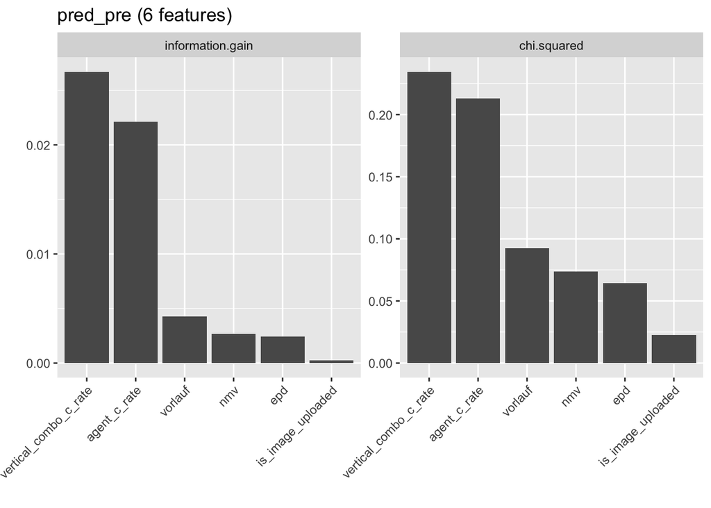

FSelector Feature importance on postbook cancellation

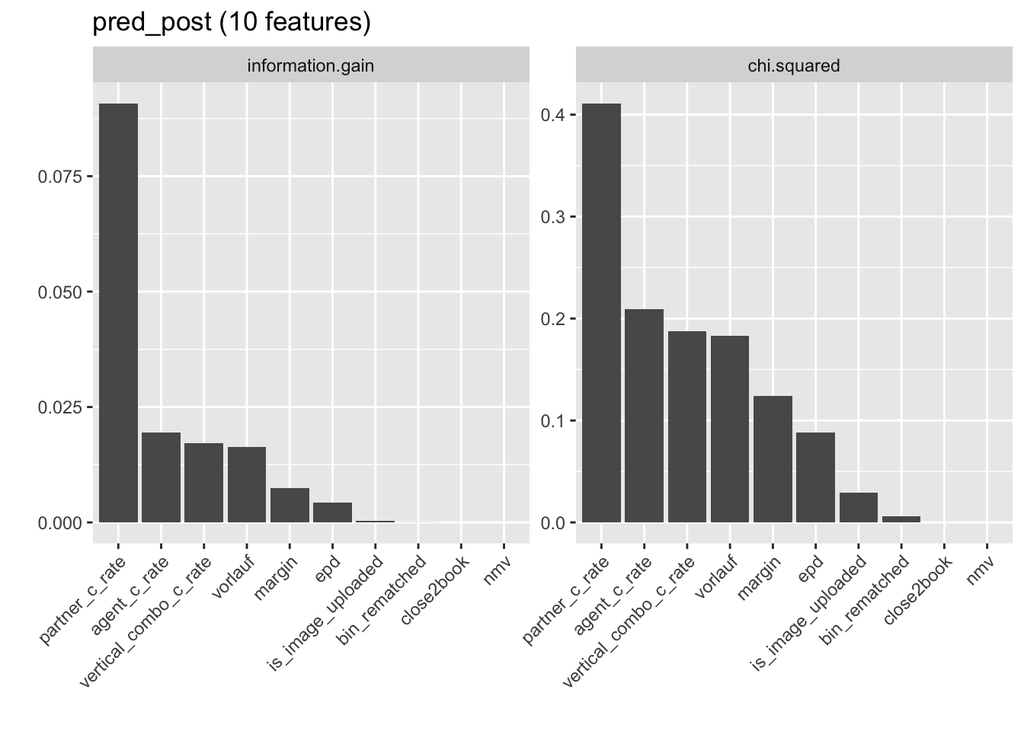

Logistic regression on prebook cancellation:

```
## auc.test.mean acc.test.mean
##     0.7210851     0.7938628
##
## Call:  stats::glm(formula = f, family = "binomial", data = getTaskData(.task,
##     .subset), weights = .weights, model = FALSE)
##
## Coefficients:
##           (Intercept)                vorlauf                    nmv
##               -1.4517                -0.0873                -0.2439
## vertical_combo_c_rate           agent_c_rate     is_image_uploaded1
##                0.5905                 0.4860                -0.1260
##                   epd
##               -0.1558
##
## Degrees of Freedom: 5898 Total (i.e. Null);  5892 Residual
## Null Deviance:       6117
## Residual Deviance: 5483  AIC: 5497
```

```
## Model for learner.id=classif.logreg; learner.class=classif.logreg
## Trained on: task.id = pred_pre; obs = 5899; features = 6
## Hyperparameters: model=FALSE
```

Logistic regression on postbook cancellation:

```
## auc.test.mean acc.test.mean
##     0.8260642     0.8323276
##
## Call:  stats::glm(formula = f, family = "binomial", data = getTaskData(.task,
##     .subset), weights = .weights, model = FALSE)
##
## Coefficients:
##           (Intercept)                vorlauf             close2book
##              -1.68510                0.45218                0.06807
##        bin_rematched1                    nmv                 margin
##              -0.17761                0.15332                0.32051
## vertical_combo_c_rate         partner_c_rate           agent_c_rate
##               0.44492                1.13309                0.51409
##    is_image_uploaded1                    epd
##               0.03093               -0.20004
##
## Degrees of Freedom: 4639 Total (i.e. Null);  4629 Residual
## Null Deviance:       4875
## Residual Deviance: 3595  AIC: 3617
```

```
## Model for learner.id=classif.logreg; learner.class=classif.logreg
## Trained on: task.id = pred_post; obs = 4640; features = 10
## Hyperparameters: model=FALSE
```

Decision Tree’s AUC & Accuracy on prebook dataset

```
## auc.test.mean acc.test.mean
##     0.6898613     0.7760675
```

Decision Tree’s AUC & Accuracy on postbook dataset

```
## auc.test.mean acc.test.mean
##     0.7646007     0.8099132
```

Feature Importance (prebook) in Decision Tree

```
## FeatureImportance:
## Task: pred_pre
## Interaction: FALSE
## Learner: classif.rpart
## Measure: mmce
## Contrast: function (x, y)  x - y
## Aggregation: function (x, ...)  UseMethod("mean")
## Replace: TRUE
## Number of Monte-Carlo iterations: 50
## Local: FALSE
##         vorlauf        nmv vertical_combo_c_rate agent_c_rate
## mmce 0.01899644 0.03356501            0.06193931   0.04520766
##      is_image_uploaded         epd
## mmce       0.003251399 0.001193423
```

Feature Importance (postbook) in Decision Tree

```
## FeatureImportance:
## Task: pred_post
## Interaction: FALSE
## Learner: classif.rpart
## Measure: mmce
## Contrast: function (x, y)  x - y
## Aggregation: function (x, ...)  UseMethod("mean")
## Replace: TRUE
## Number of Monte-Carlo iterations: 50
## Local: FALSE
##         vorlauf close2book bin_rematched         nmv     margin
## mmce 0.02999138 0.00299569             0 0.001146552 0.01596983
##      vertical_combo_c_rate partner_c_rate agent_c_rate is_image_uploaded
## mmce              0.014875     0.07697845   0.03331466                 0
##      epd
## mmce   0
```